# Bulk RNA-Seq and scRNA-seq WGCNA Analysis Supplementary

Scripts written by **Lisa Yeter Mesrop** accompanying the publication Single cell analysis reveals the molecular signaling and cellular composition of the regnerating Hydra Head Authors: Aide Macias-Muñoz, Lisa Y. Mesrop, Heidi Yahan Liang and Ali Mortazavi.

The scripts below perform the following:

- Read mapping of Bulk RNA-Seq Hydra Regeneration and Hypostome (Murad and Macias-Munoz et al., 2021) with Kallisto.
- Count normalization with DESeq2
- Gene network analysis with WGCNA
- GO enrichment with topGO
- Network Visualization

```r
#load libraries
library(WGCNA)
library(tidyverse)
library(edgeR)
library(matrixStats)
library(DESeq2)
library(dplyr)
library(data.table)
library(ggraph)
library(graphlayouts)
library(igraph)
library(topGO)
library(readxl)


#The following setting is important for WGCNA analysis, do not omit.
options(stringsAsFactors = FALSE);
enableWGCNAThreads()
allowWGCNAThreads(nThreads = 22)
```

[output not shown]

```
Allowing parallel execution with up to 39 working processes.
Allowing multi-threading with up to 22 threads.
```

## 1. Read in gene-level counts using Kallisto

Bulk RNA-seq fasta files were downloaded from NCBI and were mapped back to the reference using Kallisto on POD UCSB Cluster.

```r
#set working directory
setwd('/home/lmesrop/hydra_project/wgcna_bulk_hydra/Hydra_bulk_wgcna_111221/scHydra_project_github')
```

```r
#downloaded mapped counts to my working directory and checked to make sure the path is correct
all(file.exists(path)) #must say TRUE


#read in the gene names
merged <- read.delim("/Users/lisamesrop/Desktop/Hydra_single_cell/bulk_RNA_seq_analysis/merged.txt", header=FALSE)
merged_v2<- merged %>% separate( V1, into = c("cut"), sep=".t(.*)")


#rename the columns
names(merged_v2)[1] <- "target_id"
names(merged_v2)[2] <- "gene_name"

merged_v3 <- merged_v2[c("gene_name", "target_id")]

#retrieve the count matrix
Txi_gene <- tximport(path,
                     type = "kallisto",
                     tx2gene = merged_v3, #transcript-to-gene mapping file
                     txOut = FALSE) #FALSE - dont want transcript level output


myTPM <- Txi_gene$abundance #transcript per million measurement
mycounts <- Txi_gene$counts #raw number of reads mapped to that gene in that sample
colSums(myTPM)
colSums(mycounts)

#get quick stats
mycounts.stats <- transform(mycounts, SD=rowSds(mycounts), AVG=rowMeans(mycounts), MED=rowMedians(mycounts))
head(mycounts)

#make a ggplot from the quick stats
ggplot(mycounts.stats) + aes(x=SD, y=MED) + geom_point(shape=16, size=2)

#meta data needed for DESeq2 anlaysis

#need to add the sample names back to mycounts table
colnames(mycounts) <- c(sampleLabels)

#need to make a meta object
meta <- data.frame(row.names = colnames(mycounts))
sample_names <- c("Reg_RNA_0hr", "Reg_RNA_0hr", "Reg_RNA_2hr", "Reg_RNA_2hr", "Reg_RNA_4hr", "Reg_RNA_4hr", "Reg_RNA_6hr",
                  "Reg_RNA_6hr", "Reg_RNA_12hr", "Reg_RNA_12hr", "Reg_RNA_24hr", "Reg_RNA_24hr", "Reg_RNA_48hr", "Reg_RNA_48hr",
                  "Hypostome", "Hypostome")

meta$sample_names <- sample_names
meta$names <- rownames(meta)
rownames(meta) <- NULL
```

```r
#load("gene_level_hydra_workspace.RData")
```

## 2. Filter and normalize gene count matrix using DESeq2

```r
#rename mycounts to dds_count_table
dds_count_table <- mycounts
```

```r
#check the number of genes
nrow(dds_count_table); #33820
```

33820

```r
#filter the count table
dds_count_table_prefiltered <- dds_count_table[rowSums(counts(dds_count_table) >=10) >=2, ];
nrow(dds_count_table_prefiltered);
```

16971

```r
#Save genes of interest into an object. This list of genes will be used downstream to determine which modules have them.
My_genes_AB<-c("Sc4wPfr-789.g22423-neuroblast-differentiationassociated-AHNAK","MSTRG.22204-neuroblast-differentiationassociated-AHNAK",
               "Sc4wPfr-227.g25773-ANTA-HYDVU-ame:-Full=Antistasin-Short=ATS-ame:-Full=Blood-coagulation-factor-Xa-proclotting-enzyme-inhibitor-Flags:-Precursor",
               "Sc4wPfr-1357.1.g3222-Homeobox-ARX", "Sc4wPfr-654.g18227-aristalessrelated-homeobox-like",
               "Sc4wPfr-177.g9412-betacatenin-1","Sc4wPfr-547.1.g24952-brachyury-isoform-X2","Sc4wPfr-489.2.g16698-brachyury-isoform-X3",
               "Sc4wPfr-17.g15881-COUP-transcription-factor-2-isoform-X2","Sc4wPfr-134.g20117-dickkopf-Dlp2-precursor","Sc4wPfr-624.g29781-segment-polarity-dishevelled-homolog-DVL3like",
               "MSTRG.3248-ELAV-2","Sc4wPfr-1309.1.g9692-ELAV-3-isoform-X1","Sc4wPfr-1241.g21489-homeobox-extradenticle-isoform-X3",
               "Sc4wPfr-677.g23720-protooncogene-cFoslike-isoform-X1","Sc4wPfr-66.g19023-RNA-binding-fox1-homolog-3like-isoform-X2",
               "Sc4wPfr-381.1.g32304-Forkhead-box","Sc4wPfr-441.g7675-Forkhead-box-K1","Sc4wPfr-909.g33493-forkhead-box-Olike","Sc4wPfr-396.g3075-forkhead-box",
               "Sc4wPfr-802.g11765-homeobox-goosecoid",
               "Sc4wPfr-635.g14708-Hym355-preprohormone","Sc4wPfr-119.1.g1450-transcription-factor-junDlike",
               "Sc4wPfr-661.g19812-KS1-HYDVU-ame:-Full=KS1-ame:-Full=Headspecific-1-ame:-Full=Kopfspezifisches-1-Flags:-Precursor","MSTRG.21513-KS1-like",
               "Sc4wPfr-844.g33330-KVamide-preprohormone-type-2","Sc4wPfr-412.g24329-LWamide-neuropeptide-precursor","Sc4wPfr-305.g4616-homeobox-Meis1like-isoform-X2",
               "Sc4wPfr-259.g33627-myb-transcription-factor","Sc4wPfr-504.g10368-myb-D","Sc4wPfr-546.1.g5178-myb-X","Sc4wPfr-717.g8768-homeobox-Nkx",
               "MSTRG.8233-homeobox-OTX1like", "MSTRG.23836-homeobox-OTX2like","MSTRG.8274-homeobox-OTX2like",
               "MSTRG.21936-Pax", "Sc4wPfr-251.g2461-transcription-factor-PaxA", "Sc4wPfr-439.g20916-Paired-box-Pax","Sc4wPfr-691.g31399-eyegone-isoform",
               "Sc4wPfr-569.1.g4046-polRFamide-neuropeptides","Sc4wPfr-884.g31959-PPOD1-peroxidase","Sc4wPfr-597.2.g14333-piwi-1-isoform-X1",
               "Sc4wPfr-224.1.g33422-transcription-factor-Sp5","Sc4wPfr-351.g11299-transcription-factor-SOX12like","MSTRG.13573-transcription-factor-Sox3like",
               "Sc4wPfr-1384.g16120-transcription-factor-SOX30","Sc4wPfr-347.g19261-Transcription-factor-Sox14","Sc4wPfr-372.g28037-transcription-factor-SOX17",
               "Sc4wPfr-6.g19151-Transcription-factor-Sox","Sc4wPfr-362.g23666-Transcription-factor-Sox2","Sc4wPfr-804.g24094-protooncogene-Wnt1",
               "Sc4wPfr-399.g28064-protooncogene-Wnt3","Sc4wPfr-287.2.g28262-Wnt5a-isoform-X2","Sc4wPfr-1214.g29750-Wnt2b","Sc4wPfr-440.g6790-Wnt7b-isoform-X4",
               "Sc4wPfr-68.g2322-Wnt4","Sc4wPfr-224.1.g33373-Wnt2-isoform-X2","Sc4wPfr-243.g15582-secreted-signaling-factor-Wnt11","Sc4wPfr-275.3.g1992-Wnt4","Sc4wPfr-1061.g18842-wntless-homolog",
               "Sc4wPfr-861.g31120-vasa", "Sc4wPfr-6.g19151-sox-18", "Sc4wPfr-372.g28037-sox-17", "Sc4wPfr-1384.g16120-sox13-like", "Sc4wPfr-226.1.g26815-regulatory-gene")
```

```r
#remove the annotated names and have the transcript IDs match the transcript IDs in the count table
my_genes_df <- as.data.frame(My_genes_AB)
```

```r
head(my_genes_df)
```

A data.frame: 6 × 1

|  | My_genes_AB <chr> |
| --- | --- |
| 1 | Sc4wPfr-789.g22423-neuroblast-differentiationassociated-AHNAK |
| 2 | MSTRG.22204-neuroblast-differentiationassociated-AHNAK |
| 3 | Sc4wPfr-227.g25773-ANTA-HYDVU-ame:-Full=Antistasin-Short=ATS-ame:-Full=Blood-coagulation-factor-Xa-proclotting-enzyme-inhibitor-Flags:-Precursor |
| 4 | Sc4wPfr-1357.1.g3222-Homeobox-ARX |
| 5 | Sc4wPfr-654.g18227-aristalessrelated-homeobox-like |
| 6 | Sc4wPfr-177.g9412-betacatenin-1 |

```r
my_genes_df_split <- my_genes_df %>% separate(My_genes_AB, c("col1", "col2"), "-")
```

```r
head(my_genes_df_split)
```

A data.frame: 6 × 2

|  | col1 <chr> | col2 <chr> |
| --- | --- | --- |
| 1 | Sc4wPfr | 789.g22423 |
| 2 | MSTRG.22204 | neuroblast |
| 3 | Sc4wPfr | 227.g25773 |
| 4 | Sc4wPfr | 1357.1.g3222 |
| 5 | Sc4wPfr | 654.g18227 |
| 6 | Sc4wPfr | 177.g9412 |

```r
my_genes_df_split$combined <- str_c(my_genes_df_split$col1, "_", my_genes_df_split$col2)
```

```r
head(my_genes_df_split)
```

A data.frame: 6 × 3

|  | col1 <chr> | col2 <chr> | combined <chr> |
| --- | --- | --- | --- |
| 1 | Sc4wPfr | 789.g22423 | Sc4wPfr_789.g22423 |
| 2 | MSTRG.22204 | neuroblast | MSTRG.22204_neuroblast |
| 3 | Sc4wPfr | 227.g25773 | Sc4wPfr_227.g25773 |
| 4 | Sc4wPfr | 1357.1.g3222 | Sc4wPfr_1357.1.g3222 |
| 5 | Sc4wPfr | 654.g18227 | Sc4wPfr_654.g18227 |
| 6 | Sc4wPfr | 177.g9412 | Sc4wPfr_177.g9412 |

```r
my_genes_df_v1 <- subset(my_genes_df_split, select = -c(col1, col2))
```

```r
head(my_genes_df_v1)
```

A data.frame: 6 × 1

|  | combined <chr> |
| --- | --- |
| 1 | Sc4wPfr_789.g22423 |
| 2 | MSTRG.22204_neuroblast |
| 3 | Sc4wPfr_227.g25773 |
| 4 | Sc4wPfr_1357.1.g3222 |
| 5 | Sc4wPfr_654.g18227 |
| 6 | Sc4wPfr_177.g9412 |

```r
check <- as.data.frame(rownames(dds_count_table_prefiltered))
check$names <- check$'rownames(dds_count_table_prefiltered)'
my_genes_df_v1$combined[!my_genes_df_v1$combined %in% check$names]
```

1. 'MSTRG.22204_neuroblast'

2. 'MSTRG.3248_ELAV'

3. 'MSTRG.21513_KS1'

4. 'MSTRG.8233_homeobox'

5. 'MSTRG.23836_homeobox'

6. 'MSTRG.8274_homeobox'

7. 'MSTRG.21936_Pax'

8. 'MSTRG.13573_transcription'

```r
#Perform the DESeq2 normalization on the prefiltered count table, required before WGCNA analysis
dds_prefiltered <- DESeq(dds_count_table_prefiltered, betaPrior = FALSE, parallel = TRUE)
# Perform a variance-stabilizing transformation
vsd_prefiltered <- getVarianceStabilizedData(dds_prefiltered)


# transpose the matrix
datExpr <- t(vsd_prefiltered)
## check rows/cols
nrow(datExpr)
ncol(datExpr)
```

```
using 'avgTxLength' from assays(dds), correcting for library size
```

16

16971

## 3. Perform WGCNA

```r
# Choose a set of soft-thresholding powers
powers = c(c(1:10), seq(from = 12, to=20, by=2))
# Call the network topology analysis function
sft = pickSoftThreshold(datExpr, powerVector = powers, verbose = 5)
```

```
pickSoftThreshold: will use block size 2636.
 pickSoftThreshold: calculating connectivity for given powers...
   ..working on genes 1 through 2636 of 16971
   ..working on genes 2637 through 5272 of 16971
   ..working on genes 5273 through 7908 of 16971
   ..working on genes 7909 through 10544 of 16971
   ..working on genes 10545 through 13180 of 16971
   ..working on genes 13181 through 15816 of 16971
   ..working on genes 15817 through 16971 of 16971
   Power SFT.R.sq  slope truncated.R.sq mean.k. median.k. max.k.
1      1   0.3770  1.510          0.856  5650.0   5640.00   8500
2      2   0.0404 -0.185          0.759  2720.0   2580.00   5480
3      3   0.5050 -0.705          0.820  1550.0   1360.00   3920
4      4   0.6690 -0.951          0.850   976.0    784.00   2980
5      5   0.7170 -1.100          0.856   657.0    482.00   2340
6      6   0.7410 -1.200          0.866   465.0    310.00   1900
7      7   0.7630 -1.260          0.882   341.0    205.00   1570
8      8   0.7730 -1.310          0.889   257.0    141.00   1310
9      9   0.7890 -1.330          0.903   199.0     98.80   1120
10    10   0.7980 -1.360          0.911   157.0     70.60    959
11    12   0.8140 -1.400          0.926   102.0     38.20    726
12    14   0.8230 -1.420          0.933    69.8     22.00    565
13    16   0.8260 -1.440          0.939    49.6     13.20    451
14    18   0.8300 -1.460          0.942    36.3      8.22    366
15    20   0.8360 -1.470          0.946    27.3      5.23    301
```

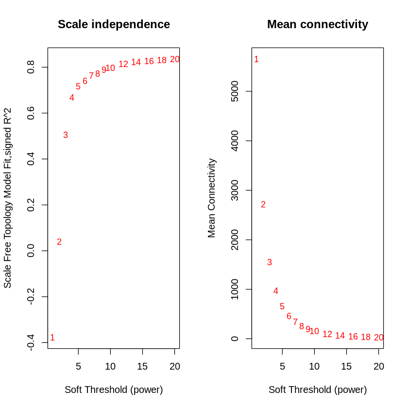

```r
# Plot the results:
#sizeGrWindow(9, 5)
par(mfrow = c(1,2));
cex1 = 0.9;
# Scale-free topology fit index as a function of the soft-thresholding power
plot(sft$fitIndices[,1], -sign(sft$fitIndices[,3])*sft$fitIndices[,2],
     xlab="Soft Threshold (power)",ylab="Scale Free Topology Model Fit,signed R^2",type="n",
     main = paste("Scale independence"));
text(sft$fitIndices[,1], -sign(sft$fitIndices[,3])*sft$fitIndices[,2],
     labels=powers,cex=cex1,col="red");
# this line corresponds to using an R^2 cut-off of h
abline(h=0.90,col="red")
# Mean connectivity as a function of the soft-thresholding power
plot(sft$fitIndices[,1], sft$fitIndices[,5],
     xlab="Soft Threshold (power)",ylab="Mean Connectivity", type="n",
     main = paste("Mean connectivity"))
text(sft$fitIndices[,1], sft$fitIndices[,5], labels=powers, cex=cex1,col="red")
```

```r
# Co-expression similarity and adjacency using assigned softpower
softPower=18
adjacency = adjacency(datExpr, power = softPower)
#save(softPower, adjacency, file = "adjacency_signed_power18_prefiltered_10_112321.RData")
```

```r
# Topological Overlap Matrix (TOM)
# Turn adjacency into topological overlap
TOM = TOMsimilarity(adjacency, TOMType = "signed", verbose = 5);
dissTOM = 1-TOM;
#save(TOM, dissTOM, file = "TOMsimilarity_signed_power18_prefiltered_10_112321.RData")
```

```
..connectivity..
..matrix multiplication (system BLAS)..
..normalization..
..done.
```

```r
## generate a clustered gene tree
geneTree <- hclust(as.dist(dissTOM), method="average")
```

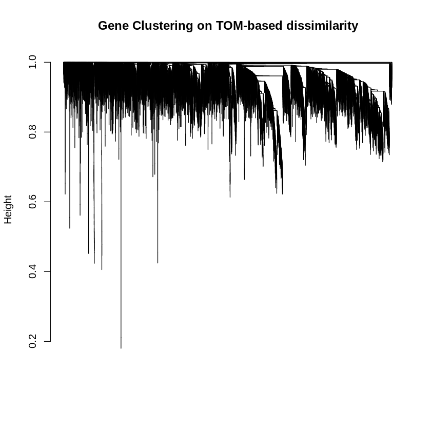

```r
plot(geneTree, xlab = "", sub = "", main = "Gene Clustering on TOM-based dissimilarity",
     labels = FALSE, hang = 0.04)
```

```r
# This sets the minimum number of genes to cluster into a module
minModuleSize <- 30
# Generate modules and assign them colors. Module identification using dynamic tree cut.
dynamicMods <- cutreeDynamic(dendro = geneTree, distM = dissTOM ,
                             deepSplit = 3, pamRespectsDendro = FALSE,
                             minClusterSize = minModuleSize)
```

```
 ..cutHeight not given, setting it to 0.998  ===>  99% of the (truncated) height range in dendro.
 ..done.
```

```r
table(dynamicMods)

# Convert numeric lables into colors
dynamicColors <- labels2colors(dynamicMods)
table(dynamicColors)
```

```
dynamicMods
   0    1    2    3    4    5    6    7    8    9   10   11   12   13   14   15
1835  996  681  589  491  399  389  347  346  329  325  271  265  262  248  244
  16   17   18   19   20   21   22   23   24   25   26   27   28   29   30   31
 230  226  220  215  212  198  187  186  175  156  154  153  150  148  148  148
  32   33   34   35   36   37   38   39   40   41   42   43   44   45   46   47
 143  140  139  137  135  131  130  123  122  122  122  117  116  114  110  109
  48   49   50   51   52   53   54   55   56   57   58   59   60   61   62   63
 105  105  104  101   99   98   95   94   93   93   88   88   86   85   83   82
  64   65   66   67   68   69   70   71   72   73   74   75   76   77   78   79
  79   78   76   76   76   76   76   72   72   71   70   69   69   69   68   67
  80   81   82   83   84   85   86   87   88   89   90   91   92   93   94   95
  67   66   66   64   63   63   63   61   61   60   58   58   57   57   55   54
  96   97   98   99  100  101  102  103  104
  50   50   50   47   45   43   41   40   36
```

```
dynamicColors
  antiquewhite2   antiquewhite4         bisque4           black            blue
             58              85             109             347             681
          blue2      blueviolet           brown          brown2          brown4
             69              36             589              69             110
          coral          coral1          coral2          coral3            cyan
             60              86              83              58             248
      darkgreen        darkgrey     darkmagenta  darkolivegreen darkolivegreen2
            187             175             139             140              40
darkolivegreen4      darkorange     darkorange2         darkred   darkseagreen3
             70             154             114             198              61
  darkseagreen4   darkslateblue   darkturquoise      darkviolet      firebrick3
             88             105             186              69              41
     firebrick4     floralwhite           green     greenyellow            grey
             71             116             399             271            1835
         grey60        honeydew       honeydew1      indianred3      indianred4
            226              61              88              43              72
          ivory  lavenderblush2  lavenderblush3      lightblue4      lightcoral
            117              63              93              45              72
      lightcyan      lightcyan1      lightgreen      lightpink3      lightpink4
            230             122             220              63              93
 lightslateblue  lightsteelblue lightsteelblue1     lightyellow         magenta
             47              76             122             215             329
       magenta4          maroon    mediumorchid   mediumpurple1   mediumpurple2
             63              94              82              50              76
  mediumpurple3   mediumpurple4    midnightblue    navajowhite1    navajowhite2
            122              57             244              64              95
         orange      orangered1      orangered3      orangered4   paleturquoise
            156              50              76             123             148
 palevioletred2  palevioletred3            pink           pink4            plum
             66              98             346              50              76
          plum1           plum2           plum3          purple             red
            130             105              68             325             389
      royalblue     saddlebrown          salmon         salmon2         salmon4
            212             148             262              66              99
        sienna3         sienna4         skyblue        skyblue1        skyblue2
            137              54             150              76              79
       skyblue3        skyblue4       steelblue             tan         thistle
            131              57             148             265              67
       thistle1        thistle2        thistle3       turquoise          violet
            101             104              67             996             143
          white          yellow         yellow3         yellow4     yellowgreen
            153             491              55              78             135
```

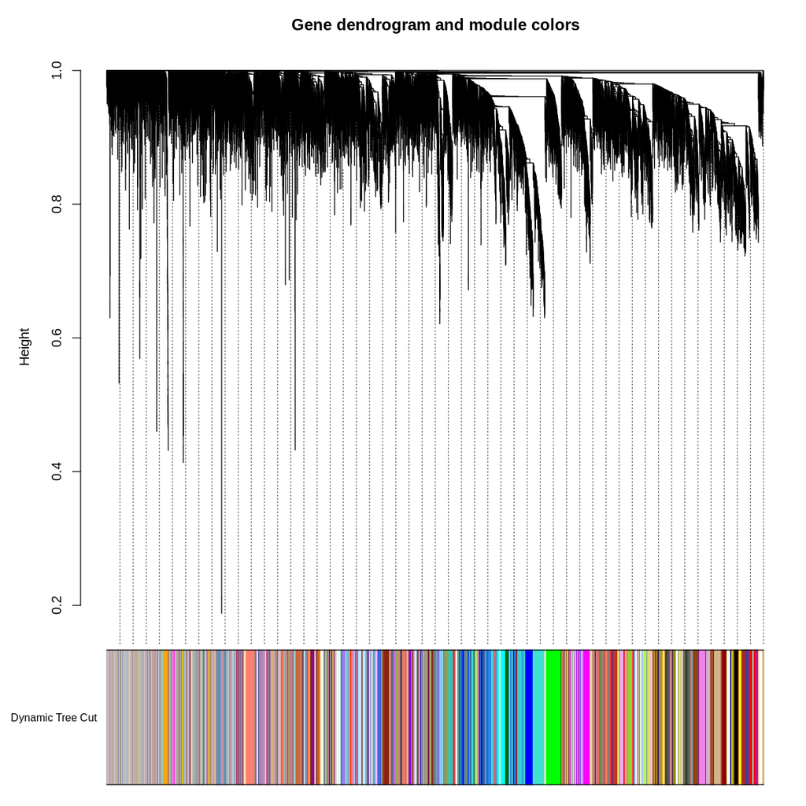

```r
# Plot the dendrogram and colors underneath

plotDendroAndColors(geneTree, dynamicColors, "Dynamic Tree Cut",
                    dendroLabels = FALSE, hang = 0.03,
                    addGuide = TRUE, guideHang = 0.05,
                    main = "Gene dendrogram and module colors")
```

## 4. Merge modules based on their module eigengenes

```r
# Merge modules whose expression profiles are very similar
# Calculate eigengenes
MEList <- moduleEigengenes(datExpr, colors = dynamicColors)
MEs <- MEList$eigengenes
# Calculate dissimilarity of module eigengenes
MEDiss <- 1-bicor(MEs)
# Cluster module eigengenes
METree <- hclust(as.dist(MEDiss), method= "average")
MEDissThres = 0.2 ; #0.2 means a correlation of 0.8
```

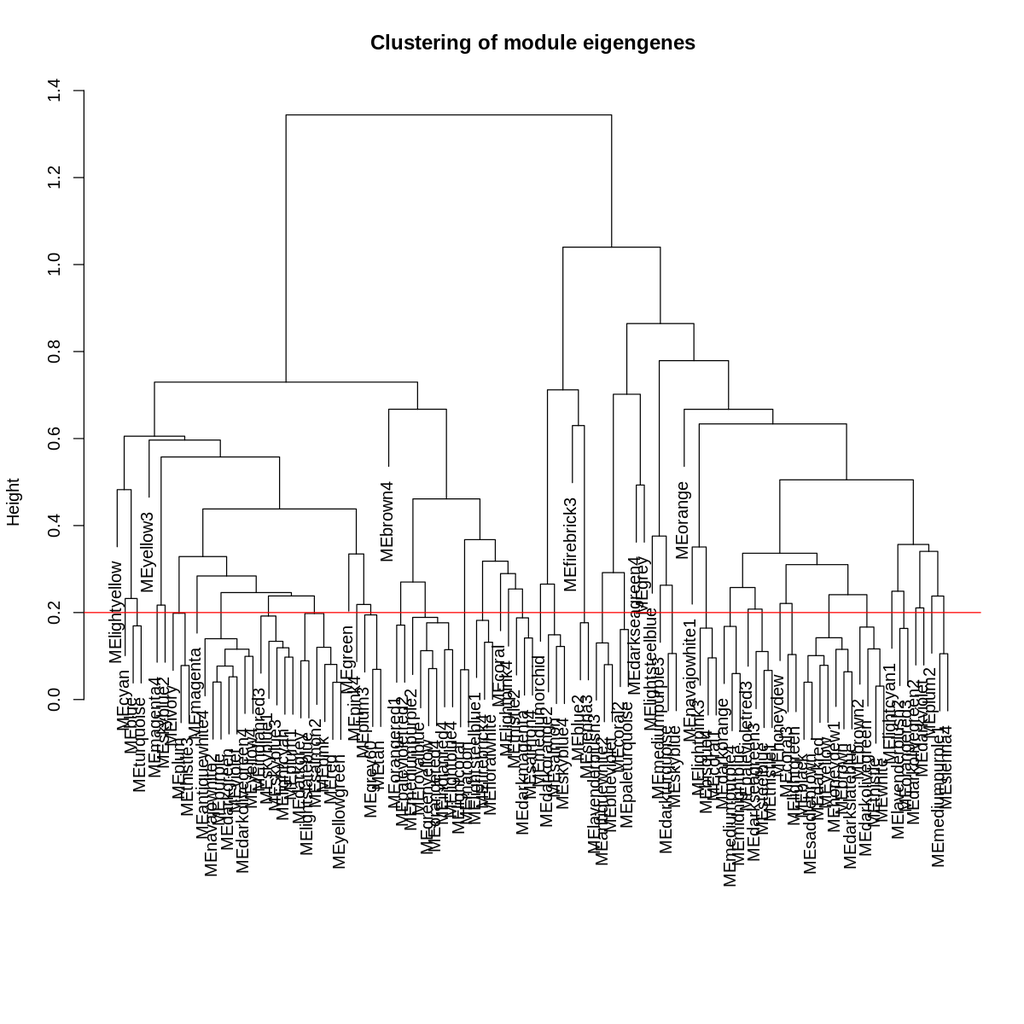

```r
# Plot the result
#sizeGrWindow(7, 6)
plot(METree, main = "Clustering of module eigengenes",
     xlab = "", sub = "")

# Plot the cut line into the dendrogram
abline(h=MEDissThres, col = "red")
```

```r
# Call an automatic merging function
merge = mergeCloseModules(datExpr, dynamicColors, cutHeight = MEDissThres, verbose = 3)
# The merged module colors
mergedColors = merge$colors;
# Eigengenes of the new merged modules:
mergedMEs = merge$newMEs;
```

```
 mergeCloseModules: Merging modules whose distance is less than 0.2
   multiSetMEs: Calculating module MEs.
     Working on set 1 ...
     moduleEigengenes: Calculating 105 module eigengenes in given set.
   multiSetMEs: Calculating module MEs.
     Working on set 1 ...
     moduleEigengenes: Calculating 45 module eigengenes in given set.
   multiSetMEs: Calculating module MEs.
     Working on set 1 ...
     moduleEigengenes: Calculating 35 module eigengenes in given set.
   multiSetMEs: Calculating module MEs.
     Working on set 1 ...
     moduleEigengenes: Calculating 32 module eigengenes in given set.
   multiSetMEs: Calculating module MEs.
     Working on set 1 ...
     moduleEigengenes: Calculating 31 module eigengenes in given set.
   Calculating new MEs...
   multiSetMEs: Calculating module MEs.
     Working on set 1 ...
     moduleEigengenes: Calculating 31 module eigengenes in given set.
```

```r
plotDendroAndColors(geneTree, cbind(dynamicColors, mergedColors),
                    c("Dynamic Tree Cut", "Merged dynamic"),
                    dendroLabels = FALSE, hang = 0.03,
                    addGuide = TRUE, guideHang = 0.05)
```

[output not shown]

```r
# Rename to moduleColors
moduleColors = mergedColors
# Construct numerical labels corresponding to the colors
colorOrder = c("grey", standardColors(50));
moduleLabels = match(moduleColors, colorOrder)-1;
MEs = mergedMEs;
```

```r
MEs
```

A data.frame: 16 × 31

| MEyellow3 <dbl> | MElightcyan1 <dbl> | MElightpink3 <dbl> | MEblueviolet <dbl> | MEdarkviolet <dbl> | MEdarkolivegreen2 <dbl> | MEsalmon <dbl> | MEdarkseagreen3 <dbl> | MElightsteelblue <dbl> | MEorange <dbl> | ⋯ | MEcoral2 <dbl> | MEindianred3 <dbl> | MEmagenta4 <dbl> | MEmaroon <dbl> | MEivory <dbl> | MElightcyan <dbl> | MEmediumpurple2 <dbl> | MEcoral <dbl> | MEfirebrick4 <dbl> | MEgrey <dbl> |
| --- | --- | --- | --- | --- | --- | --- | --- | --- | --- | --- | --- | --- | --- | --- | --- | --- | --- | --- | --- | --- |
| -0.09686345 | 0.15530522 | 0.12722643 | 0.05473053 | -0.07846640 | 0.05272496 | 0.172501658 | 0.11401628 | 0.16309234 | -0.10345158 | ⋯ | -0.31735819 | -0.37948434 | -0.31073227 | 0.009185176 | -0.17329005 | -0.203123291 | -0.04591278 | 0.02737880 | -0.10646317 | -0.1217922199 |
| -0.14850585 | 0.14402303 | 0.13127425 | 0.13301247 | -0.01384657 | 0.06477776 | 0.153843593 | 0.17490793 | 0.18730205 | -0.11277543 | ⋯ | -0.28449384 | -0.51348600 | -0.29670900 | 0.026098837 | -0.05777045 | -0.231894639 | -0.19483000 | 0.06014672 | -0.06177930 | -0.0497683748 |
| -0.13488244 | -0.03957065 | -0.02915445 | 0.14300499 | 0.06989972 | 0.04218765 | 0.217792489 | 0.24251436 | 0.38738280 | -0.06482562 | ⋯ | -0.08124515 | -0.24111078 | -0.20539527 | 0.117139952 | -0.01946197 | -0.182040917 | -0.21835884 | 0.07813281 | -0.01417545 | -0.0028858298 |
| -0.20644226 | 0.54712681 | 0.62947752 | 0.42950631 | 0.32964201 | 0.02312833 | -0.392991784 | 0.04445653 | -0.32994339 | -0.03686350 | ⋯ | -0.02564681 | -0.21406359 | 0.02353983 | -0.713857229 | -0.26341564 | -0.402994175 | -0.28868920 | -0.16932673 | -0.15801020 | 0.6401229687 |
| 0.53528777 | 0.21882842 | 0.02482505 | 0.46331870 | 0.51423578 | -0.08089020 | -0.250696054 | 0.17269725 | -0.04943657 | -0.12146026 | ⋯ | 0.15017440 | 0.07631291 | 0.03800188 | -0.373651722 | -0.31332961 | -0.190786032 | 0.17140652 | -0.16974449 | -0.12124359 | -0.5851687500 |
| -0.12650711 | -0.10439680 | -0.09074287 | 0.14309849 | 0.19481218 | 0.03603343 | 0.296741366 | 0.27749711 | 0.40422284 | 0.73690494 | ⋯ | 0.06782763 | -0.07559550 | -0.20504255 | 0.034882346 | -0.08367996 | -0.159321282 | -0.04577147 | 0.30087835 | -0.04400738 | -0.3201308969 |
| 0.70511961 | 0.22261990 | 0.27901425 | 0.22531648 | 0.14430339 | -0.11787282 | 0.001169864 | 0.20318129 | 0.14032368 | -0.15523251 | ⋯ | 0.08187158 | -0.03152286 | 0.07565942 | -0.071461530 | -0.10105292 | -0.189125675 | -0.18319787 | -0.09035723 | -0.01975383 | 0.1829991025 |
| -0.08077789 | 0.14800337 | 0.20444240 | 0.18988600 | 0.14919596 | -0.06116841 | -0.043984987 | 0.13154710 | 0.03337100 | -0.08294907 | ⋯ | 0.09735201 | 0.04570505 | 0.10879992 | -0.180065643 | -0.18571276 | -0.168086841 | -0.24306618 | -0.09106069 | -0.08553368 | 0.0402482368 |
| -0.05992762 | -0.28372755 | -0.04510630 | -0.17594428 | -0.36769589 | -0.19239942 | -0.227645721 | -0.50935690 | -0.23797027 | -0.17026438 | ⋯ | 0.44403972 | 0.29473990 | 0.43804772 | 0.212709607 | 0.50574784 | 0.453320043 | 0.11370843 | 0.08004825 | 0.48390773 | 0.2372437912 |
| -0.12920832 | -0.35150023 | -0.24021847 | -0.12050896 | -0.05168354 | -0.21086354 | -0.214945608 | -0.31767293 | -0.12964200 | 0.39377510 | ⋯ | 0.61752978 | 0.49311172 | 0.63471123 | 0.180626918 | 0.46772232 | 0.436389347 | 0.18886106 | 0.07686920 | 0.28193556 | 0.0612989691 |
| -0.14338458 | -0.35154505 | -0.24772125 | -0.13213613 | -0.34236049 | -0.11134388 | 0.006987652 | -0.09413845 | 0.17663530 | -0.15564691 | ⋯ | 0.04012196 | -0.02203210 | -0.15532502 | 0.302496145 | 0.25994967 | 0.220636478 | 0.15600228 | 0.31862914 | 0.32125386 | 0.0260813161 |
| -0.07346367 | -0.43322282 | -0.27339440 | -0.18277191 | -0.42335552 | -0.09706996 | 0.049029848 | -0.08579115 | 0.21146345 | 0.33999052 | ⋯ | 0.05192000 | -0.08935219 | -0.23435925 | 0.352551620 | 0.38735791 | 0.224349244 | 0.35371533 | 0.47740339 | 0.31198442 | -0.0261058261 |
| -0.14788675 | -0.01721597 | 0.06371217 | -0.25535665 | -0.17896499 | -0.24498421 | -0.283074492 | -0.39821500 | -0.41407591 | -0.07563165 | ⋯ | -0.13930572 | 0.11712312 | 0.14319930 | 0.008934510 | -0.13199555 | 0.231117387 | 0.32549040 | 0.03779342 | 0.05627086 | -0.0569519234 |
| 0.17594909 | 0.03522270 | 0.13425065 | -0.21732965 | -0.19369269 | -0.29605363 | -0.292039422 | -0.34465662 | -0.40241831 | -0.12692245 | ⋯ | -0.21688507 | 0.05222635 | 0.08336051 | 0.010738557 | -0.17064080 | 0.185818577 | 0.48110245 | 0.03735260 | 0.06392240 | -0.1306501387 |
| -0.04052720 | 0.03197344 | -0.33041333 | -0.34007618 | 0.12749936 | 0.56779357 | 0.397019709 | 0.17733209 | -0.06148711 | -0.10455483 | ⋯ | -0.22812399 | 0.24190621 | -0.08987609 | 0.051687447 | -0.08291066 | 0.002576888 | -0.22766234 | -0.43228782 | -0.42787884 | -0.0003333876 |
| -0.02797932 | 0.07807618 | -0.33747166 | -0.35775023 | 0.12047770 | 0.62600035 | 0.410291890 | 0.21168111 | -0.07881989 | -0.16009236 | ⋯ | -0.25777830 | 0.24552212 | -0.04788034 | 0.031985009 | -0.03751736 | -0.026835113 | -0.34279779 | -0.54185571 | -0.48042939 | 0.1057929628 |

### 4.1 Pull out the gene ids from each module

Here, I saved all the modules and thier corresponding genes to module_* and text files. Next, I determined which modules contain the wnt3 gene (Sc4wPfr_399.g28064) and the Jun and Fos genes (Sc4wPfr_119.1.g1450 and Sc4wPfr_677.g23720).

```r
#recheck modules after modules were merged
table(moduleColors)

#determine which module has wnt3 gene
which(colnames(datExpr) == "Sc4wPfr_399.g28064")
moduleColors[[9753]] ;#dark green 1507
```

```
moduleColors
          blue2      blueviolet           coral          coral2       darkgreen
           3420            3415              60             446            1507
darkolivegreen2      darkorange   darkseagreen3   darkseagreen4      darkviolet
            154             340             305              88             173
     firebrick3      firebrick4            grey        honeydew      indianred3
             41             724            1835              61             122
          ivory       lightcyan      lightcyan1      lightpink3  lightslateblue
            282            1687             261             258             487
 lightsteelblue        magenta4          maroon   mediumpurple2   mediumpurple3
             76              63              94              76             272
   navajowhite1          orange           pink4          salmon         sienna3
             64             156              50             262             137
        yellow3
             55
```

9753

'darkgreen'

```r
#save the colnames of datExpr dataframe as SubGeneNames
SubGeneNames = colnames(datExpr)
#just pull out the gene names for the darkgreen module
wnt3_darkgreen_module=as.data.frame(SubGeneNames[which(moduleColors=="darkgreen")])
names(wnt3_darkgreen_module)[1] <- "Gene_ID"
#grab the annotated GO terms for each gene from the object GeneGO_table_4 (steps from below)
wnt3_darkgreen_module_annot <- setDT(GeneGO_table_4, key = 'Gene_ID')[J(wnt3_darkgreen_module)]
#write.csv(wnt3_darkgreen_module_annot, file = "wnt3_darkgreen_module_annot_112421.csv")
```

```r
# Jun and Fos Transript IDs are both found in the same module coral2
#Sc4wPfr_119.1.g1450 - Jun
#Sc4wPfr_677.g23720 - Fos

which(colnames(datExpr) == "Sc4wPfr_119.1.g1450")
moduleColors[[1539]]

which(colnames(datExpr) == "Sc4wPfr_677.g23720")
moduleColors[[13861]]
```

1539

'coral2'

13861

'coral2'

```r
#coral2
fos_jun_coral2_module=as.data.frame(SubGeneNames[which(moduleColors=="coral2")])
names(fos_jun_coral2_module)[1] <- "Gene_ID"
fos_jun_coral2_module <- setDT(GeneGO_table_4, key = 'Gene_ID')[J(fos_jun_coral2_module)]
write.csv(fos_jun_coral2_module, file = "fos_jun_coral2_module_annot.csv")
```

```r
#save all the modules and thier corresponding genes as text files.
SubGeneNames = colnames(datExpr)
for (color in moduleColors){
  module=SubGeneNames[which(moduleColors==color)]
  module_name = which(moduleColors==color )
  write.table(module, module_name, paste("ALL_module_",color, ".csv",sep=""), sep="\t", row.names=FALSE, col.names=FALSE,quote=FALSE)
}
```

### 4.2 Determine the network connectivity

```r
ADJ1=abs(cor(datExpr,use="p"))^18
Alldegrees1=intramodularConnectivity(ADJ1, moduleColors)
head(Alldegrees1)
```

A data.frame: 6 × 4

|  | kTotal <dbl> | kWithin <dbl> | kOut <dbl> | kDiff <dbl> |
| --- | --- | --- | --- | --- |
| Sc4wPfr_1.g5776 | 1.7011187 | 0.3925020 | 1.3086167 | -0.9161148 |
| Sc4wPfr_1.g5779 | 0.7406525 | 0.2677687 | 0.4728838 | -0.2051150 |
| Sc4wPfr_1.g5780 | 0.5294099 | 0.1607676 | 0.3686423 | -0.2078747 |
| Sc4wPfr_1.g5781 | 29.7004980 | 2.8531368 | 26.8473611 | -23.9942243 |
| Sc4wPfr_1.g5782 | 54.0871454 | 16.5175919 | 37.5695535 | -21.0519616 |
| Sc4wPfr_1.g5784 | 42.2301735 | 7.9833779 | 34.2467956 | -26.2634177 |

```r
datME=moduleEigengenes(datExpr, moduleColors)$eigengenes
signif(cor(datME, use="p"), 2)
```

A matrix: 31 × 31 of type dbl

|  | MEblue2 | MEblueviolet | MEcoral | MEcoral2 | MEdarkgreen | MEdarkolivegreen2 | MEdarkorange | MEdarkseagreen3 | MEdarkseagreen4 | MEdarkviolet | ⋯ | MEmagenta4 | MEmaroon | MEmediumpurple2 | MEmediumpurple3 | MEnavajowhite1 | MEorange | MEpink4 | MEsalmon | MEsienna3 | MEyellow3 |
| --- | --- | --- | --- | --- | --- | --- | --- | --- | --- | --- | --- | --- | --- | --- | --- | --- | --- | --- | --- | --- | --- |
| MEblue2 | 1.0000 | -0.780 | -0.580 | -0.42000 | 0.770 | 0.640 | -0.6300 | -0.047 | -0.7600 | -0.0920 | ⋯ | -0.0046 | 0.250 | -0.035 | -0.61000 | -0.4000 | -0.2200 | 0.720 | 0.43000 | 0.6700 | -0.090 |
| MEblueviolet | -0.7800 | 1.000 | 0.045 | 0.12000 | -0.890 | -0.240 | 0.6200 | 0.470 | 0.3500 | 0.6700 | ⋯ | -0.1500 | -0.700 | -0.310 | 0.31000 | 0.1300 | 0.0330 | -0.670 | -0.28000 | -0.2400 | 0.320 |
| MEcoral | -0.5800 | 0.045 | 1.000 | 0.30000 | -0.140 | -0.670 | 0.4900 | -0.310 | 0.5200 | -0.5900 | ⋯ | -0.1400 | 0.490 | 0.570 | 0.73000 | 0.2800 | 0.5100 | -0.130 | -0.19000 | -0.6300 | -0.230 |
| MEcoral2 | -0.4200 | 0.120 | 0.300 | 1.00000 | 0.021 | -0.480 | -0.0890 | -0.430 | 0.6500 | -0.0930 | ⋯ | 0.7700 | 0.130 | 0.260 | 0.12000 | 0.1100 | 0.3600 | -0.510 | -0.45000 | -0.7300 | 0.094 |
| MEdarkgreen | 0.7700 | -0.890 | -0.140 | 0.02100 | 1.000 | 0.058 | -0.7600 | -0.630 | -0.2800 | -0.5100 | ⋯ | 0.3900 | 0.490 | 0.520 | -0.50000 | -0.0620 | -0.0950 | 0.680 | -0.05100 | 0.3500 | -0.120 |
| MEdarkolivegreen2 | 0.6400 | -0.240 | -0.670 | -0.48000 | 0.058 | 1.000 | -0.1100 | 0.610 | -0.7700 | 0.3500 | ⋯ | -0.3900 | -0.061 | -0.690 | -0.25000 | -0.6700 | -0.1300 | 0.180 | 0.77000 | 0.3900 | -0.150 |
| MEdarkorange | -0.6300 | 0.620 | 0.490 | -0.08900 | -0.760 | -0.110 | 1.0000 | 0.520 | 0.1600 | 0.2700 | ⋯ | -0.5500 | -0.190 | -0.200 | 0.73000 | -0.0680 | 0.5400 | -0.430 | 0.18000 | -0.4000 | -0.250 |
| MEdarkseagreen3 | -0.0470 | 0.470 | -0.310 | -0.43000 | -0.630 | 0.610 | 0.5200 | 1.000 | -0.5500 | 0.6700 | ⋯ | -0.6600 | -0.310 | -0.730 | 0.15000 | -0.5800 | 0.0610 | -0.170 | 0.67000 | 0.1400 | 0.190 |
| MEdarkseagreen4 | -0.7600 | 0.350 | 0.520 | 0.65000 | -0.280 | -0.770 | 0.1600 | -0.550 | 1.0000 | -0.2700 | ⋯ | 0.4800 | -0.092 | 0.290 | 0.39000 | 0.7000 | 0.1100 | -0.600 | -0.72000 | -0.6700 | -0.120 |
| MEdarkviolet | -0.0920 | 0.670 | -0.590 | -0.09300 | -0.510 | 0.350 | 0.2700 | 0.670 | -0.2700 | 1.0000 | ⋯ | -0.0720 | -0.780 | -0.560 | -0.22000 | -0.3100 | -0.0036 | -0.330 | 0.07100 | 0.2500 | 0.370 |
| MEfirebrick3 | 0.6500 | -0.670 | -0.400 | -0.38000 | 0.420 | 0.580 | -0.5100 | -0.021 | -0.4000 | -0.3500 | ⋯ | -0.0890 | 0.300 | -0.340 | -0.33000 | -0.0760 | -0.3600 | 0.270 | 0.44000 | 0.2700 | -0.270 |
| MEfirebrick4 | -0.5100 | -0.097 | 0.800 | 0.64000 | 0.120 | -0.790 | -0.0037 | -0.700 | 0.7700 | -0.7000 | ⋯ | 0.3900 | 0.490 | 0.650 | 0.43000 | 0.4500 | 0.2100 | -0.180 | -0.50000 | -0.6800 | -0.110 |
| MEgrey | -0.0780 | -0.049 | -0.180 | 0.09800 | -0.077 | 0.077 | -0.2000 | -0.190 | 0.3600 | -0.1500 | ⋯ | 0.2500 | -0.210 | -0.380 | -0.08500 | 0.5200 | -0.2300 | -0.530 | -0.20000 | -0.2200 | -0.300 |
| MEhoneydew | -0.5000 | 0.690 | 0.300 | -0.01900 | -0.590 | -0.210 | 0.7500 | 0.480 | -0.0075 | 0.5300 | ⋯ | -0.3700 | -0.330 | 0.047 | 0.41000 | -0.1800 | 0.4400 | -0.190 | -0.00029 | -0.0790 | 0.260 |
| MEindianred3 | 0.4600 | -0.490 | -0.280 | 0.58000 | 0.700 | 0.021 | -0.6700 | -0.480 | -0.0290 | -0.0830 | ⋯ | 0.7900 | 0.210 | 0.260 | -0.51000 | -0.1400 | 0.0940 | 0.130 | -0.19000 | -0.0085 | 0.120 |
| MEivory | -0.0520 | -0.490 | 0.480 | 0.63000 | 0.360 | -0.220 | -0.2500 | -0.540 | 0.4000 | -0.7200 | ⋯ | 0.4100 | 0.740 | 0.340 | 0.25000 | -0.0045 | 0.2800 | -0.086 | -0.03400 | -0.6800 | -0.290 |
| MElightcyan | 0.2700 | -0.720 | 0.330 | 0.51000 | 0.790 | -0.350 | -0.5600 | -0.830 | 0.2500 | -0.7500 | ⋯ | 0.5900 | 0.690 | 0.680 | -0.11000 | 0.1200 | 0.1200 | 0.330 | -0.26000 | -0.2400 | -0.170 |
| MElightcyan1 | -0.0930 | 0.600 | -0.610 | -0.45000 | -0.500 | 0.240 | 0.1400 | 0.470 | -0.1400 | 0.7500 | ⋯ | -0.2000 | -0.900 | -0.550 | -0.32000 | 0.1800 | -0.4000 | -0.240 | -0.11000 | 0.4900 | 0.280 |
| MElightpink3 | -0.5700 | 0.700 | -0.071 | -0.12000 | -0.600 | -0.360 | 0.2800 | 0.065 | 0.4600 | 0.3700 | ⋯ | 0.0017 | -0.770 | -0.210 | 0.00072 | 0.7000 | -0.2500 | -0.500 | -0.53000 | 0.0650 | 0.170 |
| MElightslateblue | 0.4100 | -0.580 | 0.063 | -0.00071 | 0.770 | -0.400 | -0.5500 | -0.770 | 0.0660 | -0.4700 | ⋯ | 0.4300 | 0.200 | 0.650 | -0.39000 | 0.4800 | -0.1100 | 0.500 | -0.46000 | 0.3700 | -0.089 |
| MElightsteelblue | -0.3200 | 0.260 | 0.380 | -0.08200 | -0.550 | 0.200 | 0.6600 | 0.670 | -0.1900 | 0.0600 | ⋯ | -0.6100 | 0.340 | -0.330 | 0.64000 | -0.5000 | 0.3600 | -0.140 | 0.67000 | -0.3900 | -0.024 |
| MEmagenta4 | -0.0046 | -0.150 | -0.140 | 0.77000 | 0.390 | -0.390 | -0.5500 | -0.660 | 0.4800 | -0.0720 | ⋯ | 1.0000 | -0.024 | 0.270 | -0.42000 | 0.3100 | 0.0170 | -0.190 | -0.60000 | -0.2400 | 0.120 |
| MEmaroon | 0.2500 | -0.700 | 0.490 | 0.13000 | 0.490 | -0.061 | -0.1900 | -0.310 | -0.0920 | -0.7800 | ⋯ | -0.0240 | 1.000 | 0.380 | 0.23000 | -0.2400 | 0.2100 | 0.470 | 0.38000 | -0.2600 | -0.220 |
| MEmediumpurple2 | -0.0350 | -0.310 | 0.570 | 0.26000 | 0.520 | -0.690 | -0.2000 | -0.730 | 0.2900 | -0.5600 | ⋯ | 0.2700 | 0.380 | 1.000 | 0.06200 | 0.2800 | 0.1900 | 0.390 | -0.53000 | -0.0610 | 0.086 |
| MEmediumpurple3 | -0.6100 | 0.310 | 0.730 | 0.12000 | -0.500 | -0.250 | 0.7300 | 0.150 | 0.3900 | -0.2200 | ⋯ | -0.4200 | 0.230 | 0.062 | 1.00000 | 0.0150 | 0.4400 | -0.350 | 0.11000 | -0.6100 | -0.370 |
| MEnavajowhite1 | -0.4000 | 0.130 | 0.280 | 0.11000 | -0.062 | -0.670 | -0.0680 | -0.580 | 0.7000 | -0.3100 | ⋯ | 0.3100 | -0.240 | 0.280 | 0.01500 | 1.0000 | -0.1700 | -0.280 | -0.71000 | -0.0760 | -0.056 |
| MEorange | -0.2200 | 0.033 | 0.510 | 0.36000 | -0.095 | -0.130 | 0.5400 | 0.061 | 0.1100 | -0.0036 | ⋯ | 0.0170 | 0.210 | 0.190 | 0.44000 | -0.1700 | 1.0000 | -0.250 | 0.14000 | -0.5100 | -0.260 |
| MEpink4 | 0.7200 | -0.670 | -0.130 | -0.51000 | 0.680 | 0.180 | -0.4300 | -0.170 | -0.6000 | -0.3300 | ⋯ | -0.1900 | 0.470 | 0.390 | -0.35000 | -0.2800 | -0.2500 | 1.000 | 0.30000 | 0.6700 | 0.044 |
| MEsalmon | 0.4300 | -0.280 | -0.190 | -0.45000 | -0.051 | 0.770 | 0.1800 | 0.670 | -0.7200 | 0.0710 | ⋯ | -0.6000 | 0.380 | -0.530 | 0.11000 | -0.7100 | 0.1400 | 0.300 | 1.00000 | 0.1500 | -0.160 |
| MEsienna3 | 0.6700 | -0.240 | -0.630 | -0.73000 | 0.350 | 0.390 | -0.4000 | 0.140 | -0.6700 | 0.2500 | ⋯ | -0.2400 | -0.260 | -0.061 | -0.61000 | -0.0760 | -0.5100 | 0.670 | 0.15000 | 1.0000 | 0.260 |
| MEyellow3 | -0.0900 | 0.320 | -0.230 | 0.09400 | -0.120 | -0.150 | -0.2500 | 0.190 | -0.1200 | 0.3700 | ⋯ | 0.1200 | -0.220 | 0.086 | -0.37000 | -0.0560 | -0.2600 | 0.044 | -0.16000 | 0.2600 | 1.000 |

```r
sample_names
```

1. 'Reg_RNA_0hr'

2. 'Reg_RNA_0hr'

3. 'Reg_RNA_2hr'

4. 'Reg_RNA_2hr'

5. 'Reg_RNA_4hr'

6. 'Reg_RNA_4hr'

7. 'Reg_RNA_6hr'

8. 'Reg_RNA_6hr'

9. 'Reg_RNA_12hr'

10. 'Reg_RNA_12hr'

11. 'Reg_RNA_24hr'

12. 'Reg_RNA_24hr'

13. 'Reg_RNA_48hr'

14. 'Reg_RNA_48hr'

15. 'Hypostome'

16. 'Hypostome'

```r
sample_names_v2
```

1. 'SRR8644090'

2. 'SRR8644091'

3. 'SRR8644092'

4. 'SRR8644093'

5. 'SRR8644094'

6. 'SRR8644095'

7. 'SRR8644096'

8. 'SRR8644097'

9. 'SRR8644098'

10. 'SRR8644099'

11. 'SRR8644100'

12. 'SRR8644101'

13. 'SRR8644102'

14. 'SRR8644103'

15. 'SRR8644110'

16. 'SRR8644111'

```r
#options(repr.plot.width=8, repr.plot.height=8)
```

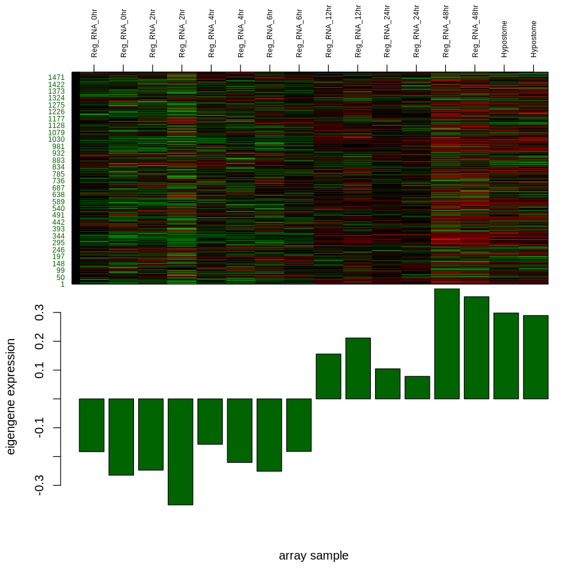

```r
which.module="darkgreen"
ME=datME[, paste("ME",which.module, sep="")]
par(mfrow=c(2,1), mar=c(0.3, 5.5, 5, 2))
plotMat(t(scale(datExpr[,moduleColors==which.module ]) ),
        nrgcols=30,rlabels=T,rcols=which.module,clabels=sample_names,
         cex.main=2)
par(mar=c(5, 4.2, 0, 0.7))
barplot(ME, col=which.module, main="", cex.main=2,
        ylab="eigengene expression",xlab="array sample")
```

```r
#this chunk of code below is to save the graph as a pdf for publication
pdf("FIGURES_wnt3_darkgreen_eigengene.pdf")

which.module="darkgreen"
ME=datME[, paste("ME",which.module, sep="")]
par(mfrow=c(2,1), mar=c(0.3, 5.5, 5, 2))
plotMat(t(scale(datExpr[,moduleColors==which.module ]) ),
        nrgcols=30,rlabels=T,rcols=which.module,clabels=sample_names,
         cex.main=2)
par(mar=c(5, 4.2, 0, 0.7))
barplot(ME, col=which.module, main="", cex.main=2,
        ylab="eigengene expression",xlab="array sample")




# Closing the graphical device
dev.off()
```

**png:** 2

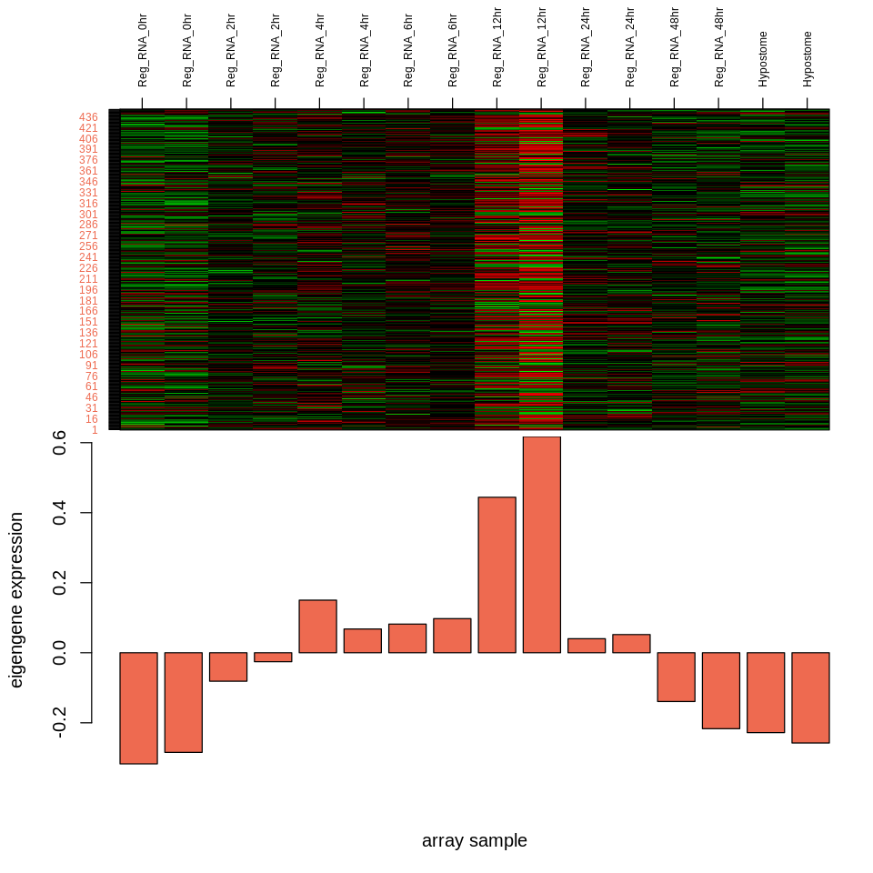

```r
which.module="coral2"
ME=datME[, paste("ME",which.module, sep="")]
par(mfrow=c(2,1), mar=c(0.3, 5.5, 5, 2))
plotMat(t(scale(datExpr[,moduleColors==which.module ]) ),
        nrgcols=30,rlabels=T,rcols=which.module,clabels=sample_names,
         cex.main=2)
par(mar=c(5, 4.2, 0, 0.7))
barplot(ME, col=which.module, main="", cex.main=2,
        ylab="eigengene expression",xlab="array sample")
```

```r
#this chunk of code below is to save the graph as a pdf for publication
pdf("FIGURES_jun_fos_coral2_eigengene.pdf")

which.module="coral2"
ME=datME[, paste("ME",which.module, sep="")]
par(mfrow=c(2,1), mar=c(0.3, 5.5, 5, 2))
plotMat(t(scale(datExpr[,moduleColors==which.module ]) ),
        nrgcols=30,rlabels=T,rcols=which.module,clabels=sample_names,
         cex.main=2)
par(mar=c(5, 4.2, 0, 0.7))
barplot(ME, col=which.module, main="", cex.main=2,
        ylab="eigengene expression",xlab="array sample")




# Closing the graphical device
dev.off()
```

**png:** 2

```r
datKME =signedKME(datExpr, datME, outputColumnName="MM.")
head(datKME)
```

A data.frame: 6 × 31

|  | MM.blue2 <dbl> | MM.blueviolet <dbl> | MM.coral <dbl> | MM.coral2 <dbl> | MM.darkgreen <dbl> | MM.darkolivegreen2 <dbl> | MM.darkorange <dbl> | MM.darkseagreen3 <dbl> | MM.darkseagreen4 <dbl> | MM.darkviolet <dbl> | ⋯ | MM.magenta4 <dbl> | MM.maroon <dbl> | MM.mediumpurple2 <dbl> | MM.mediumpurple3 <dbl> | MM.navajowhite1 <dbl> | MM.orange <dbl> | MM.pink4 <dbl> | MM.salmon <dbl> | MM.sienna3 <dbl> | MM.yellow3 <dbl> |
| --- | --- | --- | --- | --- | --- | --- | --- | --- | --- | --- | --- | --- | --- | --- | --- | --- | --- | --- | --- | --- | --- |
| Sc4wPfr_1.g5776 | -0.2750700 | 0.4105593 | 0.15234137 | -0.2033124 | -0.5569074 | 0.23439917 | 0.58981448 | 0.6628683 | -0.19899702 | 0.2670927 | ⋯ | -0.6033996 | -0.040442116 | -0.2754719 | 0.35734455 | -0.46468239 | 0.17737095 | -0.1354311 | 0.43233126 | -0.1974880 | 0.12466671 |
| Sc4wPfr_1.g5779 | -0.4462749 | 0.4614629 | 0.01794797 | 0.2856970 | -0.5300994 | -0.16260199 | 0.17262419 | 0.3686916 | 0.15742149 | 0.2852772 | ⋯ | 0.1034255 | -0.002914036 | -0.3078708 | 0.04382081 | -0.06911064 | 0.04255594 | -0.2777784 | 0.13336148 | -0.2810529 | 0.53246702 |
| Sc4wPfr_1.g5780 | -0.4221721 | 0.2243329 | 0.04813905 | 0.3521242 | -0.2854745 | -0.26208404 | -0.07532696 | -0.1735903 | 0.57555620 | -0.1123236 | ⋯ | 0.3332765 | 0.007923119 | -0.1881521 | 0.10119766 | 0.28913841 | -0.28283492 | -0.3697415 | -0.25216193 | -0.4431274 | -0.03603257 |
| Sc4wPfr_1.g5781 | -0.3082147 | 0.7038150 | -0.46536282 | -0.2125663 | -0.6180410 | 0.07020468 | 0.25434531 | 0.3985817 | 0.09514295 | 0.7177286 | ⋯ | -0.0502985 | -0.868156409 | -0.5471675 | -0.18742693 | 0.27545622 | -0.26803781 | -0.4106775 | -0.19117715 | 0.2518422 | 0.19736854 |
| Sc4wPfr_1.g5782 | -0.4305630 | 0.8130034 | -0.14856571 | -0.2987855 | -0.7241216 | -0.02965970 | 0.53887823 | 0.5918554 | -0.04513414 | 0.7171432 | ⋯ | -0.3761733 | -0.737647131 | -0.3383151 | 0.09962446 | 0.06925501 | -0.03068371 | -0.3103478 | -0.08458953 | 0.2138081 | 0.34931545 |
| Sc4wPfr_1.g5784 | -0.2101353 | 0.6840824 | -0.46333442 | -0.4978124 | -0.6243057 | 0.21379462 | 0.25602262 | 0.5800484 | -0.14756233 | 0.6935558 | ⋯ | -0.4022432 | -0.813557711 | -0.5196824 | -0.15647806 | 0.10390576 | -0.45137274 | -0.2388063 | -0.03898069 | 0.4255282 | 0.37191058 |

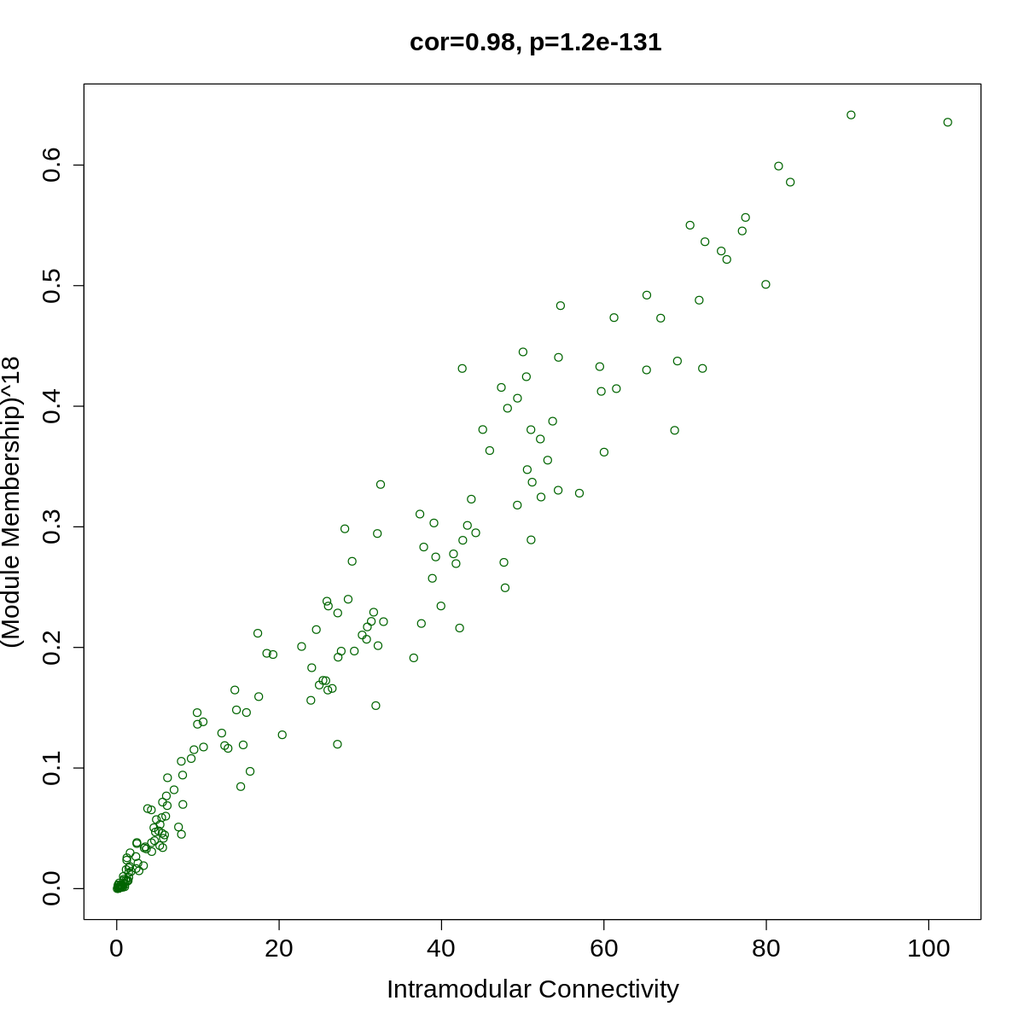

```r
which.color="darkgreen";
restrictGenes=dynamicColors==which.color
verboseScatterplot(Alldegrees1$kWithin[ restrictGenes],
(datKME[restrictGenes, paste("MM.", which.color, sep="")])^10,
col=which.color,
xlab="Intramodular Connectivity",
ylab="(Module Membership)^18")
```

```r
#now I want to identify the top 50 genes with highest intramodular connectivity and Module memebership (hub genes).

combined_datKME_ADJ1 = merge(datKME, Alldegrees1, by=0)
```

```r
combined_datKME_ADJ1
```

A data.frame: 16971 × 36

| Row.names <I<chr>> | MM.blue2 <dbl> | MM.blueviolet <dbl> | MM.coral <dbl> | MM.coral2 <dbl> | MM.darkgreen <dbl> | MM.darkolivegreen2 <dbl> | MM.darkorange <dbl> | MM.darkseagreen3 <dbl> | MM.darkseagreen4 <dbl> | ⋯ | MM.navajowhite1 <dbl> | MM.orange <dbl> | MM.pink4 <dbl> | MM.salmon <dbl> | MM.sienna3 <dbl> | MM.yellow3 <dbl> | kTotal <dbl> | kWithin <dbl> | kOut <dbl> | kDiff <dbl> |
| --- | --- | --- | --- | --- | --- | --- | --- | --- | --- | --- | --- | --- | --- | --- | --- | --- | --- | --- | --- | --- |
| Sc4wPfr_1.g5776 | -0.275069993 | 0.410559291 | 0.152341366 | -0.203312416 | -0.55690742 | 0.23439917 | 0.58981448 | 0.66286830 | -0.198997021 | ⋯ | -0.46468239 | 0.177370951 | -0.1354311 | 0.432331263 | -0.197487972 | 0.12466671 | 1.7011187 | 0.3925020 | 1.3086167 | -0.91611475 |
| Sc4wPfr_1.g5779 | -0.446274873 | 0.461462895 | 0.017947968 | 0.285697034 | -0.53009936 | -0.16260199 | 0.17262419 | 0.36869158 | 0.157421491 | ⋯ | -0.06911064 | 0.042555938 | -0.2777784 | 0.133361481 | -0.281052877 | 0.53246702 | 0.7406525 | 0.2677687 | 0.4728838 | -0.20511502 |
| Sc4wPfr_1.g5780 | -0.422172109 | 0.224332874 | 0.048139048 | 0.352124247 | -0.28547448 | -0.26208404 | -0.07532696 | -0.17359034 | 0.575556196 | ⋯ | 0.28913841 | -0.282834916 | -0.3697415 | -0.252161934 | -0.443127392 | -0.03603257 | 0.5294099 | 0.1607676 | 0.3686423 | -0.20787468 |
| Sc4wPfr_1.g5781 | -0.308214745 | 0.703814961 | -0.465362825 | -0.212566343 | -0.61804095 | 0.07020468 | 0.25434531 | 0.39858172 | 0.095142953 | ⋯ | 0.27545622 | -0.268037810 | -0.4106775 | -0.191177154 | 0.251842185 | 0.19736854 | 29.7004980 | 2.8531368 | 26.8473611 | -23.99422432 |
| Sc4wPfr_1.g5782 | -0.430562969 | 0.813003365 | -0.148565706 | -0.298785455 | -0.72412163 | -0.02965970 | 0.53887823 | 0.59185541 | -0.045134138 | ⋯ | 0.06925501 | -0.030683709 | -0.3103478 | -0.084589527 | 0.213808116 | 0.34931545 | 54.0871454 | 16.5175919 | 37.5695535 | -21.05196156 |
| Sc4wPfr_1.g5784 | -0.210135314 | 0.684082359 | -0.463334421 | -0.497812379 | -0.62430574 | 0.21379462 | 0.25602262 | 0.58004842 | -0.147562326 | ⋯ | 0.10390576 | -0.451372737 | -0.2388063 | -0.038980688 | 0.425528161 | 0.37191058 | 42.2301735 | 7.9833779 | 34.2467956 | -26.26341774 |
| Sc4wPfr_1.g5785 | 0.474887969 | -0.399185492 | 0.008736206 | -0.147596445 | 0.54356516 | 0.02940227 | -0.24330418 | -0.11922547 | -0.475094781 | ⋯ | -0.38932089 | 0.107465123 | 0.7301634 | 0.141829226 | 0.433853885 | 0.28361728 | 1.9945761 | 1.0344452 | 0.9601309 | 0.07431425 |
| Sc4wPfr_1.g5786 | 0.166017418 | -0.528272753 | 0.442528278 | 0.142827335 | 0.53134341 | -0.26029197 | -0.08156138 | -0.57575207 | 0.131614748 | ⋯ | 0.25555724 | 0.418304670 | 0.1112086 | -0.210633483 | -0.187545066 | -0.52413002 | 2.1717429 | 0.7919784 | 1.3797645 | -0.58778602 |
| Sc4wPfr_1.g5788 | 0.722013775 | -0.746610340 | -0.271960370 | -0.142620849 | 0.81510083 | 0.25368062 | -0.65618631 | -0.45742782 | -0.311557861 | ⋯ | -0.01065196 | -0.170334350 | 0.3959573 | -0.076685822 | 0.334675276 | -0.27645171 | 31.6768580 | 14.1205826 | 17.5562753 | -3.43569274 |
| Sc4wPfr_1.g5789 | -0.502220231 | 0.861815090 | -0.047414778 | -0.181588268 | -0.79945313 | 0.06125256 | 0.74690189 | 0.67075789 | -0.006804845 | ⋯ | -0.11896705 | 0.162337561 | -0.4515567 | 0.004794642 | -0.011375235 | 0.11437920 | 89.1790915 | 51.9019328 | 37.2771587 | 14.62477412 |
| Sc4wPfr_1.g5790 | 0.535060356 | -0.304963892 | -0.452201721 | -0.273445392 | 0.49710882 | 0.11443580 | -0.55382254 | -0.13847708 | -0.451680203 | ⋯ | -0.21989116 | -0.569678341 | 0.6730716 | -0.026704376 | 0.640625577 | 0.19107381 | 1.2730904 | 0.7655192 | 0.5075712 | 0.25794801 |
| Sc4wPfr_1.g5791 | -0.506716673 | 0.874556567 | -0.176763696 | -0.120362150 | -0.77521077 | 0.06275635 | 0.48763207 | 0.61080301 | 0.058622247 | ⋯ | -0.06212750 | -0.128490861 | -0.5283646 | -0.130412607 | -0.010224033 | 0.34163441 | 72.5730001 | 49.0701866 | 23.5028136 | 25.56737300 |
| Sc4wPfr_1.g5792 | 0.339239420 | -0.725004166 | 0.195664522 | 0.307245824 | 0.80156809 | -0.35623068 | -0.63015481 | -0.87418679 | 0.237165864 | ⋯ | 0.42682989 | -0.004934899 | 0.3027683 | -0.363115551 | -0.007380168 | -0.21085135 | 64.0700845 | 25.2499606 | 38.8201239 | -13.57016325 |
| Sc4wPfr_10.g18872 | 0.456213656 | 0.007321388 | -0.697064151 | -0.001798564 | 0.22170378 | 0.36066156 | -0.29972694 | 0.19102893 | -0.440939352 | ⋯ | -0.37412453 | -0.097366399 | 0.2102387 | 0.068929450 | 0.503243967 | 0.21769392 | 1.3549692 | 0.5561602 | 0.7988090 | -0.24264879 |
| Sc4wPfr_10.g18874 | 0.245369420 | -0.538970486 | 0.308050656 | 0.281104059 | 0.66353729 | -0.33167730 | -0.43804811 | -0.64963094 | 0.084619619 | ⋯ | -0.04174152 | 0.074726139 | 0.5266911 | -0.204995796 | -0.027989985 | 0.11365955 | 12.5825122 | 7.6764220 | 4.9060902 | 2.77033186 |
| Sc4wPfr_10.g18875 | 0.519703274 | -0.490357776 | -0.207075073 | -0.272698148 | 0.64552067 | -0.14436224 | -0.45436043 | -0.51702972 | -0.156089298 | ⋯ | 0.34164775 | -0.172153512 | 0.5962896 | -0.273633828 | 0.600520343 | -0.15110722 | 15.6992427 | 8.4490643 | 7.2501784 | 1.19888590 |
| Sc4wPfr_10.g18876 | 0.704684332 | -0.681439846 | -0.184334572 | -0.328250831 | 0.55474868 | 0.40219331 | -0.33351327 | -0.01958946 | -0.574779350 | ⋯ | -0.38934050 | -0.051032573 | 0.7656363 | 0.590630588 | 0.463343149 | -0.04980896 | 8.3888105 | 4.5575405 | 3.8312700 | 0.72627052 |
| Sc4wPfr_10.g18878 | -0.382456573 | 0.332088272 | 0.118929472 | 0.078882418 | -0.57838476 | 0.16780698 | 0.48037203 | 0.43905846 | 0.144286427 | ⋯ | 0.10544879 | 0.339579502 | -0.7115084 | 0.255094330 | -0.445233865 | -0.16049133 | 1.4939707 | 0.3588614 | 1.1351092 | -0.77624780 |
| Sc4wPfr_10.g18880 | 0.459294726 | -0.583987343 | 0.042340143 | 0.364151704 | 0.68425348 | 0.03150119 | -0.47011581 | -0.29776114 | -0.277929625 | ⋯ | -0.49752496 | 0.158584871 | 0.4806474 | 0.145322106 | -0.015540914 | 0.15705446 | 15.2792610 | 4.2388499 | 11.0404112 | -6.80156129 |
| Sc4wPfr_10.g18882 | 0.936437654 | -0.566870906 | -0.734178371 | -0.503169255 | 0.59936936 | 0.68649280 | -0.52752024 | 0.08962367 | -0.764910631 | ⋯ | -0.40808117 | -0.287063176 | 0.6467653 | 0.381911075 | 0.765866897 | -0.07857270 | 147.5190853 | 138.9126827 | 8.6064026 | 130.30628007 |
| Sc4wPfr_10.g18884 | 0.041462830 | -0.450591042 | 0.474127707 | 0.573502683 | 0.47624547 | -0.37363906 | -0.08526538 | -0.54990471 | 0.251554295 | ⋯ | -0.02490348 | 0.569291769 | 0.1423513 | -0.109153260 | -0.428783056 | -0.24956410 | 5.3197789 | 3.1846347 | 2.1351442 | 1.04949049 |
| Sc4wPfr_10.g18885 | -0.004154643 | -0.403483989 | 0.290995514 | 0.523005245 | 0.40113359 | -0.25176977 | -0.28465318 | -0.59919792 | 0.392987127 | ⋯ | 0.13618521 | 0.244753925 | -0.1339691 | -0.291442218 | -0.525439101 | -0.45967515 | 2.9666573 | 0.6124674 | 2.3541899 | -1.74172252 |
| Sc4wPfr_10.g18888 | 0.576520194 | -0.413221927 | -0.330445779 | -0.460492873 | 0.19304820 | 0.67812891 | -0.14614159 | 0.37999773 | -0.663078626 | ⋯ | -0.49234114 | -0.075626809 | 0.4375555 | 0.769898300 | 0.393825966 | -0.06689268 | 1.8862756 | 0.5518951 | 1.3343804 | -0.78248529 |
| Sc4wPfr_10.g18890 | 0.562211721 | -0.686000505 | 0.035793486 | -0.097980941 | 0.80167695 | -0.11462104 | -0.45852432 | -0.61726626 | -0.121590514 | ⋯ | 0.17168525 | 0.058997278 | 0.5954283 | -0.182908922 | 0.369586667 | -0.20994970 | 22.7731061 | 8.7804515 | 13.9926546 | -5.21220305 |
| Sc4wPfr_10.g18893 | 0.237293890 | 0.011633153 | -0.132012897 | -0.470674919 | -0.06056911 | 0.42892464 | 0.20612873 | 0.48925319 | -0.558940344 | ⋯ | -0.53638900 | 0.035689438 | 0.2787345 | 0.434946395 | 0.295892529 | 0.04000051 | 0.2201775 | 0.0281905 | 0.1919870 | -0.16379651 |
| Sc4wPfr_10.g18894 | -0.467449396 | 0.814449701 | -0.076925153 | -0.098206506 | -0.66590799 | -0.14706016 | 0.58928329 | 0.50827553 | 0.023155788 | ⋯ | -0.01504557 | 0.184077041 | -0.2820066 | -0.143618571 | 0.097973484 | 0.37071238 | 33.7643064 | 22.5454424 | 11.2188640 | 11.32657847 |
| Sc4wPfr_10.g18895 | 0.009620382 | -0.402908358 | 0.434134051 | 0.257370378 | 0.18219835 | -0.02902540 | 0.08254372 | -0.22206037 | 0.161839045 | ⋯ | 0.06856410 | 0.633066835 | -0.1588285 | 0.176759147 | -0.511890748 | -0.35983710 | 0.6190794 | 0.1918449 | 0.4272345 | -0.23538967 |
| Sc4wPfr_10.g18896 | -0.066458212 | -0.259522381 | 0.122351895 | 0.205720478 | 0.17072071 | -0.14950743 | -0.21009905 | -0.48021399 | 0.434492984 | ⋯ | 0.35941822 | -0.031695611 | -0.2277762 | -0.296301869 | -0.374911715 | -0.47933068 | 0.9275391 | 0.2261930 | 0.7013460 | -0.47515300 |
| Sc4wPfr_10.g18897 | -0.773679363 | 0.933295899 | 0.134954022 | 0.123786468 | -0.77282124 | -0.38101110 | 0.58311455 | 0.26479509 | 0.440356500 | ⋯ | 0.19208748 | 0.013231320 | -0.5048948 | -0.415255141 | -0.199752567 | 0.23514399 | 135.4086534 | 101.1709531 | 34.2377003 | 66.93325278 |
| Sc4wPfr_10.g18898 | -0.427257642 | 0.498793791 | 0.151448289 | -0.481416878 | -0.72048012 | 0.08260293 | 0.60798152 | 0.56611206 | -0.030119744 | ⋯ | -0.03958628 | -0.155862636 | -0.1122681 | 0.318203016 | -0.022822296 | -0.10853363 | 7.8027898 | 3.0688310 | 4.7339588 | -1.66512773 |
| ⋮ | ⋮ | ⋮ | ⋮ | ⋮ | ⋮ | ⋮ | ⋮ | ⋮ | ⋮ | ⋱ | ⋮ | ⋮ | ⋮ | ⋮ | ⋮ | ⋮ | ⋮ | ⋮ | ⋮ | ⋮ |
| Sc4wPfr_983.g32896 | -0.672736887 | 0.72011348 | 0.281735800 | -0.232397496 | -0.82951256 | -0.16961826 | 0.80317225 | 0.47704440 | 0.233381063 | ⋯ | 0.24123130 | 0.17664014 | -0.532488614 | -0.047450311 | -0.25772792 | -0.11032630 | 35.7615334 | 14.82534371 | 20.93618973 | -6.11084602 |
| Sc4wPfr_983.g32898 | -0.811929287 | 0.87315790 | 0.204591243 | 0.505067134 | -0.74382412 | -0.33624791 | 0.52427081 | 0.28586824 | 0.482305010 | ⋯ | 0.01406240 | 0.23999304 | -0.728891183 | -0.314182951 | -0.53283727 | 0.33395538 | 87.3137334 | 56.91717444 | 30.39655900 | 26.52061544 |
| Sc4wPfr_983.g32899 | -0.128459763 | -0.11232996 | 0.444914373 | 0.393528284 | 0.05703240 | -0.19270768 | 0.18013237 | -0.09600861 | 0.161529317 | ⋯ | 0.03496093 | 0.72533762 | -0.167234497 | 0.071301980 | -0.37815918 | 0.12159912 | 0.1947173 | 0.10072651 | 0.09399084 | 0.00673567 |
| Sc4wPfr_984.g6930 | 0.350590847 | -0.73923462 | 0.278485229 | 0.240450742 | 0.79549295 | -0.32610577 | -0.46588777 | -0.82097362 | 0.176343409 | ⋯ | 0.26812671 | 0.05409551 | 0.416037247 | -0.259626227 | -0.03515167 | -0.32110289 | 48.4025587 | 19.32906345 | 29.07349522 | -9.74443177 |
| Sc4wPfr_985.g24067 | 0.005083748 | 0.14719087 | -0.428991228 | 0.098515559 | -0.06284759 | -0.04898316 | -0.39716635 | -0.02166232 | 0.093132439 | ⋯ | 0.23048198 | -0.49360911 | -0.065029234 | -0.170500588 | 0.20436338 | 0.45451499 | 0.2857678 | 0.11437826 | 0.17138953 | -0.05701127 |
| Sc4wPfr_985.g24068 | 0.345444178 | -0.45710054 | -0.075031809 | 0.075316588 | 0.40315821 | 0.15537590 | -0.16712279 | -0.32970129 | -0.028600479 | ⋯ | 0.06717420 | 0.26717978 | 0.109038166 | 0.075879774 | 0.01912655 | -0.61472181 | 0.1783468 | 0.10190069 | 0.07644616 | 0.02545453 |
| Sc4wPfr_985.g24069 | 0.289290411 | -0.37518666 | 0.146825895 | 0.249850779 | 0.37886592 | 0.07745859 | 0.04101436 | -0.10137904 | -0.198389944 | ⋯ | -0.18508989 | 0.79442262 | 0.025577335 | 0.149542446 | -0.15193774 | -0.21701460 | 0.8923646 | 0.64584761 | 0.24651700 | 0.39933061 |
| Sc4wPfr_985.g24070 | 0.762498473 | -0.44744730 | -0.641802374 | -0.522068026 | 0.55504059 | 0.40864777 | -0.50628939 | -0.10622881 | -0.519502378 | ⋯ | 0.04885564 | -0.41232902 | 0.464340176 | 0.015214112 | 0.78283995 | -0.12501225 | 31.0145233 | 27.84471413 | 3.16980920 | 24.67490493 |
| Sc4wPfr_985.g24071 | 0.482897713 | 0.02411108 | -0.755589679 | -0.649116073 | 0.01786450 | 0.57874581 | -0.24014487 | 0.43947052 | -0.639134836 | ⋯ | -0.14991318 | -0.52406818 | 0.200325561 | 0.225935646 | 0.74117502 | 0.26883860 | 6.1535061 | 3.05317026 | 3.10033584 | -0.04716558 |
| Sc4wPfr_985.g24072 | 0.099592554 | 0.46858267 | -0.548610520 | -0.599867580 | -0.47019943 | 0.58810659 | 0.31633934 | 0.78802957 | -0.519009063 | ⋯ | -0.30092607 | -0.16064560 | -0.104075068 | 0.329409027 | 0.49720148 | 0.20237802 | 33.2158252 | 18.44523160 | 14.77059362 | 3.67463798 |
| Sc4wPfr_989.g17933 | 0.084890533 | -0.42542445 | 0.377350410 | 0.240168608 | 0.61621028 | -0.59686603 | -0.48234981 | -0.82266118 | 0.313710514 | ⋯ | 0.43519194 | -0.13216759 | 0.366545838 | -0.553460237 | 0.06268642 | 0.11632678 | 14.0119086 | 1.58665770 | 12.42525094 | -10.83859325 |
| Sc4wPfr_989.g17934 | 0.640289494 | -0.47402711 | -0.146605298 | -0.460365392 | 0.33450479 | 0.56403170 | -0.03189060 | 0.39526589 | -0.840508884 | ⋯ | -0.76839559 | 0.14739926 | 0.719095925 | 0.791903362 | 0.40045361 | 0.01916946 | 12.5118762 | 8.22478119 | 4.28709500 | 3.93768619 |
| Sc4wPfr_989.g17935 | 0.508836245 | -0.61741480 | 0.133887237 | -0.049384697 | 0.53389862 | 0.24911517 | -0.17246478 | -0.04107626 | -0.476516797 | ⋯ | -0.65790625 | 0.27018559 | 0.674088972 | 0.512444450 | 0.06427585 | -0.11262497 | 11.8640147 | 4.40172668 | 7.46228802 | -3.06056135 |
| Sc4wPfr_989.g17938 | 0.747920031 | -0.39399696 | -0.622890253 | -0.665475768 | 0.40575974 | 0.62645724 | -0.40170914 | 0.18773410 | -0.721030787 | ⋯ | -0.34303713 | -0.48719147 | 0.534835040 | 0.291330968 | 0.70912880 | -0.09240971 | 11.4192778 | 9.71238232 | 1.70689552 | 8.00548680 |
| Sc4wPfr_989.g17940 | 0.048443296 | 0.36475185 | -0.259085618 | -0.696583371 | -0.44810936 | 0.46327999 | 0.34034193 | 0.79254570 | -0.576049920 | ⋯ | -0.42616324 | -0.18449347 | 0.163844429 | 0.468088390 | 0.42979169 | 0.34336025 | 13.2645647 | 7.66537370 | 5.59919095 | 2.06618275 |
| Sc4wPfr_989.g17941 | -0.310336993 | 0.11814241 | 0.325885147 | -0.008958121 | -0.45672726 | 0.16170660 | 0.40517609 | 0.40282472 | 0.075907181 | ⋯ | -0.15595238 | 0.17822070 | -0.272293215 | 0.513184296 | -0.45460692 | -0.21722347 | 0.6437947 | 0.19566745 | 0.44812721 | -0.25245975 |
| Sc4wPfr_989.g17942 | -0.416654568 | 0.23692166 | 0.156823640 | 0.363713768 | -0.18474980 | -0.25301145 | -0.02011755 | -0.33092669 | 0.613311710 | ⋯ | 0.40370809 | -0.23241064 | -0.512762037 | -0.461924365 | -0.37392081 | -0.08033160 | 0.4441178 | 0.18665514 | 0.25746268 | -0.07080754 |
| Sc4wPfr_99.1.g24286 | 0.466784190 | -0.72087989 | -0.105763996 | 0.284966122 | 0.56811856 | 0.28246409 | -0.56150611 | -0.33667896 | -0.075350879 | ⋯ | -0.18824697 | 0.01175499 | 0.118190170 | 0.231550569 | -0.24007075 | -0.32508519 | 10.4934872 | 2.20446185 | 8.28902539 | -6.08456354 |
| Sc4wPfr_999.g13395 | -0.183912679 | 0.54633698 | -0.275213134 | -0.363328988 | -0.47215354 | 0.08803908 | 0.45441539 | 0.36982478 | -0.046658781 | ⋯ | 0.24161365 | 0.02465777 | -0.297228304 | -0.132215884 | 0.29211432 | -0.10196236 | 5.9856580 | 1.98498655 | 4.00067148 | -2.01568493 |
| Sc4wPfr_999.g13396 | 0.384228884 | -0.41623431 | -0.004057546 | 0.200661476 | 0.55545755 | -0.08603182 | -0.24213328 | -0.30533301 | -0.206296249 | ⋯ | -0.32487480 | 0.18455853 | 0.577999960 | 0.064190578 | 0.15525464 | -0.06567426 | 1.3836916 | 0.40853776 | 0.97515382 | -0.56661606 |
| Sc4wPfr_999.g13398 | -0.412880448 | 0.73936395 | -0.154448338 | -0.370736218 | -0.74533347 | 0.16521906 | 0.58628646 | 0.58142376 | 0.002105408 | ⋯ | 0.05219992 | -0.03703445 | -0.476695442 | -0.042938336 | 0.05473089 | -0.03747307 | 37.4807405 | 14.55286752 | 22.92787294 | -8.37500542 |
| Sc4wPfr_999.g13400 | 0.080749599 | -0.42303589 | 0.400944326 | 0.217501181 | 0.58218462 | -0.52162694 | -0.23709545 | -0.81657182 | 0.375310528 | ⋯ | 0.39655061 | 0.07749045 | 0.258465763 | -0.551453122 | -0.08694233 | -0.41680895 | 7.5324088 | 2.68998411 | 4.84242469 | -2.15244057 |
| Sc4wPfr_999.g13403 | 0.232750212 | -0.50214265 | 0.077077085 | 0.276829610 | 0.40768992 | -0.02118932 | -0.21540802 | -0.45127135 | 0.181872172 | ⋯ | 0.24066963 | 0.31025787 | 0.003821986 | 0.003637396 | -0.18173099 | -0.42541530 | 0.5633444 | 0.34643426 | 0.21691017 | 0.12952409 |
| Sc4wPfr_999.g13404 | 0.206905113 | 0.24191206 | -0.730975044 | -0.118153809 | -0.23978461 | 0.58101204 | -0.06151465 | 0.50907454 | -0.297074957 | ⋯ | -0.12887008 | -0.09635426 | -0.381081221 | 0.198541243 | 0.24871713 | 0.12935111 | 4.0020720 | 1.32975280 | 2.67231917 | -1.34256637 |
| Sc4wPfr_999.g13405 | -0.841300392 | 0.46002430 | 0.698691151 | 0.568648223 | -0.41731036 | -0.77568416 | 0.36270204 | -0.29738796 | 0.835416442 | ⋯ | 0.44563387 | 0.23244792 | -0.459590521 | -0.494787352 | -0.67170244 | 0.14396654 | 47.7190162 | 38.53581869 | 9.18319753 | 29.35262116 |
| Sc4wPfr_999.g13406 | 0.705033011 | -0.83567977 | -0.230870838 | 0.020640164 | 0.86044444 | 0.11923694 | -0.73427088 | -0.59042905 | -0.155906755 | ⋯ | 0.07531460 | -0.16303823 | 0.535483008 | -0.006660877 | 0.33082737 | -0.15158443 | 58.6568699 | 19.25726223 | 39.39960770 | -20.14234547 |
| Sc4wPfr_999.g13407 | 0.302258046 | -0.75540767 | 0.276054434 | 0.351564999 | 0.61294705 | -0.09350737 | -0.45573192 | -0.54185242 | 0.091007729 | ⋯ | -0.01731988 | 0.11318179 | 0.294136852 | 0.151133971 | -0.28439882 | -0.21011525 | 33.5765102 | 5.66994488 | 27.90656530 | -22.23662041 |
| Sc4wPfr_999.g13408 | -0.109397007 | -0.14223971 | 0.041223785 | -0.058923414 | -0.11153110 | 0.00324040 | -0.06962958 | -0.18480422 | 0.332931146 | ⋯ | 0.51563689 | -0.22517305 | -0.275734795 | 0.007603803 | -0.18232994 | -0.30565659 | 0.7198318 | 0.33812188 | 0.38170989 | -0.04358800 |
| Sc4wPfr_999.g13412 | -0.099898375 | 0.16062133 | -0.385531534 | 0.090949281 | -0.18017480 | 0.09068625 | -0.22116713 | -0.03803613 | 0.249502273 | ⋯ | 0.21245733 | -0.49613390 | -0.274209479 | -0.132145968 | -0.01006947 | 0.08368037 | 0.1355572 | 0.08039444 | 0.05516279 | 0.02523165 |
| Sc4wPfr_999.g13414 | 0.141697271 | -0.34149761 | 0.279712005 | 0.402192123 | 0.32266352 | -0.05621122 | -0.15664838 | -0.13224293 | -0.039502453 | ⋯ | -0.21357136 | 0.32559097 | 0.097099766 | 0.183781121 | -0.22880635 | 0.20706103 | 0.6987762 | 0.18349823 | 0.51527795 | -0.33177972 |

```r
subset_combined_datKME_ADJ1 = dplyr::select(combined_datKME_ADJ1, c("Row.names","MM.darkgreen", "kWithin","kTotal"))
```

```r
head(subset_combined_datKME_ADJ1)
```

A data.frame: 6 × 4

|  | Row.names <I<chr>> | MM.darkgreen <dbl> | kWithin <dbl> | kTotal <dbl> |
| --- | --- | --- | --- | --- |
| 1 | Sc4wPfr_1.g5776 | -0.5569074 | 0.3925020 | 1.7011187 |
| 2 | Sc4wPfr_1.g5779 | -0.5300994 | 0.2677687 | 0.7406525 |
| 3 | Sc4wPfr_1.g5780 | -0.2854745 | 0.1607676 | 0.5294099 |
| 4 | Sc4wPfr_1.g5781 | -0.6180410 | 2.8531368 | 29.7004980 |
| 5 | Sc4wPfr_1.g5782 | -0.7241216 | 16.5175919 | 54.0871454 |
| 6 | Sc4wPfr_1.g5784 | -0.6243057 | 7.9833779 | 42.2301735 |

```r
#make the transcript ids rownames again
#row.names(subset_combined_datKME_ADJ1) <- subset_combined_datKME_ADJ1$Row.names
#subset_combined_datKME_ADJ1[1] <- NULL
```

```r
#top 2000 genes with high connectivity
top_200_datKME_ADJ1 <-subset_combined_datKME_ADJ1 %>% filter(subset_combined_datKME_ADJ1$MM.darkgreen >= 0.1) %>% arrange(desc(MM.darkgreen, kWithin)) %>% dplyr::select(Row.names,MM.darkgreen,kWithin) %>% head(2000)
```

```r
head(top_200_datKME_ADJ1)
```

A data.frame: 6 × 3

|  | Gene_ID <I<chr>> | MM.darkgreen <dbl> | kWithin <dbl> |
| --- | --- | --- | --- |
| 1 | Sc4wPfr_384.g24771 | 0.9892189 | 118.8003 |
| 2 | Sc4wPfr_482.g19112 | 0.9872021 | 111.2688 |
| 3 | Sc4wPfr_552.g10517 | 0.9798553 | 105.4045 |
| 4 | Sc4wPfr_242.g27678 | 0.9785817 | 103.8711 |
| 5 | Sc4wPfr_215.1.g29569 | 0.9782934 | 112.4946 |
| 6 | Sc4wPfr_796.g23338 | 0.9765075 | 106.6900 |

```r
#take the top 2000 genes and find thier corresponding gene annotations
names(top_200_datKME_ADJ1)[1] <- 'Gene_ID'
top_200_datKME_ADJ1_annotated <- setDT(GeneGO_table_4, key = 'Gene_ID')[J(top_200_datKME_ADJ1)]
```

```r
top_200_datKME_ADJ1_annotated
```

A data.table: 2000 × 5

| Gene_ID <I<chr>> | Description <chr> | GO_Names <chr> | MM.darkgreen <dbl> | kWithin <dbl> |
| --- | --- | --- | --- | --- |
| Sc4wPfr_384.g24771 | cAMP-dependent_kinase_catalytic_subunit_beta_isoform_X2 | F:protein_serine/threonine_kinase_activity;_F:ATP_binding;_P:protein_phosphorylation | 0.9892189 | 118.80029 |
| Sc4wPfr_482.g19112 | uncharacterized_LOC100210581 | C:membrane | 0.9872021 | 111.26881 |
| Sc4wPfr_552.g10517 | Low_choriolytic_enzyme | F:metalloendopeptidase_activity;_P:proteolysis;_F:zinc_ion_binding | 0.9798553 | 105.40446 |
| Sc4wPfr_242.g27678 | PREDICTED:_uncharacterized_protein_LOC100202684 | NoGOs | 0.9785817 | 103.87108 |
| Sc4wPfr_215.1.g29569 | synaptic_vesicle_glyco_2B-like | C:integral_component_of_membrane;_P:transmembrane_transport | 0.9782934 | 112.49459 |
| Sc4wPfr_796.g23338 | Cell_cycle_control_50A | C:membrane | 0.9765075 | 106.69000 |
| Sc4wPfr_2949.g24301 | partitioning_defective_6_homolog_gamma-like | F:protein_binding;_P:establishment_or_maintenance_of_cell_polarity | 0.9749459 | 95.66878 |
| Sc4wPfr_59.2.g12563 | F-actin-capping_subunit_alpha | C:F-actin_capping_protein_complex;_P:barbed-end_actin_filament_capping | 0.9747188 | 105.31296 |
| Sc4wPfr_881.g1671 | ly6_PLAUR_domain-containing_1-like | NoGOs | 0.9736288 | 99.68285 |
| Sc4wPfr_366.g23825 | transmembrane_59 | C:membrane;_C:integral_component_of_membrane | 0.9721420 | 111.63348 |
| Sc4wPfr_224.1.g33451 | Transmembrane_50A | C:cytoplasm;_C:integral_component_of_membrane | 0.9719653 | 97.56426 |
| Sc4wPfr_739.g28832 | PREDICTED:_syndecan-2-B-like | P:axon_guidance;_C:membrane | 0.9713760 | 89.86571 |
| Sc4wPfr_62.g4475 | PREDICTED:_uncharacterized_protein_LOC101239931_isoform_X2 | NoGOs | 0.9710370 | 95.79704 |
| Sc4wPfr_446.g12574 | T-cell_immunomodulatory | C:extracellular_region;_C:plasma_membrane;_C:membrane;_C:integral_component_of_membrane;_C:extracellular_exosome | 0.9668968 | 85.86311 |
| Sc4wPfr_74.g18523 | UDP-glucose_6-dehydrogenase | P:polysaccharide_biosynthetic_process;_F:UDP-glucose_6-dehydrogenase_activity;_F:NAD_binding;_P:oxidation-reduction_process | 0.9655968 | 99.83046 |
| Sc4wPfr_180.g11658 | Serine_threonine-_phosphatase_PP1-beta | F:hydrolase_activity | 0.9654467 | 96.99363 |
| Sc4wPfr_44.g26886 | X-linked_retinitis_pigmentosa_GTPase_regulator-like | P:visual_perception | 0.9653577 | 97.03689 |
| Sc4wPfr_62.g4498 | NoMatch | NoGOs | 0.9652579 | 76.39540 |
| Sc4wPfr_703.g8970 | Low_choriolytic_enzyme | F:metalloendopeptidase_activity;_P:proteolysis;_F:zinc_ion_binding | 0.9652168 | 80.58445 |
| Sc4wPfr_504.g10324 | phosphatase_1_regulatory_subunit_12A-like | F:protein_kinase_binding | 0.9648253 | 82.87234 |
| Sc4wPfr_27.g12223 | E3_ubiquitin-_ligase_MYLIP | C:cytoskeleton | 0.9645127 | 93.86216 |
| Sc4wPfr_2332.1.g14054 | cilia-_and_flagella-associated_58-like_isoform_X1 | NoGOs | 0.9637772 | 86.78630 |
| Sc4wPfr_134.g20075 | purine_nucleoside_phosphorylase-like | F:purine-nucleoside_phosphorylase_activity;_P:nucleoside_metabolic_process | 0.9634729 | 101.42191 |
| Sc4wPfr_361.g20340 | PREDICTED:_uncharacterized_protein_LOC100208201 | NoGOs | 0.9625290 | 72.70998 |
| Sc4wPfr_135.g21787 | Claudin-like_1 | C:integral_component_of_membrane | 0.9624514 | 86.96006 |
| Sc4wPfr_307.g9640 | kelch_domain-containing_2 | F:protein_binding | 0.9623390 | 92.63392 |
| Sc4wPfr_169.g29161 | nanos_2 | F:RNA_binding;_F:zinc_ion_binding | 0.9614879 | 95.93763 |
| Sc4wPfr_653.1.g15946 | PLANT_CADMIUM_RESISTANCE_3-like | C:membrane;_C:integral_component_of_membrane | 0.9613934 | 98.10112 |
| Sc4wPfr_588.g23875 | serine_protease_27 | F:serine-type_endopeptidase_activity;_P:proteolysis | 0.9613320 | 85.36441 |
| Sc4wPfr_363.2.g30359 | single-stranded_DNA-binding_mssp-1 | F:RNA_binding | 0.9611943 | 76.96352 |
| ⋮ | ⋮ | ⋮ | ⋮ | ⋮ |
| Sc4wPfr_180.g11702 | CASP-like | P:intra-Golgi_vesicle-mediated_transport;_C:integral_component_of_Golgi_membrane | 0.7400998 | 7.2937382 |
| Sc4wPfr_622.g24247 | AP-5_complex_subunit_sigma-1-like | F:nucleic_acid_binding | 0.7400678 | 13.0347483 |
| Sc4wPfr_385.g24423 | NoMatch | NoGOs | 0.7399743 | 3.2783214 |
| Sc4wPfr_267.g21524 | PREDICTED:_uncharacterized_protein_LOC105846469 | NoGOs | 0.7399590 | 49.6083267 |
| Sc4wPfr_2009.g19363 | 1-phosphatidylinositol_4,5-bisphosphate_phosphodiesterase_delta- | F:phosphatidylinositol_phospholipase_C_activity;_P:lipid_metabolic_process;_P:intracellular_signal_transduction | 0.7398640 | 215.0817734 |
| Sc4wPfr_516.2.g9739 | alpha-N-acetylgalactosaminidase-like | F:hydrolase_activity,_hydrolyzing_O-glycosyl_compounds;_P:carbohydrate_metabolic_process | 0.7397765 | 9.5217351 |
| Sc4wPfr_384.g24904 | ZDHHC-type_palmitoyltransferase_8 | F:transferase_activity | 0.7397155 | 33.6484923 |
| Sc4wPfr_381.1.g32273 | DNA_helicase_INO80_isoform_X1 | F:DNA_binding;_F:ATP_binding;_P:DNA_repair;_P:chromatin_remodeling;_P:transcription,_DNA-templated;_F:ATPase_activity;_C:Ino80_complex | 0.7396569 | 69.5677476 |
| Sc4wPfr_48.g30219 | forkhead_box_C2 | F:DNA_binding_transcription_factor_activity;_P:regulation_of_transcription,_DNA-templated;_F:sequence-specific_DNA_binding | 0.7396400 | 26.2044571 |
| Sc4wPfr_417.3.g31924 | phosphatase_1_regulatory_subunit_3B-like | F:protein_binding | 0.7396179 | 17.9114643 |
| Sc4wPfr_177.1.g6224 | NoMatch | NoGOs | 0.7395987 | 8.1148775 |
| Sc4wPfr_309.g10788 | muscle_M-line_assembly_unc-89- | F:protein_kinase_activity;_F:Rho_guanyl-nucleotide_exchange_factor_activity;_F:ATP_binding;_P:protein_phosphorylation;_P:regulation_of_Rho_protein_signal_transduction | 0.7395265 | 10.1900417 |
| Sc4wPfr_1096.g19429 | PREDICTED:_uncharacterized_protein_LOC100204521_isoform_X2 | F:binding | 0.7394178 | 33.9832756 |
| Sc4wPfr_113.1.g28310 | ETS_translocation_variant_1_isoform_X3 | F:DNA_binding_transcription_factor_activity;_C:nucleus;_P:regulation_of_transcription,_DNA-templated;_F:sequence-specific_DNA_binding | 0.7392059 | 190.4138268 |
| Sc4wPfr_363.2.g30382 | SCO-spondin-like_isoform_X1 | C:extracellular_region;_F:peptidase_inhibitor_activity | 0.7389168 | 12.0401023 |
| Sc4wPfr_396.g3097 | dipeptidyl_peptidase_1 | P:proteolysis;_F:cysteine-type_peptidase_activity | 0.7388524 | 7.7818361 |
| Sc4wPfr_1652.g3246 | LRR_and_PYD_domains-containing_4E-like | F:protein_binding | 0.7387883 | 8.2800277 |
| Sc4wPfr_106.g23618 | RPA-interacting_isoform_X2 | NoGOs | 0.7386143 | 2.9804032 |
| Sc4wPfr_56.g24495 | suppressor_of_Mek1-like | NoGOs | 0.7385778 | 11.8083003 |
| Sc4wPfr_1309.1.g9677 | myb_X | NoGOs | 0.7385469 | 7.8616084 |
| Sc4wPfr_649.g10298 | beta-1,4-N-acetylgalactosaminyltransferase_3-like | F:acetylgalactosaminyltransferase_activity;_C:Golgi_cisterna_membrane | 0.7383559 | 15.3749151 |
| Sc4wPfr_2444.1.g4744 | probable_voltage-dependent_N-type_calcium_channel_subunit_alpha-1B_isoform_X2 | F:ion_channel_activity;_P:ion_transport;_C:membrane;_P:transmembrane_transport | 0.7382711 | 33.8560326 |
| Sc4wPfr_96.g11996 | transmembrane_175-like | F:potassium_channel_activity | 0.7381819 | 22.2379269 |
| Sc4wPfr_1177.g14217 | PREDICTED:_uncharacterized_protein_LOC105846975 | F:cytochrome-c_oxidase_activity | 0.7380700 | 2.5747907 |
| Sc4wPfr_181.g16630 | cleft_lip_and_palate_transmembrane_1 | P:apoptotic_process;_C:integral_component_of_membrane | 0.7380489 | 12.8583249 |
| Sc4wPfr_546.1.g5167 | centrosomal_of_41_kDa_B-like | C:microtubule_organizing_center | 0.7379829 | 5.1555246 |
| Sc4wPfr_247.g24180 | metalloreductase_STEAP4 | C:integral_component_of_membrane | 0.7379537 | 184.6033229 |
| Sc4wPfr_481.g31602 | Lysophospholipid_acyltransferase_7 | F:N-acetyltransferase_activity;_F:O-acyltransferase_activity;_F:palmitoyltransferase_activity;_F:S-acyltransferase_activity | 0.7379426 | 41.3382778 |
| Sc4wPfr_717.g8766 | NoMatch | NoGOs | 0.7377831 | 0.8164773 |
| Sc4wPfr_1163.g25164 | PREDICTED:_uncharacterized_protein_LOC100208193 | NoGOs | 0.7376967 | 139.8853452 |

```r
#write.csv(top_200_datKME_ADJ1_annotated, file="top_200_datKME_ADJ1_annotated.csv")
```

```r
#check what genes are in my genes of interest object "check" and in the top 2000 genes
top_200_datKME_ADJ1_annotated$Gene_ID[!top_200_datKME_ADJ1_annotated$Gene_ID %in% check$names]
```

```
 [1] "Sc4wPfr_1298.g6415"   "Sc4wPfr_30.g2616"     "Sc4wPfr_377.g83"
 [4] "Sc4wPfr_301.g13993"   "Sc4wPfr_82.1.g28970"  "Sc4wPfr_17.g15862"
 [7] "Sc4wPfr_1336.g8889"   "Sc4wPfr_551.g18566"   "Sc4wPfr_703.g8918"
[10] "Sc4wPfr_2124.g26588"  "Sc4wPfr_14.g1747"     "Sc4wPfr_372.g28041"
[13] "Sc4wPfr_182.1.g16269" "Sc4wPfr_381.1.g32303" "Sc4wPfr_42.2.g22132"
[16] "Sc4wPfr_2695.g8779"
```

### 4.2 Add the GO annotations from Trinotate output

Performed Trinotate on UCSB pod cluster and the output read in the text file GeneGO_table2.txt

```r
#read in the annotation file
GeneGO_table_2 <- read.table("GeneGO_table_2.txt", header = TRUE)
GeneGO_table_2
```

A data.frame: 49255 × 3

| Gene_ID <chr> | Description <chr> | GO_Names <chr> |
| --- | --- | --- |
| MSTRG.22320.1 | NA | P:smoothened_signaling_pathway;_C:membrane;_C:integral_component_of_membrane;_F:palmitoyltransferase_activity;_F:transferase_activity;_P:protein_palmitoylation;_P:positive_regulation_of_protein_target… |
| MSTRG.22320.2 | NA | P:smoothened_signaling_pathway;_C:membrane;_C:integral_component_of_membrane;_F:palmitoyltransferase_activity;_F:transferase_activity;_P:protein_palmitoylation;_P:positive_regulation_of_protein_target… |
| Sc4wPfr_227.g25790.t1 | NA | P:protein_methylation;_F:S-adenosylmethionine-dependent_methyltransferase_activity;_F:protein_carboxyl_O-methyltransferase_activity |
| MSTRG.8438.1 | NA | P:protein_methylation;_F:S-adenosylmethionine-dependent_methyltransferase_activity;_F:protein_carboxyl_O-methyltransferase_activity |
| MSTRG.8439.1 | NA | P:protein_methylation;_F:S-adenosylmethionine-dependent_methyltransferase_activity;_F:protein_carboxyl_O-methyltransferase_activity |
| Sc4wPfr_227.g25787.t1 | NA | P:protein_methylation;_F:S-adenosylmethionine-dependent_methyltransferase_activity;_F:enzyme_binding;_P:methylation;_F:protein_carboxyl_O-methyltransferase_activity;_P:regulation_of_response_to_DNA_da… |
| Sc4wPfr_250.g16018.t1 | NA | P:nucleic_acid_metabolic_process |
| MSTRG.14598.1 | NA | P:cellular_process;_F:oxidoreductase_activity;_F:ion_binding;_P:oxidation-reduction_process |
| Sc4wPfr_439.g20881.t1 | NA | P:cellular_process;_F:oxidoreductase_activity;_F:ion_binding;_C:intracellular_part;_P:oxidation-reduction_process |
| Sc4wPfr_977.g21597.t1 | NA | F:protein-L-isoaspartate_(D-aspartate)_O-methyltransferase_activity;_P:cellular_protein_modification_process |
| MSTRG.26426.1 | NA | F:protein-L-isoaspartate_(D-aspartate)_O-methyltransferase_activity;_P:cellular_protein_modification_process |
| Sc4wPfr_1298.g6418.t1 | NA | F:protein-glutamine_gamma-glutamyltransferase_activity;_F:protein_binding;_P:peptide_cross-linking |
| MSTRG.3152.1 | NA | F:protein-glutamine_gamma-glutamyltransferase_activity;_F:protein_binding;_P:peptide_cross-linking |
| MSTRG.3152.2 | NA | F:protein-glutamine_gamma-glutamyltransferase_activity;_F:protein_binding;_P:peptide_cross-linking |
| Sc4wPfr_388.g4774.t1 | NA | F:protein_kinase_activity;_F:ATP_binding;_P:protein_phosphorylation |
| Sc4wPfr_439.g20878.t1 | NA | F:protein_binding |
| Sc4wPfr_385.g24441.t1 | NA | F:oxidoreductase_activity;_P:oxidation-reduction_process;_F:FAD_binding |
| MSTRG.9548.1 | NA | F:nucleic_acid_binding |
| Sc4wPfr_3410.g18678.t1 | NA | F:methyltransferase_activity;_P:methylation |
| Sc4wPfr_227.g25791.t1 | NA | F:methyltransferase_activity |
| Sc4wPfr_385.g24445.t1 | NA | F:metal_ion_binding |
| Sc4wPfr_103.3.g10565.t1 | NA | F:DNA_binding;_F:protein_C-terminal_S-isoprenylcysteine_carboxyl_O-methyltransferase_activity;_C:endoplasmic_reticulum;_P:regulation_of_transcription,_DNA-templated;_P:C-terminal_protein_methylation;_… |
| Sc4wPfr_707.1.g4130.t1 | NA | C:membrane;_F:transferase_activity |
| Sc4wPfr_250.g16013.t1 | NA | C:membrane;_C:integral_component_of_membrane;_F:transferase_activity |
| MSTRG.20601.1 | NA | C:membrane;_C:integral_component_of_membrane |
| MSTRG.20601.3 | NA | C:membrane;_C:integral_component_of_membrane |
| Sc4wPfr_439.g20874.t1 | NA | C:intracellular;_F:Rab_GTPase_binding;_P:endocytic_recycling |
| Sc4wPfr_707.g10766.t1 | NA | C:integral_component_of_membrane;_F:transferase_activity |
| Sc4wPfr_319.g27336.t1 | NA | NoGOs |
| Sc4wPfr_1543.g2503.t1 | NA | NoGOs |
| ⋮ | ⋮ | ⋮ |
| MSTRG.10643.1 | 1-phosphatidylinositol_4,5-bisphosphate_phosphodiesterase_beta-4 | F:phosphatidylinositol_phospholipase_C_activity;_F:signal_transducer_activity;_F:calcium_ion_binding;_C:intracellular;_P:lipid_catabolic_process;_P:intracellular_signal_transduction |
| MSTRG.25416.2 | 1-phosphatidylinositol_4,5-bisphosphate_phosphodiesterase_beta-4 | F:phosphatidylinositol_phospholipase_C_activity;_F:signal_transducer_activity;_F:calcium_ion_binding;_C:intracellular;_P:lipid_catabolic_process;_P:intracellular_signal_transduction |
| Sc4wPfr_275.3.g2022.t1 | 1-phosphatidylinositol_4,5-bisphosphate_phosphodiesterase_beta-4 | F:phosphatidylinositol_phospholipase_C_activity;_F:calcium_ion_binding;_P:lipid_metabolic_process;_P:intracellular_signal_transduction |
| Sc4wPfr_97.g20.t1 | 1-phosphatidylinositol_4,5-bisphosphate_phosphodiesterase_beta-1-like | F:phosphatidylinositol_phospholipase_C_activity;_P:lipid_metabolic_process;_P:intracellular_signal_transduction |
| Sc4wPfr_97.g22.t1 | 1-phosphatidylinositol_4,5-bisphosphate_phosphodiesterase_beta-1-like | F:phosphatidylinositol_phospholipase_C_activity;_F:calcium_ion_binding;_P:lipid_metabolic_process;_P:intracellular_signal_transduction |
| MSTRG.26376.3 | 1-phosphatidylinositol_4,5-bisphosphate_phosphodiesterase_beta-1-like | F:phosphatidylinositol_phospholipase_C_activity;_F:calcium_ion_binding;_P:lipid_metabolic_process;_P:intracellular_signal_transduction |
| MSTRG.10642.2 | 1-phosphatidylinositol_4,5-bisphosphate_phosphodiesterase_beta- | F:phosphatidylinositol_phospholipase_C_activity;_P:lipid_metabolic_process;_P:intracellular_signal_transduction |
| Sc4wPfr_525.g32098.t1 | 1-phosphatidylinositol_3-phosphate_5-kinase- | NoGOs |
| Sc4wPfr_224.1.g33374.t1 | 1-phosphatidylinositol_3-phosphate_5-kinase | F:ATP_binding;_F:phosphatidylinositol_phosphate_kinase_activity;_P:phosphatidylinositol_metabolic_process |
| Sc4wPfr_1033.g30842.t1 | 1-aminocyclopropane-1-carboxylate_synthase_1 | F:catalytic_activity;_P:biosynthetic_process;_F:pyridoxal_phosphate_binding |
| Sc4wPfr_239.g21143.t1 | 1-aminocyclopropane-1-carboxylate_synthase_1 | NoGOs |
| Sc4wPfr_811.g6435.t1 | 1-acylglycerol-3-phosphate_O-acyltransferase_ABHD5-like | C:cytoplasm;_C:lipid_droplet;_P:phosphatidic_acid_biosynthetic_process;_P:positive_regulation_of_triglyceride_catabolic_process;_P:lipid_storage;_F:lysophosphatidic_acid_acyltransferase_activity;_F:ca… |
| Sc4wPfr_828.1.g12782.t1 | 1-acyl-sn-glycerol-3-phosphate_acyltransferase_epsilon | P:metabolic_process;_F:transferase_activity,_transferring_acyl_groups |
| Sc4wPfr_9.g31792.t1 | 1-acyl-sn-glycerol-3-phosphate_acyltransferase_delta_isoform_X1 | P:metabolic_process;_F:transferase_activity,_transferring_acyl_groups |
| Sc4wPfr_9.g31794.t1 | 1-acyl-sn-glycerol-3-phosphate_acyltransferase_delta | P:metabolic_process;_F:transferase_activity,_transferring_acyl_groups |
| Sc4wPfr_144.3.g33735.t1 | 1-acyl-sn-glycerol-3-phosphate_acyltransferase_alpha | F:1-acylglycerol-3-phosphate_O-acyltransferase_activity;_P:phospholipid_biosynthetic_process;_C:membrane |
| Sc4wPfr_1185.g18760.t1 | 1_transposase | F:DNA_binding |
| Sc4wPfr_2960.g14815.t1 | (S)-beta-bisabolene_synthase | P:proteolysis;_F:cysteine-type_peptidase_activity;_F:zinc_ion_binding;_F:metal_ion_binding |
| Sc4wPfr_113.1.g28355.t1 | (S)-beta-bisabolene_synthase | P:proteolysis;_F:cysteine-type_peptidase_activity;_F:zinc_ion_binding;_F:metal_ion_binding |
| Sc4wPfr_938.g21242.t1 | (S)-beta-bisabolene_synthase | P:proteolysis;_F:cysteine-type_peptidase_activity |
| Sc4wPfr_343.1.g25965.t1 | (S)-beta-bisabolene_synthase | P:proteolysis;_F:cysteine-type_peptidase_activity |
| Sc4wPfr_1570.g14024.t1 | (S)-beta-bisabolene_synthase | P:proteolysis;_F:cysteine-type_peptidase_activity |
| Sc4wPfr_26.g17325.t1 | (S)-beta-bisabolene_synthase | F:zinc_ion_binding;_F:metal_ion_binding |
| Sc4wPfr_45.2.g19830.t1 | (S)-beta-bisabolene_synthase | F:zinc_ion_binding;_F:metal_ion_binding |
| Sc4wPfr_29.g30103.t1 | (S)-beta-bisabolene_synthase | F:zinc_ion_binding;_F:metal_ion_binding |
| Sc4wPfr_363.3.g30482.t1 | (S)-beta-bisabolene_synthase | F:zinc_ion_binding;_F:metal_ion_binding |
| Sc4wPfr_381.1.g32298.t1 | (E3-independent)_E2_ubiquitin-conjugating_enzyme-like | NoGOs |
| Sc4wPfr_44.1.g12972.t1 | -tyrosine_kinase_6-like | NoGOs |
| Sc4wPfr_287.2.g28274.t1 | -L-isoaspartate_O-methyltransferase_domain-containing_2 | F:protein-L-isoaspartate_(D-aspartate)_O-methyltransferase_activity;_P:cellular_protein_modification_process;_P:intracellular_signal_transduction |
| Sc4wPfr_390.g5602.t1 | -L-isoaspartate_O-methyltransferase_domain-containing_2 | F:protein-L-isoaspartate_(D-aspartate)_O-methyltransferase_activity;_P:cellular_protein_modification_process |

```r
#remove the .1, .2, & etc in the text file.
GeneGO_table_3 <- GeneGO_table_2 %>% separate( Gene_ID, into = c("Gene_ID"), sep=".t(.*)")
```

```r
#remove duplicates
GeneGO_table_4 <- GeneGO_table_3[!duplicated(GeneGO_table_3$Gene_ID), ]
```

### 4.3 Determine the number of genes of interest in modules

```r
my_genes_df_v1$combined[my_genes_df_v1$combined %in% wnt3_darkgreen_module_annot$Gene_ID]
```

1. 'Sc4wPfr_654.g18227'

2. 'Sc4wPfr_17.g15881'

3. 'Sc4wPfr_624.g29781'

4. 'Sc4wPfr_305.g4616'

5. 'Sc4wPfr_691.g31399'

6. 'Sc4wPfr_224.1.g33422'

7. 'Sc4wPfr_6.g19151'

8. 'Sc4wPfr_399.g28064'

9. 'Sc4wPfr_287.2.g28262'

10. 'Sc4wPfr_1214.g29750'

11. 'Sc4wPfr_440.g6790'

12. 'Sc4wPfr_68.g2322'

13. 'Sc4wPfr_224.1.g33373'

14. 'Sc4wPfr_6.g19151'

## 5. Relate modules to regeneration and hypostome timepoints

```r
#read in the excel spreadheet on traits
hydra_traits <- read_excel("hydra_traits.xlsx")
```

```r
hydra_traits
```

A tibble: 16 × 10

| Sample_Name <chr> | Timepoints <chr> | Hypostome <dbl> | Reg_RNA_0hr <dbl> | Reg_RNA_2hr <dbl> | Reg_RNA_4hr <dbl> | Reg_RNA_6hr <dbl> | Reg_RNA_12hr <dbl> | Reg_RNA_24hr <dbl> | Reg_RNA_48hr <dbl> |
| --- | --- | --- | --- | --- | --- | --- | --- | --- | --- |
| SRR8644090 | Reg_RNA_0hr | 0 | 1 | 0 | 0 | 0 | 0 | 0 | 0 |
| SRR8644091 | Reg_RNA_0hr | 0 | 1 | 0 | 0 | 0 | 0 | 0 | 0 |
| SRR8644092 | Reg_RNA_2hr | 0 | 0 | 1 | 0 | 0 | 0 | 0 | 0 |
| SRR8644093 | Reg_RNA_2hr | 0 | 0 | 1 | 0 | 0 | 0 | 0 | 0 |
| SRR8644094 | Reg_RNA_4hr | 0 | 0 | 0 | 1 | 0 | 0 | 0 | 0 |
| SRR8644095 | Reg_RNA_4hr | 0 | 0 | 0 | 1 | 0 | 0 | 0 | 0 |
| SRR8644096 | Reg_RNA_6hr | 0 | 0 | 0 | 0 | 1 | 0 | 0 | 0 |
| SRR8644097 | Reg_RNA_6hr | 0 | 0 | 0 | 0 | 1 | 0 | 0 | 0 |
| SRR8644098 | Reg_RNA_12hr | 0 | 0 | 0 | 0 | 0 | 1 | 0 | 0 |
| SRR8644099 | Reg_RNA_12hr | 0 | 0 | 0 | 0 | 0 | 1 | 0 | 0 |
| SRR8644100 | Reg_RNA_24hr | 0 | 0 | 0 | 0 | 0 | 0 | 1 | 0 |
| SRR8644101 | Reg_RNA_24hr | 0 | 0 | 0 | 0 | 0 | 0 | 1 | 0 |
| SRR8644102 | Reg_RNA_48hr | 0 | 0 | 0 | 0 | 0 | 0 | 0 | 1 |
| SRR8644103 | Reg_RNA_48hr | 0 | 0 | 0 | 0 | 0 | 0 | 0 | 1 |
| SRR8644110 | Hypostome | 1 | 0 | 0 | 0 | 0 | 0 | 0 | 0 |
| SRR8644111 | Hypostome | 1 | 0 | 0 | 0 | 0 | 0 | 0 | 0 |

```r
#for another step above
sample_names_v2 <- hydra_traits$Sample_Name
```

```r
sample_trial_names <- hydra_traits
```

```r
#imported hydratraits

#ran into an issue where the trait list as to be numberic
sample_names_numeric <- c("0", "0", "2", "2", "4", "4", "6",
                  "6", "12", "12", "24", "24", "48", "48",
                  "0.05", "0.05")

hydra_traits$sample_names_numeric <- sample_names_numeric
```

```r
sample_names
```

1. 'Reg_RNA_0hr'

2. 'Reg_RNA_0hr'

3. 'Reg_RNA_2hr'

4. 'Reg_RNA_2hr'

5. 'Reg_RNA_4hr'

6. 'Reg_RNA_4hr'

7. 'Reg_RNA_6hr'

8. 'Reg_RNA_6hr'

9. 'Reg_RNA_12hr'

10. 'Reg_RNA_12hr'

11. 'Reg_RNA_24hr'

12. 'Reg_RNA_24hr'

13. 'Reg_RNA_48hr'

14. 'Reg_RNA_48hr'

15. 'Hypostome'

16. 'Hypostome'

```r
femaleSamples =as.character(sample_names)
traitRows =match(femaleSamples,hydra_traits$Timepoints)
```

```r
traitRows
```

1. 1

2. 1

3. 3

4. 3

5. 5

6. 5

7. 7

8. 7

9. 9

10. 9

11. 11

12. 11

13. 13

14. 13

15. 15

16. 15

```r
datTraits =hydra_traits[traitRows, -1]
```

```r
datTraits
```

A tibble: 16 × 10

| Timepoints <chr> | Hypostome <dbl> | Reg_RNA_0hr <dbl> | Reg_RNA_2hr <dbl> | Reg_RNA_4hr <dbl> | Reg_RNA_6hr <dbl> | Reg_RNA_12hr <dbl> | Reg_RNA_24hr <dbl> | Reg_RNA_48hr <dbl> | sample_names_numeric <chr> |
| --- | --- | --- | --- | --- | --- | --- | --- | --- | --- |
| Reg_RNA_0hr | 0 | 1 | 0 | 0 | 0 | 0 | 0 | 0 | 0 |
| Reg_RNA_0hr | 0 | 1 | 0 | 0 | 0 | 0 | 0 | 0 | 0 |
| Reg_RNA_2hr | 0 | 0 | 1 | 0 | 0 | 0 | 0 | 0 | 2 |
| Reg_RNA_2hr | 0 | 0 | 1 | 0 | 0 | 0 | 0 | 0 | 2 |
| Reg_RNA_4hr | 0 | 0 | 0 | 1 | 0 | 0 | 0 | 0 | 4 |
| Reg_RNA_4hr | 0 | 0 | 0 | 1 | 0 | 0 | 0 | 0 | 4 |
| Reg_RNA_6hr | 0 | 0 | 0 | 0 | 1 | 0 | 0 | 0 | 6 |
| Reg_RNA_6hr | 0 | 0 | 0 | 0 | 1 | 0 | 0 | 0 | 6 |
| Reg_RNA_12hr | 0 | 0 | 0 | 0 | 0 | 1 | 0 | 0 | 12 |
| Reg_RNA_12hr | 0 | 0 | 0 | 0 | 0 | 1 | 0 | 0 | 12 |
| Reg_RNA_24hr | 0 | 0 | 0 | 0 | 0 | 0 | 1 | 0 | 24 |
| Reg_RNA_24hr | 0 | 0 | 0 | 0 | 0 | 0 | 1 | 0 | 24 |
| Reg_RNA_48hr | 0 | 0 | 0 | 0 | 0 | 0 | 0 | 1 | 48 |
| Reg_RNA_48hr | 0 | 0 | 0 | 0 | 0 | 0 | 0 | 1 | 48 |
| Hypostome | 1 | 0 | 0 | 0 | 0 | 0 | 0 | 0 | 0.05 |
| Hypostome | 1 | 0 | 0 | 0 | 0 | 0 | 0 | 0 | 0.05 |

```r
rownames(datTraits)=hydra_traits$Sample_Name
```

```r
datTraits$Timepoints <- NULL
```

```r
datTraits$sample_names_numeric <- NULL
```

```r
rownames(datTraits)=hydra_traits$Sample_Name
```

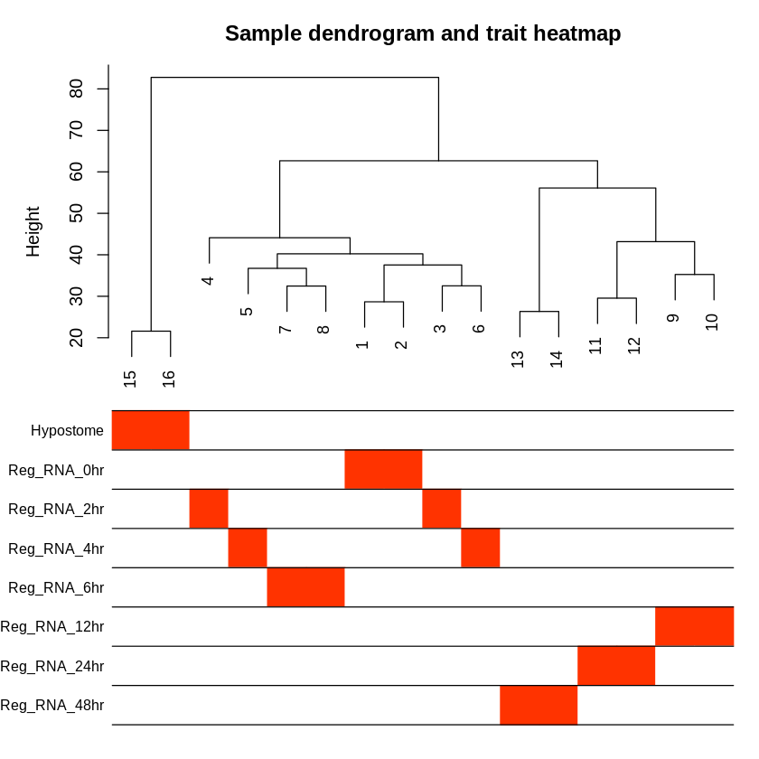

```r
f <-as.numeric(datTraits$sample_names_numeric)
# Re-cluster samples
sampleTree2 = hclust(dist(datExpr), method = "average")
# Convert traits to a color representation: white means low, red means high, grey means missing entry
traitColors = numbers2colors(datTraits, signed = FALSE);
# Plot the sample dendrogram and the colors underneath.
plotDendroAndColors(sampleTree2, traitColors,
                    groupLabels = names(datTraits),
                    main = "Sample dendrogram and trait heatmap")
```

```r
# define numbers of genes and samples
nGenes = ncol(datExpr);
nSamples = nrow(datExpr);
# recalculate MEs with color labels
MEs0 = moduleEigengenes(datExpr, moduleColors)$eigengenes
MEs = orderMEs(MEs0)
```

```r
names(MEs)
moduleTraitCor = cor(MEs, datTraits, use = "p");
moduleTraitPvalue = corPvalueStudent(moduleTraitCor, nSamples);
```

1. 'MEyellow3'

2. 'MElightcyan1'

3. 'MElightpink3'

4. 'MEblueviolet'

5. 'MEdarkviolet'

6. 'MEdarkolivegreen2'

7. 'MEsalmon'

8. 'MEdarkseagreen3'

9. 'MElightsteelblue'

10. 'MEorange'

11. 'MEmediumpurple3'

12. 'MEdarkorange'

13. 'MEhoneydew'

14. 'MEfirebrick3'

15. 'MEdarkgreen'

16. 'MElightslateblue'

17. 'MEsienna3'

18. 'MEblue2'

19. 'MEpink4'

20. 'MEdarkseagreen4'

21. 'MEnavajowhite1'

22. 'MEcoral2'

23. 'MEindianred3'

24. 'MEmagenta4'

25. 'MEmaroon'

26. 'MEivory'

27. 'MElightcyan'

28. 'MEmediumpurple2'

29. 'MEcoral'

30. 'MEfirebrick4'

31. 'MEgrey'

```r
#view the graph
textMatrix = paste(signif(moduleTraitCor, 2), "\n(",
                   signif(moduleTraitPvalue, 1), ")", sep = "");
dim(textMatrix) = dim(moduleTraitCor)
```

```r
moduleTraitCor
```

A matrix: 31 × 8 of type dbl

|  | Hypostome | Reg_RNA_0hr | Reg_RNA_2hr | Reg_RNA_4hr | Reg_RNA_6hr | Reg_RNA_12hr | Reg_RNA_24hr | Reg_RNA_48hr |
| --- | --- | --- | --- | --- | --- | --- | --- | --- |
| MEyellow3 | -0.05178606 | -0.18548176 | -0.25801722 | 0.3090091360 | 0.47195798 | -0.14297333 | -1.639219e-01 | 0.02121314 |
| MElightcyan1 | 0.08318969 | 0.22627088 | 0.38367639 | 0.0865021743 | 0.28016486 | -0.48018706 | -5.932287e-01 | 0.01361181 |
| MElightpink3 | -0.50487360 | 0.19540815 | 0.45380159 | -0.0498291901 | 0.36545888 | -0.21568525 | -3.939264e-01 | 0.14964583 |
| MEblueviolet | -0.52750718 | 0.14192037 | 0.43277786 | 0.4584083114 | 0.31386358 | -0.22409759 | -2.380481e-01 | -0.35731725 |
| MEdarkviolet | 0.18745303 | -0.06978205 | 0.30202516 | 0.5359898736 | 0.22186466 | -0.31702105 | -5.788269e-01 | -0.28170273 |
| MEdarkolivegreen2 | 0.90242338 | 0.08882371 | 0.04937424 | -0.0339085292 | -0.13534245 | -0.30483814 | -1.575461e-01 | -0.40898616 |
| MEsalmon | 0.61027021 | 0.24669382 | -0.13243822 | 0.0348069841 | -0.03236519 | -0.33456760 | 4.234525e-02 | -0.43474526 |
| MEdarkseagreen3 | 0.29406633 | 0.21840618 | 0.21692960 | 0.3403149470 | 0.25303088 | -0.62517579 | -1.360140e-01 | -0.56155816 |
| MElightsteelblue | -0.10606213 | 0.26487326 | 0.04342011 | 0.2681932131 | 0.13130084 | -0.27788875 | 2.933751e-01 | -0.61721162 |
| MEorange | -0.20005447 | -0.16345226 | -0.07686975 | 0.4652324480 | -0.18004835 | 0.16895822 | 1.393507e-01 | -0.15311651 |
| MEmediumpurple3 | -0.52105121 | 0.14365504 | 0.37572020 | 0.1848469710 | -0.20360206 | -0.05395336 | 4.304602e-01 | -0.35607575 |
| MEdarkorange | -0.46673794 | 0.31261470 | 0.32432331 | 0.4399450475 | -0.01663443 | -0.35061943 | 1.065767e-01 | -0.34946795 |
| MEhoneydew | -0.44282296 | 0.08524063 | 0.06940058 | 0.8395148187 | 0.03254242 | -0.40376311 | -8.394870e-02 | -0.09616366 |
| MEfirebrick3 | 0.67919252 | 0.04160328 | -0.01674460 | -0.7634690425 | 0.01058352 | -0.03127675 | 1.171203e-01 | -0.03700920 |
| MEdarkgreen | 0.44391313 | -0.33847736 | -0.46478218 | -0.2856241058 | -0.32750975 | 0.27726365 | 1.377553e-01 | 0.55746128 |
| MElightslateblue | -0.03391692 | -0.35614440 | -0.21765150 | -0.3043088244 | -0.12153416 | 0.14508207 | -1.659483e-02 | 0.90506857 |
| MEsienna3 | 0.51259441 | 0.05468973 | -0.12980806 | -0.0235774082 | -0.04099225 | -0.54745092 | -3.820605e-01 | 0.55660498 |
| MEblue2 | 0.87205861 | -0.15307557 | -0.33398192 | -0.2248806543 | -0.24096455 | -0.11780139 | -1.080343e-01 | 0.30667977 |
| MEpink4 | 0.37892618 | 0.16350367 | -0.49761397 | -0.1048167414 | -0.28993315 | -0.21883660 | 4.730720e-03 | 0.56403990 |
| MEdarkseagreen4 | -0.78480226 | -0.04101898 | 0.25897904 | -0.1002168986 | 0.06276535 | 0.58372272 | 4.792873e-02 | -0.02735771 |
| MEnavajowhite1 | -0.58852663 | -0.02959728 | 0.22873416 | -0.3449843942 | 0.17558973 | 0.16019919 | -9.589228e-02 | 0.49447751 |
| MEcoral2 | -0.36730761 | -0.45495737 | -0.08080273 | 0.1647940489 | 0.13548030 | 0.80247111 | 6.957718e-02 | -0.26925493 |
| MEindianred3 | 0.36846118 | -0.67502213 | -0.34407949 | 0.0005423105 | 0.01072073 | 0.59555984 | -8.419861e-02 | 0.12801616 |
| MEmagenta4 | -0.10413408 | -0.45918244 | -0.13746979 | -0.1262708757 | 0.13943815 | 0.81092954 | -2.945736e-01 | 0.17126311 |
| MEmaroon | 0.06325043 | 0.02667221 | -0.45107586 | -0.2560855774 | -0.19013667 | 0.29733446 | 4.951696e-01 | 0.01487144 |
| MEivory | -0.09103502 | -0.17466532 | -0.21383538 | -0.3001110322 | -0.21677448 | 0.73587427 | 4.893185e-01 | -0.22877158 |
| MElightcyan | -0.01833749 | -0.32884265 | -0.44224496 | -0.2646562524 | -0.27002728 | 0.67255708 | 3.363776e-01 | 0.31517396 |
| MEmediumpurple2 | -0.43122733 | -0.18198443 | -0.38329229 | 0.0949711698 | -0.32222534 | 0.22872104 | 3.853103e-01 | 0.60972689 |
| MEcoral | -0.73638329 | 0.06616307 | -0.06893612 | 0.0991278756 | -0.13713906 | 0.11861844 | 6.017440e-01 | 0.05680505 |
| MEfirebrick4 | -0.68661648 | -0.12717936 | -0.13016012 | -0.1249179899 | -0.07958988 | 0.57892311 | 4.786831e-01 | 0.09085757 |
| MEgrey | 0.07971995 | -0.12968762 | 0.48170600 | -0.6843422079 | 0.16875913 | 0.22567711 | -1.852777e-05 | -0.14181383 |

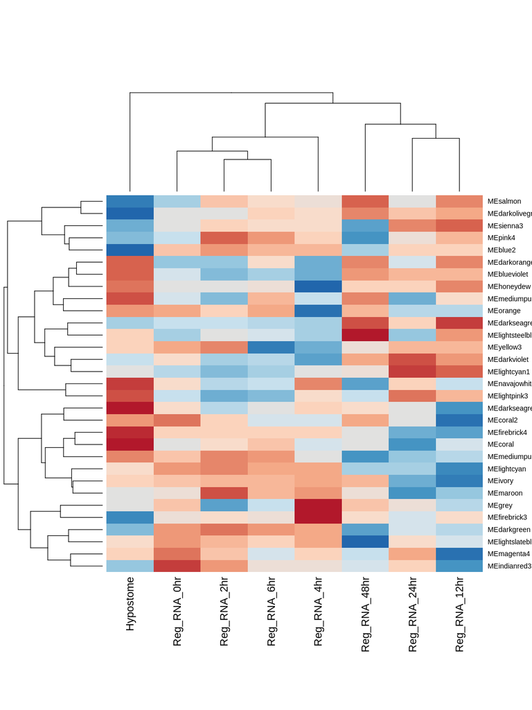

```r
#make the heatmap
heatmap(moduleTraitCor, colv=NAs,
        col= colorRampPalette(brewer.pal(8, "RdBu"))(28))
```

```r
# Opening the graphical device
# JPEG device
#pdf("Figure_021621_module_trait_justPvalues_v3.pdf" , width = 8, height = 12)


par(mar = c(20, 12, 6, 3) )
# Display the correlation values within a heatmap plot
labeledHeatmap(moduleTraitCor,
               xLabels = names(datTraits),
               yLabels = names(MEs),
               ySymbols = names(MEs),
               colorLabels = FALSE,
               colors = blueWhiteRed(50),
               textMatrix = signif(moduleTraitPvalue, 1),
               setStdMargins = FALSE,
               cex.text = 0.5,
               textAdj = c(0.5, 0.5),
               zlim = c(-1,1),
               main = paste("Module-trait relationships"))

# Closing the graphical device
#dev.off()
```

[output not shown]

**png:** 2

## 6. GO enrichment modules with topGO

```r
#import the trinotate go sheet
geneID2GO <- readMappings(file ="go_annotations.txt")
#geneNames <- names(geneID2GO)
```

```r
head(geneID2GO)
```

**$Sc4wPfr_1.g5785.**

1. 'GO:0000166'

2. 'GO:0001654'

3. 'GO:0001882'

4. 'GO:0001883'

5. 'GO:0003674'

6. 'GO:0005488'

7. 'GO:0005525'

8. 'GO:0005575'

9. 'GO:0006810'

10. 'GO:0006996'

11. 'GO:0007029'

12. 'GO:0007165'

13. 'GO:0007264'

14. 'GO:0007420'

15. 'GO:0007423'

16. 'GO:0008104'

17. 'GO:0008150'

18. 'GO:0009987'

19. 'GO:0015031'

20. 'GO:0015833'

21. 'GO:0016043'

22. 'GO:0017076'

23. 'GO:0019001'

24. 'GO:0019003'

25. 'GO:0031982'

26. 'GO:0031984'

27. 'GO:0032502'

28. 'GO:0032549'

29. 'GO:0032550'

30. 'GO:0032553'

31. 'GO:0032555'

32. 'GO:0032561'

33. 'GO:0033036'

34. 'GO:0034389'

35. 'GO:0035556'

36. 'GO:0035639'

37. 'GO:0036094'

38. 'GO:0042886'

39. 'GO:0043167'

40. 'GO:0043168'

41. 'GO:0043226'

42. 'GO:0043227'

43. 'GO:0043230'

44. 'GO:0044421'

45. 'GO:0044422'

46. 'GO:0044424'

47. 'GO:0044432'

48. 'GO:0044444'

49. 'GO:0044446'

50. 'GO:0044464'

51. 'GO:0044699'

52. 'GO:0044767'

53. 'GO:0045184'

54. 'GO:0048513'

55. 'GO:0048856'

56. 'GO:0050789'

57. 'GO:0050794'

58. 'GO:0051179'

59. 'GO:0051234'

60. 'GO:0065007'

61. 'GO:0070062'

62. 'GO:0071702'

63. 'GO:0071705'

64. 'GO:0071782'

65. 'GO:0071786'

66. 'GO:0071840'

67. 'GO:0097159'

68. 'GO:0097367'

69. 'GO:0098827'

70. 'GO:1901265'

71. 'GO:1901363'

72. 'GO:1903561'

**$Sc4wPfr_1.g5786.**

1. 'GO:0000139'

2. 'GO:0002063'

3. 'GO:0003002'

4. 'GO:0003674'

5. 'GO:0003824'

6. 'GO:0005488'

7. 'GO:0005575'

8. 'GO:0005576'

9. 'GO:0006022'

10. 'GO:0006023'

11. 'GO:0006024'

12. 'GO:0006082'

13. 'GO:0006790'

14. 'GO:0006807'

15. 'GO:0007389'

16. 'GO:0008150'

17. 'GO:0008152'

18. 'GO:0008194'

19. 'GO:0008376'

20. 'GO:0008589'

21. 'GO:0009058'

22. 'GO:0009059'

23. 'GO:0009605'

24. 'GO:0009653'

25. 'GO:0009887'

26. 'GO:0009954'

27. 'GO:0009966'

28. 'GO:0009967'

29. 'GO:0009987'

30. 'GO:0009991'

31. 'GO:0010646'

32. 'GO:0010647'

33. 'GO:0015020'

34. 'GO:0016020'

35. 'GO:0016021'

36. 'GO:0016740'

37. 'GO:0016757'

38. 'GO:0016758'

39. 'GO:0023051'

40. 'GO:0023056'

41. 'GO:0030203'

42. 'GO:0030204'

43. 'GO:0030206'

44. 'GO:0030278'

45. 'GO:0030279'

46. 'GO:0031090'

47. 'GO:0031224'

48. 'GO:0031667'

49. 'GO:0032501'

50. 'GO:0032502'

51. 'GO:0032580'

52. 'GO:0043167'

53. 'GO:0043169'

54. 'GO:0043170'

55. 'GO:0043436'

56. 'GO:0044237'

57. 'GO:0044249'

58. 'GO:0044272'

59. 'GO:0044281'

60. 'GO:0044422'

61. 'GO:0044424'

62. 'GO:0044425'

63. 'GO:0044431'

64. 'GO:0044444'

65. 'GO:0044446'

66. 'GO:0044464'

67. 'GO:0044699'

68. 'GO:0044707'

69. 'GO:0044710'

70. 'GO:0044711'

71. 'GO:0044763'

72. 'GO:0044767'

73. 'GO:0045880'

74. 'GO:0046872'

75. 'GO:0047238'

76. 'GO:0048468'

77. 'GO:0048513'

78. 'GO:0048518'

79. 'GO:0048519'

80. 'GO:0048522'

81. 'GO:0048583'

82. 'GO:0048584'

83. 'GO:0048856'

84. 'GO:0048869'

85. 'GO:0050510'

86. 'GO:0050789'

87. 'GO:0050794'

88. 'GO:0050896'

89. 'GO:0051216'

90. 'GO:0051239'

91. 'GO:0051241'

92. 'GO:0051923'

93. 'GO:0060349'

94. 'GO:0065007'

95. 'GO:0071704'

96. 'GO:0098588'

97. 'GO:1901135'

98. 'GO:1901137'

99. 'GO:1901564'

100. 'GO:1901566'

101. 'GO:1901576'

102. 'GO:1903510'

**$Sc4wPfr_1.g5788.**

1. 'GO:0000139'

2. 'GO:0002063'

3. 'GO:0003002'

4. 'GO:0003674'

5. 'GO:0003824'

6. 'GO:0005488'

7. 'GO:0005575'

8. 'GO:0005576'

9. 'GO:0006022'

10. 'GO:0006023'

11. 'GO:0006024'

12. 'GO:0006082'

13. 'GO:0006790'

14. 'GO:0006807'

15. 'GO:0007389'

16. 'GO:0008150'

17. 'GO:0008152'

18. 'GO:0008194'

19. 'GO:0008376'

20. 'GO:0008589'

21. 'GO:0009058'

22. 'GO:0009059'

23. 'GO:0009605'

24. 'GO:0009653'

25. 'GO:0009887'

26. 'GO:0009954'

27. 'GO:0009966'

28. 'GO:0009967'

29. 'GO:0009987'

30. 'GO:0009991'

31. 'GO:0010646'

32. 'GO:0010647'

33. 'GO:0015020'

34. 'GO:0016020'

35. 'GO:0016021'

36. 'GO:0016740'

37. 'GO:0016757'

38. 'GO:0016758'

39. 'GO:0023051'

40. 'GO:0023056'

41. 'GO:0030203'

42. 'GO:0030204'

43. 'GO:0030206'

44. 'GO:0030278'

45. 'GO:0030279'

46. 'GO:0031090'

47. 'GO:0031224'

48. 'GO:0031667'

49. 'GO:0032501'

50. 'GO:0032502'

51. 'GO:0032580'

52. 'GO:0043167'

53. 'GO:0043169'

54. 'GO:0043170'

55. 'GO:0043436'

56. 'GO:0044237'

57. 'GO:0044249'

58. 'GO:0044272'

59. 'GO:0044281'

60. 'GO:0044422'

61. 'GO:0044424'

62. 'GO:0044425'

63. 'GO:0044431'

64. 'GO:0044444'

65. 'GO:0044446'

66. 'GO:0044464'

67. 'GO:0044699'

68. 'GO:0044707'

69. 'GO:0044710'

70. 'GO:0044711'

71. 'GO:0044763'

72. 'GO:0044767'

73. 'GO:0045880'

74. 'GO:0046872'

75. 'GO:0047238'

76. 'GO:0048468'

77. 'GO:0048513'

78. 'GO:0048518'

79. 'GO:0048519'

80. 'GO:0048522'

81. 'GO:0048583'

82. 'GO:0048584'

83. 'GO:0048856'

84. 'GO:0048869'

85. 'GO:0050510'

86. 'GO:0050789'

87. 'GO:0050794'

88. 'GO:0050896'

89. 'GO:0051216'

90. 'GO:0051239'

91. 'GO:0051241'

92. 'GO:0051923'

93. 'GO:0060349'

94. 'GO:0065007'

95. 'GO:0071704'

96. 'GO:0098588'

97. 'GO:1901135'

98. 'GO:1901137'

99. 'GO:1901564'

100. 'GO:1901566'

101. 'GO:1901576'

102. 'GO:1903510'

**$Sc4wPfr_1.g5789.**

1. 'GO:0000038'

2. 'GO:0003674'

3. 'GO:0003824'

4. 'GO:0005575'

5. 'GO:0005783'

6. 'GO:0005789'

7. 'GO:0006082'

8. 'GO:0006629'

9. 'GO:0006631'

10. 'GO:0006633'

11. 'GO:0008150'

12. 'GO:0008152'

13. 'GO:0008610'

14. 'GO:0009058'

15. 'GO:0009987'

16. 'GO:0016020'

17. 'GO:0016021'

18. 'GO:0016053'

19. 'GO:0016829'

20. 'GO:0016835'

21. 'GO:0016836'

22. 'GO:0018812'

23. 'GO:0019752'

24. 'GO:0030497'

25. 'GO:0031224'

26. 'GO:0032787'

27. 'GO:0042761'

28. 'GO:0043226'

29. 'GO:0043227'

30. 'GO:0043229'

31. 'GO:0043231'

32. 'GO:0043436'

33. 'GO:0044237'

34. 'GO:0044238'

35. 'GO:0044249'

36. 'GO:0044255'

37. 'GO:0044281'

38. 'GO:0044283'

39. 'GO:0044422'

40. 'GO:0044424'

41. 'GO:0044425'

42. 'GO:0044432'

43. 'GO:0044444'

44. 'GO:0044446'

45. 'GO:0044464'

46. 'GO:0044699'

47. 'GO:0044710'

48. 'GO:0044711'

49. 'GO:0044763'

50. 'GO:0046394'

51. 'GO:0071704'

52. 'GO:0072330'

53. 'GO:1901576'

**$Sc4wPfr_1.g5791.**

1. 'GO:0003674'

2. 'GO:0005102'

3. 'GO:0005154'

4. 'GO:0005158'

5. 'GO:0005488'

6. 'GO:0005515'

7. 'GO:0005543'

8. 'GO:0005575'

9. 'GO:0005737'

10. 'GO:0006461'

11. 'GO:0006810'

12. 'GO:0006886'

13. 'GO:0006897'

14. 'GO:0006996'

15. 'GO:0008104'

16. 'GO:0008150'

17. 'GO:0008289'

18. 'GO:0009653'

19. 'GO:0009987'

20. 'GO:0010008'

21. 'GO:0015031'

22. 'GO:0015833'

23. 'GO:0016020'

24. 'GO:0016043'

25. 'GO:0016050'

26. 'GO:0016192'

27. 'GO:0016197'

28. 'GO:0016482'

29. 'GO:0019898'

30. 'GO:0022607'

31. 'GO:0030027'

32. 'GO:0030030'

33. 'GO:0030904'

34. 'GO:0030905'

35. 'GO:0031090'

36. 'GO:0031901'

37. 'GO:0031982'

38. 'GO:0032403'

39. 'GO:0032502'

40. 'GO:0032989'

41. 'GO:0032990'

42. 'GO:0032991'

43. 'GO:0033036'

44. 'GO:0034498'

45. 'GO:0035091'

46. 'GO:0042147'

47. 'GO:0042802'

48. 'GO:0042803'

49. 'GO:0042886'

50. 'GO:0042995'

51. 'GO:0043167'

52. 'GO:0043168'

53. 'GO:0043226'

54. 'GO:0043227'

55. 'GO:0043230'

56. 'GO:0043234'

57. 'GO:0043933'

58. 'GO:0044421'

59. 'GO:0044422'

60. 'GO:0044424'

61. 'GO:0044425'

62. 'GO:0044433'

63. 'GO:0044440'

64. 'GO:0044444'

65. 'GO:0044446'

66. 'GO:0044464'

67. 'GO:0044699'

68. 'GO:0044763'

69. 'GO:0044767'

70. 'GO:0044877'

71. 'GO:0045184'

72. 'GO:0046907'

73. 'GO:0046982'

74. 'GO:0046983'

75. 'GO:0048193'

76. 'GO:0048858'

77. 'GO:0048869'

78. 'GO:0051179'

79. 'GO:0051234'

80. 'GO:0051259'

81. 'GO:0051641'

82. 'GO:0051649'

83. 'GO:0065003'

84. 'GO:0070062'

85. 'GO:0070851'

86. 'GO:0071702'

87. 'GO:0071705'

88. 'GO:0071822'

89. 'GO:0071840'

90. 'GO:0072673'

91. 'GO:0097581'

92. 'GO:0098588'

93. 'GO:0098796'

94. 'GO:0098805'

95. 'GO:0120025'

96. 'GO:1903561'

97. 'GO:1990459'

98. 'GO:1990460'

**$Sc4wPfr_10.g18872.**

1. 'GO:0003674'

2. 'GO:0005096'

3. 'GO:0005488'

4. 'GO:0005575'

5. 'GO:0005737'

6. 'GO:0005912'

7. 'GO:0005924'

8. 'GO:0005925'

9. 'GO:0007165'

10. 'GO:0008047'

11. 'GO:0008150'

12. 'GO:0008289'

13. 'GO:0009966'

14. 'GO:0009987'

15. 'GO:0010646'

16. 'GO:0016020'

17. 'GO:0023051'

18. 'GO:0030054'

19. 'GO:0030055'

20. 'GO:0030234'

21. 'GO:0030695'

22. 'GO:0035023'

23. 'GO:0044424'

24. 'GO:0044464'

25. 'GO:0046578'

26. 'GO:0048583'

27. 'GO:0050789'

28. 'GO:0050794'

29. 'GO:0051056'

30. 'GO:0060589'

31. 'GO:0065007'

32. 'GO:0070161'

33. 'GO:0098772'

34. 'GO:1902531'

```r
myInterestingGenes <- as.character(wnt3_darkgreen_module$Gene_ID)
```

```r
head(myInterestingGenes)
```

1. 'Sc4wPfr_1.g5776'

2. 'Sc4wPfr_1.g5779'

3. 'Sc4wPfr_1.g5788'

4. 'Sc4wPfr_10.g18890'

5. 'Sc4wPfr_10.g18898'

6. 'Sc4wPfr_10.g18910'

```r
head(geneNames)
```

1. 'MSTRG.100.1'

2. 'MSTRG.100.2'

3. 'MSTRG.1000.1'

4. 'MSTRG.10000.2'

5. 'MSTRG.10004.1'

6. 'MSTRG.10007.1'

## 6.1 GO enrichment of Wnt3 module (darkgreen)

```r
geneNames_v2 <- paste0(geneNames, ".")
head(geneNames_v2)
```

1. 'MSTRG.100.1.'

2. 'MSTRG.100.2.'

3. 'MSTRG.1000.1.'

4. 'MSTRG.10000.2.'

5. 'MSTRG.10004.1.'

6. 'MSTRG.10007.1.'

```r
myInterestingGenes_v2 <- paste0(myInterestingGenes, ".")
head(myInterestingGenes_v2)
```

1. 'Sc4wPfr_1.g5776.'

2. 'Sc4wPfr_1.g5779.'

3. 'Sc4wPfr_1.g5788.'

4. 'Sc4wPfr_10.g18890.'

5. 'Sc4wPfr_10.g18898.'

6. 'Sc4wPfr_10.g18910.'

```r
#subset the genesNames by the transcript IDs in my red module
geneList <- factor(as.integer(geneNames_v2 %in% myInterestingGenes_v2))
names(geneList) <- geneNames_v2
head(geneList)
```

**MSTRG.100.1.**

0

**MSTRG.100.2.**

0

**MSTRG.1000.1.**

0

**MSTRG.10000.2.**

0

**MSTRG.10004.1.**

0

**MSTRG.10007.1.**

0

**Levels**:**

1. '0'

2. '1'

```r
#run the topGO function. Here I start with MF first.
GOdata <- new("topGOdata", ontology = "BP", allGenes = geneList,
                    annot = annFUN.gene2GO, gene2GO = geneID2GO)

results_go <- runTest(GOdata, algorithm="weight01", statistic="fisher")
```

```
Building most specific GOs .....

	( 11380 GO terms found. )


Build GO DAG topology ..........

	( 12094 GO terms and 27941 relations. )


Annotating nodes ...............

	( 11636 genes annotated to the GO terms. )


			 -- Weight01 Algorithm --

		 the algorithm is scoring 5842 nontrivial nodes
		 parameters:
			 test statistic: fisher


	 Level 19:	1 nodes to be scored	(0 eliminated genes)


	 Level 18:	1 nodes to be scored	(0 eliminated genes)


	 Level 17:	9 nodes to be scored	(12 eliminated genes)


	 Level 16:	25 nodes to be scored	(13 eliminated genes)


	 Level 15:	50 nodes to be scored	(65 eliminated genes)


	 Level 14:	98 nodes to be scored	(242 eliminated genes)


```

[output cut: 22 more lines]

```


	 Level 5:	479 nodes to be scored	(10438 eliminated genes)


	 Level 4:	245 nodes to be scored	(11004 eliminated genes)


	 Level 3:	111 nodes to be scored	(11272 eliminated genes)


	 Level 2:	23 nodes to be scored	(11439 eliminated genes)


	 Level 1:	1 nodes to be scored	(11615 eliminated genes)
```

```r
#retrieve the GO enrichment
goEnrichment_dark_green   <- GenTable(GOdata, Fisher = results_go, orderBy = "Fisher", topNodes =50, numChar = 10000)
```

```r
goEnrichment_dark_green
```

A data.frame: 50 × 6

|  | GO.ID <chr> | Term <chr> | Annotated <int> | Significant <int> | Expected <dbl> | Fisher <chr> |
| --- | --- | --- | --- | --- | --- | --- |
| 1 | GO:0006364 | rRNA processing | 134 | 27 | 10.20 | 5.1e-05 |
| 2 | GO:0051301 | cell division | 432 | 51 | 32.89 | 0.00042 |
| 3 | GO:0031345 | negative regulation of cell projection organization | 58 | 14 | 4.42 | 0.00043 |
| 4 | GO:0051387 | negative regulation of neurotrophin TRK receptor signaling pathway | 3 | 3 | 0.23 | 0.00044 |
| 5 | GO:0045892 | negative regulation of transcription, DNA-templated | 394 | 41 | 30.00 | 0.00137 |
| 6 | GO:0050774 | negative regulation of dendrite morphogenesis | 8 | 4 | 0.61 | 0.00182 |
| 7 | GO:0006826 | iron ion transport | 20 | 6 | 1.52 | 0.00283 |
| 8 | GO:0043408 | regulation of MAPK cascade | 363 | 23 | 27.64 | 0.00296 |
| 9 | GO:0051453 | regulation of intracellular pH | 72 | 11 | 5.48 | 0.00382 |
| 10 | GO:0007091 | metaphase/anaphase transition of mitotic cell cycle | 49 | 9 | 3.73 | 0.00388 |
| 11 | GO:0017183 | peptidyl-diphthamide biosynthetic process from peptidyl-histidine | 10 | 4 | 0.76 | 0.00483 |
| 12 | GO:0045165 | cell fate commitment | 129 | 20 | 9.82 | 0.00495 |
| 13 | GO:0061180 | mammary gland epithelium development | 19 | 7 | 1.45 | 0.00574 |
| 14 | GO:0033173 | calcineurin-NFAT signaling cascade | 9 | 4 | 0.69 | 0.00577 |
| 15 | GO:0019481 | L-alanine catabolic process, by transamination | 2 | 2 | 0.15 | 0.00579 |
| 16 | GO:0019265 | glycine biosynthetic process, by transamination of glyoxylate | 2 | 2 | 0.15 | 0.00579 |
| 17 | GO:0071493 | cellular response to UV-B | 2 | 2 | 0.15 | 0.00579 |
| 18 | GO:0060221 | retinal rod cell differentiation | 2 | 2 | 0.15 | 0.00579 |
| 19 | GO:1902065 | response to L-glutamate | 2 | 2 | 0.15 | 0.00579 |
| 20 | GO:0045585 | positive regulation of cytotoxic T cell differentiation | 2 | 2 | 0.15 | 0.00579 |
| 21 | GO:0051146 | striated muscle cell differentiation | 125 | 11 | 9.52 | 0.00580 |
| 22 | GO:0019532 | oxalate transport | 17 | 5 | 1.29 | 0.00723 |
| 23 | GO:1902358 | sulfate transmembrane transport | 17 | 5 | 1.29 | 0.00723 |
| 24 | GO:0010592 | positive regulation of lamellipodium assembly | 6 | 3 | 0.46 | 0.00739 |
| 25 | GO:0001975 | response to amphetamine | 6 | 3 | 0.46 | 0.00739 |
| 26 | GO:0006879 | cellular iron ion homeostasis | 25 | 6 | 1.90 | 0.00967 |
| 27 | GO:0071425 | hematopoietic stem cell proliferation | 7 | 3 | 0.53 | 0.01220 |
| 28 | GO:0042147 | retrograde transport, endosome to Golgi | 39 | 8 | 2.97 | 0.01477 |
| 29 | GO:0006298 | mismatch repair | 20 | 5 | 1.52 | 0.01497 |
| 30 | GO:0044260 | cellular macromolecule metabolic process | 6257 | 427 | 476.43 | 0.01609 |
| 31 | GO:0018996 | molting cycle, collagen and cuticulin-based cuticle | 6 | 3 | 0.46 | 0.01647 |
| 32 | GO:0048635 | negative regulation of muscle organ development | 13 | 3 | 0.99 | 0.01649 |
| 33 | GO:0019358 | nicotinate nucleotide salvage | 3 | 2 | 0.23 | 0.01649 |
| 34 | GO:0001994 | norepinephrine-epinephrine vasoconstriction involved in regulation of systemic arterial blood pressure | 3 | 2 | 0.23 | 0.01649 |
| 35 | GO:0000481 | maturation of 5S rRNA | 3 | 2 | 0.23 | 0.01649 |
| 36 | GO:0007198 | adenylate cyclase-inhibiting serotonin receptor signaling pathway | 3 | 2 | 0.23 | 0.01649 |
| 37 | GO:0009436 | glyoxylate catabolic process | 3 | 2 | 0.23 | 0.01649 |
| 38 | GO:0034316 | negative regulation of Arp2/3 complex-mediated actin nucleation | 3 | 2 | 0.23 | 0.01649 |
| 39 | GO:0043697 | cell dedifferentiation | 3 | 2 | 0.23 | 0.01649 |
| 40 | GO:1902731 | negative regulation of chondrocyte proliferation | 3 | 2 | 0.23 | 0.01649 |
| 41 | GO:0045200 | establishment of neuroblast polarity | 3 | 2 | 0.23 | 0.01649 |
| 42 | GO:0072034 | renal vesicle induction | 3 | 2 | 0.23 | 0.01649 |
| 43 | GO:1903052 | positive regulation of proteolysis involved in cellular protein catabolic process | 90 | 8 | 6.85 | 0.01652 |
| 44 | GO:0007202 | activation of phospholipase C activity | 14 | 4 | 1.07 | 0.01803 |
| 45 | GO:0046274 | lignin catabolic process | 8 | 3 | 0.61 | 0.01843 |
| 46 | GO:0006468 | protein phosphorylation | 898 | 67 | 68.38 | 0.01849 |
| 47 | GO:0009887 | animal organ morphogenesis | 625 | 57 | 47.59 | 0.02179 |
| 48 | GO:0030182 | neuron differentiation | 825 | 81 | 62.82 | 0.02507 |
| 49 | GO:0046849 | bone remodeling | 38 | 6 | 2.89 | 0.02604 |
| 50 | GO:0071236 | cellular response to antibiotic | 53 | 7 | 4.04 | 0.02605 |

```r
#drop enrichments that have a significant value of 5 or less
goEnrichment_darkgreen_dropped <- goEnrichment_dark_green %>% filter(Significant > 5 )
```

```r
goEnrichment_darkgreen_dropped
```

A data.frame: 20 × 6

| GO.ID <chr> | Term <chr> | Annotated <int> | Significant <int> | Expected <dbl> | Fisher <chr> |
| --- | --- | --- | --- | --- | --- |
| GO:0006364 | rRNA processing | 134 | 27 | 10.20 | 5.1e-05 |
| GO:0051301 | cell division | 432 | 51 | 32.89 | 0.00042 |
| GO:0031345 | negative regulation of cell projection organization | 58 | 14 | 4.42 | 0.00043 |
| GO:0045892 | negative regulation of transcription, DNA-templated | 394 | 41 | 30.00 | 0.00137 |
| GO:0006826 | iron ion transport | 20 | 6 | 1.52 | 0.00283 |
| GO:0043408 | regulation of MAPK cascade | 363 | 23 | 27.64 | 0.00296 |
| GO:0051453 | regulation of intracellular pH | 72 | 11 | 5.48 | 0.00382 |
| GO:0007091 | metaphase/anaphase transition of mitotic cell cycle | 49 | 9 | 3.73 | 0.00388 |
| GO:0045165 | cell fate commitment | 129 | 20 | 9.82 | 0.00495 |
| GO:0061180 | mammary gland epithelium development | 19 | 7 | 1.45 | 0.00574 |
| GO:0051146 | striated muscle cell differentiation | 125 | 11 | 9.52 | 0.00580 |
| GO:0006879 | cellular iron ion homeostasis | 25 | 6 | 1.90 | 0.00967 |
| GO:0042147 | retrograde transport, endosome to Golgi | 39 | 8 | 2.97 | 0.01477 |
| GO:0044260 | cellular macromolecule metabolic process | 6257 | 427 | 476.43 | 0.01609 |
| GO:1903052 | positive regulation of proteolysis involved in cellular protein catabolic process | 90 | 8 | 6.85 | 0.01652 |
| GO:0006468 | protein phosphorylation | 898 | 67 | 68.38 | 0.01849 |
| GO:0009887 | animal organ morphogenesis | 625 | 57 | 47.59 | 0.02179 |
| GO:0030182 | neuron differentiation | 825 | 81 | 62.82 | 0.02507 |
| GO:0046849 | bone remodeling | 38 | 6 | 2.89 | 0.02604 |
| GO:0071236 | cellular response to antibiotic | 53 | 7 | 4.04 | 0.02605 |

```r
#retrieve gene ids that are significantly enriched
myterms =goEnrichment_darkgreen_dropped$GO.ID
mygenes = genesInTerm(GOdata, myterms)

var=c()
for (i in 1:length(myterms))
{
myterm=myterms[i]
mygenesforterm= mygenes[myterm][[1]]
mygenesforterm=paste(mygenesforterm, collapse=',')
var[i]=paste("GOTerm",myterm,"genes-",mygenesforterm)
}

#write.table(var,"genetoGOmapping_wnt3_dropped_less5_032322.txt",sep="\t",quote=F)
```

```r
#subset GO enrichment table to include GO.ID, Term and Fisher and Significant

goEnrichment_darkgreen_dropped$Fisher <- as.numeric(goEnrichment_darkgreen_dropped$Fisher)
goEnrichment_darkgreen_dropped <- goEnrichment_darkgreen_dropped[goEnrichment_darkgreen_dropped$Fisher < 0.05,]
goEnrichment_darkgreen_dropped <- goEnrichment_darkgreen_dropped[,c("GO.ID","Term","Fisher", "Significant")]
goEnrichment_darkgreen_dropped
```

A data.frame: 20 × 4

|  | GO.ID <chr> | Term <chr> | Fisher <dbl> | Significant <int> |
| --- | --- | --- | --- | --- |
| 1 | GO:0006364 | rRNA processing | 0.000051 | 27 |
| 2 | GO:0051301 | cell division | 0.000420 | 51 |
| 3 | GO:0031345 | negative regulation of cell projection organization | 0.000430 | 14 |
| 4 | GO:0045892 | negative regulation of transcription, DNA-templated | 0.001370 | 41 |
| 5 | GO:0006826 | iron ion transport | 0.002830 | 6 |
| 6 | GO:0043408 | regulation of MAPK cascade | 0.002960 | 23 |
| 7 | GO:0051453 | regulation of intracellular pH | 0.003820 | 11 |
| 8 | GO:0007091 | metaphase/anaphase transition of mitotic cell cycle | 0.003880 | 9 |
| 9 | GO:0045165 | cell fate commitment | 0.004950 | 20 |
| 10 | GO:0061180 | mammary gland epithelium development | 0.005740 | 7 |
| 11 | GO:0051146 | striated muscle cell differentiation | 0.005800 | 11 |
| 12 | GO:0006879 | cellular iron ion homeostasis | 0.009670 | 6 |
| 13 | GO:0042147 | retrograde transport, endosome to Golgi | 0.014770 | 8 |
| 14 | GO:0044260 | cellular macromolecule metabolic process | 0.016090 | 427 |
| 15 | GO:1903052 | positive regulation of proteolysis involved in cellular protein catabolic process | 0.016520 | 8 |
| 16 | GO:0006468 | protein phosphorylation | 0.018490 | 67 |
| 17 | GO:0009887 | animal organ morphogenesis | 0.021790 | 57 |
| 18 | GO:0030182 | neuron differentiation | 0.025070 | 81 |
| 19 | GO:0046849 | bone remodeling | 0.026040 | 6 |
| 20 | GO:0071236 | cellular response to antibiotic | 0.026050 | 7 |

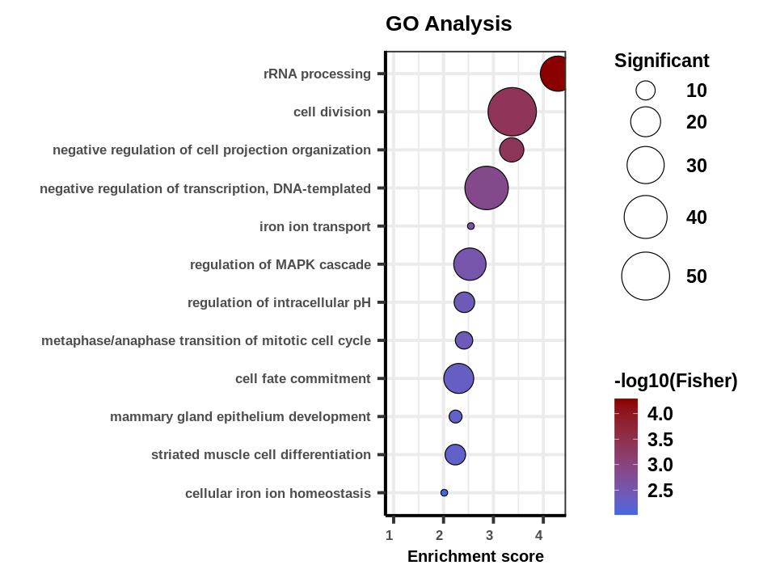

```r
#options(repr.plot.width=6, repr.plot.height=9)

#pdf("Figure_021621_goenrichment_darkgreen.pdf", width = 8, height =3 )

ntop <- 12
ggdata <- goEnrichment_darkgreen_dropped[1:ntop,]
ggdata$Term <- factor(ggdata$Term, levels = rev(ggdata$Term)) # fixes order
ggplot(ggdata,
  aes(x = Term, y = -log10(Fisher), size = Significant, fill = -log10(Fisher))) +

  expand_limits(y = 1) +
  geom_point(shape = 21) +
  #scale_size(range = c(2.5,12.5)) +
  scale_fill_continuous(low = 'royalblue', high = 'red4') +

  xlab('') + ylab('Enrichment score') +
  labs(
    title = 'GO Analysis')+
    scale_size(range = c(2, 16.5))+

  theme_bw(base_size = 24) +
  theme(
    legend.position = 'right',
    legend.background = element_rect(),
    plot.title = element_text(angle = 0, size = 16, face = 'bold', vjust = 1),
    plot.subtitle = element_text(angle = 0, size = 10, face = 'bold', vjust = 1),
    plot.caption = element_text(angle = 0, size = 12, face = 'bold', vjust = 1),

    axis.text.x = element_text(angle = 0, size = 10, face = 'bold', hjust = 1.10),
    axis.text.y = element_text(angle = 0, size = 10, face = 'bold', vjust = 0.5),
    axis.title = element_text(size = 12, face = 'bold'),
    axis.title.x = element_text(size = 12, face = 'bold'),
    axis.title.y = element_text(size = 12, face = 'bold'),
    axis.line = element_line(colour = 'black'),


    #Legend
    legend.key = element_blank(), # removes the border
    #legend.key.size = unit(1, "cm"), # Sets overall area/size of the legend
    legend.text = element_text(size = 14, face = "bold"), # Text size
    title = element_text(size = 14, face = "bold")) +

  coord_flip()

#dev.off()
```

```r
pdf("Figure_032322_goenrichment_darkgreen_v5.pdf", width = 8, height =6 )

ntop <- 12
ggdata <- goEnrichment_darkgreen_dropped[1:ntop,]
ggdata$Term <- factor(ggdata$Term, levels = rev(ggdata$Term)) # fixes order
ggplot(ggdata,
  aes(x = Term, y = -log10(Fisher), size = Significant, fill = -log10(Fisher))) +

  expand_limits(y = 1) +
  geom_point(shape = 21) +
  #scale_size(range = c(2.5,12.5)) +
  scale_fill_continuous(low = 'royalblue', high = 'red4') +

  xlab('') + ylab('Enrichment score') +
  labs(
    title = 'GO Analysis')+
    scale_size(range = c(2, 16.5))+


  theme_bw(base_size = 24) +
  theme(
    legend.position = 'right',
    legend.background = element_rect(),
    plot.title = element_text(angle = 0, size = 16, face = 'bold', vjust = 1),
    plot.subtitle = element_text(angle = 0, size = 10, face = 'bold', vjust = 1),
    plot.caption = element_text(angle = 0, size = 12, face = 'bold', vjust = 1),

    axis.text.x = element_text(angle = 0, size = 10, face = 'bold', hjust = 1.10),
    axis.text.y = element_text(angle = 0, size = 10, face = 'bold', vjust = 0.5),
    axis.title = element_text(size = 12, face = 'bold'),
    axis.title.x = element_text(size = 12, face = 'bold'),
    axis.title.y = element_text(size = 12, face = 'bold'),
    axis.line = element_line(colour = 'black'),


    #Legend
    legend.key = element_blank(), # removes the border
    #legend.key.size = unit(1, "cm"), # Sets overall area/size of the legend
    legend.text = element_text(size = 14, face = "bold"), # Text size
    title = element_text(size = 14, face = "bold")) +

  coord_flip()

dev.off()
```

**png:** 2

## 6.2 GO enrichment of Jun and Fos module (coral2)

```r
#fos_jun_coral2_module

#save the transcript
myInterestingGenes_coral2 = as.character(fos_jun_coral2_module$Gene_ID)

myInterestingGenes_v2_coral2 <- paste0(myInterestingGenes_coral2, ".")
head(myInterestingGenes_v2_coral2)
```

1. 'Sc4wPfr_1007.g33057.'

2. 'Sc4wPfr_1010.g13514.'

3. 'Sc4wPfr_1010.g13520.'

4. 'Sc4wPfr_1014.g28853.'

5. 'Sc4wPfr_1021.g3601.'

6. 'Sc4wPfr_1036.g374.'

```r
#subset the genesNames by the transcript IDs in my red module
geneList <- factor(as.integer(geneNames_v2 %in% myInterestingGenes_v2_coral2))
names(geneList) <- geneNames_v2
head(geneList)
```

**MSTRG.100.1.**

0

**MSTRG.100.2.**

0

**MSTRG.1000.1.**

0

**MSTRG.10000.2.**

0

**MSTRG.10004.1.**

0

**MSTRG.10007.1.**

0

**Levels**:**

1. '0'

2. '1'

```r
#run the topGO function
GOdata <- new("topGOdata", ontology = "BP", allGenes = geneList,
                    annot = annFUN.gene2GO, gene2GO = geneID2GO)

results_go <- runTest(GOdata, algorithm="weight01", statistic="fisher")
```

```
Building most specific GOs .....

	( 11380 GO terms found. )


Build GO DAG topology ..........

	( 12094 GO terms and 27941 relations. )


Annotating nodes ...............

	( 11636 genes annotated to the GO terms. )


			 -- Weight01 Algorithm --

		 the algorithm is scoring 3948 nontrivial nodes
		 parameters:
			 test statistic: fisher


	 Level 17:	2 nodes to be scored	(0 eliminated genes)


	 Level 16:	9 nodes to be scored	(0 eliminated genes)


	 Level 15:	28 nodes to be scored	(28 eliminated genes)


	 Level 14:	57 nodes to be scored	(127 eliminated genes)


	 Level 13:	102 nodes to be scored	(327 eliminated genes)


	 Level 12:	147 nodes to be scored	(942 eliminated genes)


```

[output cut: 16 more lines]

```


	 Level 5:	396 nodes to be scored	(10295 eliminated genes)


	 Level 4:	218 nodes to be scored	(10949 eliminated genes)


	 Level 3:	104 nodes to be scored	(11252 eliminated genes)


	 Level 2:	22 nodes to be scored	(11432 eliminated genes)


	 Level 1:	1 nodes to be scored	(11614 eliminated genes)
```

```r
#retrieve the GO enrichment
goEnrichment   <- GenTable(GOdata, Fisher = results_go, orderBy = "Fisher", topNodes = 50, numChar = 10000)
```

```r
#drop enrichments that have a significant value of 5 or less
goEnrichment_dropped <- goEnrichment %>% filter(Significant > 5 )
```

```r
#get genes that are significantly enriched
myterms =goEnrichment_dropped$GO.ID
mygenes = genesInTerm(GOdata, myterms)

var=c()
for (i in 1:length(myterms))
{
myterm=myterms[i]
mygenesforterm= mygenes[myterm][[1]]
mygenesforterm=paste(mygenesforterm, collapse=',')
var[i]=paste("GOTerm",myterm,"genes-",mygenesforterm)
}

write.table(var,"genetoGOmapping_coral2_dropped_less5_032322.txt",sep="\t",quote=F)
```

```r
#lets graph the GO enrichment
goEnrichment_dropped$Fisher <- as.numeric(goEnrichment_dropped$Fisher)
goEnrichment_dropped <- goEnrichment_dropped[goEnrichment_dropped$Fisher < 0.05,] # filter terms for Fisher p<0.05
goEnrichment_dropped <- goEnrichment_dropped[,c("GO.ID","Term","Fisher", "Significant")]
goEnrichment_dropped
```

A data.frame: 12 × 4

|  | GO.ID <chr> | Term <chr> | Fisher <dbl> | Significant <int> |
| --- | --- | --- | --- | --- |
| 1 | GO:0000122 | negative regulation of transcription by RNA polymerase II | 0.00013 | 15 |
| 2 | GO:0030336 | negative regulation of cell migration | 0.00073 | 8 |
| 3 | GO:0030307 | positive regulation of cell growth | 0.00137 | 7 |
| 4 | GO:0032496 | response to lipopolysaccharide | 0.00196 | 10 |
| 5 | GO:0007173 | epidermal growth factor receptor signaling pathway | 0.00352 | 7 |
| 6 | GO:0008543 | fibroblast growth factor receptor signaling pathway | 0.00389 | 7 |
| 7 | GO:0050792 | regulation of viral process | 0.00421 | 7 |
| 8 | GO:0042127 | regulation of cell proliferation | 0.00561 | 25 |
| 9 | GO:0044344 | cellular response to fibroblast growth factor stimulus | 0.00739 | 9 |
| 10 | GO:1901652 | response to peptide | 0.00790 | 18 |
| 11 | GO:0032870 | cellular response to hormone stimulus | 0.00797 | 20 |
| 12 | GO:0048011 | neurotrophin TRK receptor signaling pathway | 0.00894 | 6 |

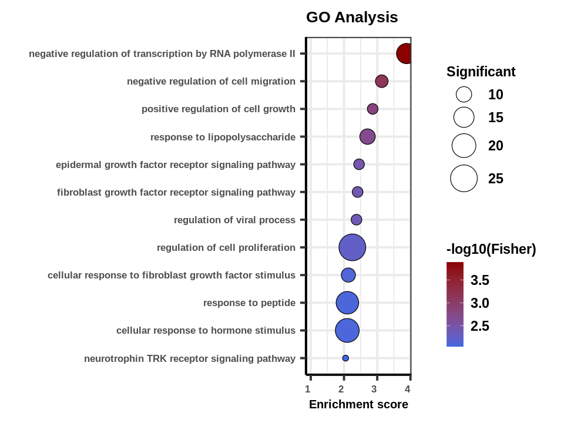

```r
options(repr.plot.width=8, repr.plot.height=6)

#pdf("Figure_031422_goenrichment_coral2_v3_width.pdf", width = 9.4, height =6)


ntop <- 12
ggdata <- goEnrichment_dropped[1:ntop,]
ggdata$Term <- factor(ggdata$Term, levels = rev(ggdata$Term)) # fixes order
ggplot(ggdata,
  aes(x = Term, y = -log10(Fisher), size = Significant, fill = -log10(Fisher))) +

  expand_limits(y = 1) +
  geom_point(shape = 21) +
  scale_size(range = c(2.5,12.5)) +
  scale_fill_continuous(low = 'royalblue', high = 'red4') +

  xlab('') + ylab('Enrichment score') +
  labs(
    title = 'GO Analysis')+
  theme_bw(base_size = 24) +
  theme(
    legend.position = 'right',
    legend.background = element_rect(),
    plot.title = element_text(angle = 0, size = 16, face = 'bold', vjust = 1),
    plot.subtitle = element_text(angle = 0, size = 10, face = 'bold', vjust = 1),
    plot.caption = element_text(angle = 0, size = 12, face = 'bold', vjust = 1),

    axis.text.x = element_text(angle = 0, size = 10, face = 'bold', hjust = 1.10),
    axis.text.y = element_text(angle = 0, size = 10, face = 'bold', vjust = 0.5),
    axis.title = element_text(size = 12, face = 'bold'),
    axis.title.x = element_text(size = 12, face = 'bold'),
    axis.title.y = element_text(size = 12, face = 'bold'),
    axis.line = element_line(colour = 'black'),

    #Legend
    legend.key = element_blank(), # removes the border
    #legend.key.size = unit(1, "cm"), # Sets overall area/size of the legend
    legend.text = element_text(size = 14, face = "bold"), # Text size
    title = element_text(size = 14, face = "bold")) +


  coord_flip()

#dev.off()
```

```r
pdf("Figure_032322_goenrichment_coral2_v4_width.pdf", width = 8.4, height =6)


ntop <- 12
ggdata <- goEnrichment_dropped[1:ntop,]
ggdata$Term <- factor(ggdata$Term, levels = rev(ggdata$Term)) # fixes order
ggplot(ggdata,
  aes(x = Term, y = -log10(Fisher), size = Significant, fill = -log10(Fisher))) +

  expand_limits(y = 1) +
  geom_point(shape = 21) +
  scale_size(range = c(2.5,12.5)) +
  scale_fill_continuous(low = 'royalblue', high = 'red4') +

  xlab('') + ylab('Enrichment score') +
  labs(
    title = 'GO Analysis')+
  theme_bw(base_size = 24) +
  theme(
    legend.position = 'right',
    legend.background = element_rect(),
    plot.title = element_text(angle = 0, size = 16, face = 'bold', vjust = 1),
    plot.subtitle = element_text(angle = 0, size = 10, face = 'bold', vjust = 1),
    plot.caption = element_text(angle = 0, size = 12, face = 'bold', vjust = 1),

    axis.text.x = element_text(angle = 0, size = 10, face = 'bold', hjust = 1.10),
    axis.text.y = element_text(angle = 0, size = 10, face = 'bold', vjust = 0.5),
    axis.title = element_text(size = 12, face = 'bold'),
    axis.title.x = element_text(size = 12, face = 'bold'),
    axis.title.y = element_text(size = 12, face = 'bold'),
    axis.line = element_line(colour = 'black'),

    #Legend
    legend.key = element_blank(), # removes the border
    #legend.key.size = unit(1, "cm"), # Sets overall area/size of the legend
    legend.text = element_text(size = 14, face = "bold"), # Text size
    title = element_text(size = 14, face = "bold")) +


  coord_flip()

dev.off()
```

**png:** 2

## 7. Network Visualization of Wnt3 module

```r
# I will recalculate topological overlap with the same power used to make the network
TOM_visnet_power18 = TOMsimilarityFromExpr(datExpr, power = 18)
```

```
TOM calculation: adjacency..
..will use 22 parallel threads.
 Fraction of slow calculations: 0.000000
..connectivity..
..matrix multiplication (system BLAS)..
..normalization..
..done.
```

```r
# select module
module = "darkgreen"
# select module probes
genes = colnames(datExpr)
inModule = moduleColors==module
modProbes = genes[inModule]
modTOM = TOM_visnet_power18[inModule, inModule]
dimnames(modTOM) = list(modProbes, modProbes)
```

```r
modTOM
```

A matrix: 1507 × 1507 of type dbl

[output not shown]

```r
vis.df = exportNetworkToVisANT(modTOM,
                           file = paste("darkgreen_", module, "top_0.05.txt", sep=""),
                            weighted = TRUE,
                            threshold = 0.09,
                            probeToGene = data.frame(modProbes, modProbes))
```

```r
vis.df
```

A data.frame: 66555 × 5

| from <chr> | to <chr> | direction <dbl> | method <chr> | weight <dbl> |
| --- | --- | --- | --- | --- |
| Sc4wPfr_1.g5776 | Sc4wPfr_475.1.g23421 | 0 | M0039 | 0.12287891 |
| Sc4wPfr_1.g5788 | Sc4wPfr_1007.g33054 | 0 | M0039 | 0.10259453 |
| Sc4wPfr_1.g5788 | Sc4wPfr_104.g15038 | 0 | M0039 | 0.10178402 |
| Sc4wPfr_1.g5788 | Sc4wPfr_107.1.g20598 | 0 | M0039 | 0.11498471 |
| Sc4wPfr_1.g5788 | Sc4wPfr_107.1.g20653 | 0 | M0039 | 0.11405731 |
| Sc4wPfr_1.g5788 | Sc4wPfr_1163.g25199 | 0 | M0039 | 0.09031510 |
| Sc4wPfr_1.g5788 | Sc4wPfr_134.g20071 | 0 | M0039 | 0.09347096 |
| Sc4wPfr_1.g5788 | Sc4wPfr_134.g20080 | 0 | M0039 | 0.09054090 |
| Sc4wPfr_1.g5788 | Sc4wPfr_1362.g13669 | 0 | M0039 | 0.09689176 |
| Sc4wPfr_1.g5788 | Sc4wPfr_1416.g33254 | 0 | M0039 | 0.13698274 |
| Sc4wPfr_1.g5788 | Sc4wPfr_144.1.g11736 | 0 | M0039 | 0.09726643 |
| Sc4wPfr_1.g5788 | Sc4wPfr_1463.g9577 | 0 | M0039 | 0.09422552 |
| Sc4wPfr_1.g5788 | Sc4wPfr_153.g25508 | 0 | M0039 | 0.09610191 |
| Sc4wPfr_1.g5788 | Sc4wPfr_153.g25509 | 0 | M0039 | 0.10652471 |
| Sc4wPfr_1.g5788 | Sc4wPfr_166.1.g33693 | 0 | M0039 | 0.10379357 |
| Sc4wPfr_1.g5788 | Sc4wPfr_169.g29161 | 0 | M0039 | 0.12810749 |
| Sc4wPfr_1.g5788 | Sc4wPfr_175.1.g31531 | 0 | M0039 | 0.09439680 |
| Sc4wPfr_1.g5788 | Sc4wPfr_177.1.g6128 | 0 | M0039 | 0.12120487 |
| Sc4wPfr_1.g5788 | Sc4wPfr_188.g2082 | 0 | M0039 | 0.09508961 |
| Sc4wPfr_1.g5788 | Sc4wPfr_2009.g19366 | 0 | M0039 | 0.12569394 |
| Sc4wPfr_1.g5788 | Sc4wPfr_206.g8664 | 0 | M0039 | 0.09324259 |
| Sc4wPfr_1.g5788 | Sc4wPfr_2074.g13194 | 0 | M0039 | 0.09052233 |
| Sc4wPfr_1.g5788 | Sc4wPfr_224.1.g33453 | 0 | M0039 | 0.11124264 |
| Sc4wPfr_1.g5788 | Sc4wPfr_224.g18119 | 0 | M0039 | 0.09821441 |
| Sc4wPfr_1.g5788 | Sc4wPfr_240.g3657 | 0 | M0039 | 0.09519250 |
| Sc4wPfr_1.g5788 | Sc4wPfr_25.1.g8867 | 0 | M0039 | 0.10662849 |
| Sc4wPfr_1.g5788 | Sc4wPfr_250.g16037 | 0 | M0039 | 0.09054702 |
| Sc4wPfr_1.g5788 | Sc4wPfr_27.g12223 | 0 | M0039 | 0.11475229 |
| Sc4wPfr_1.g5788 | Sc4wPfr_272.g11395 | 0 | M0039 | 0.09300526 |
| Sc4wPfr_1.g5788 | Sc4wPfr_276.g27803 | 0 | M0039 | 0.10038875 |
| ⋮ | ⋮ | ⋮ | ⋮ | ⋮ |
| Sc4wPfr_952.1.g9520 | Sc4wPfr_958.g18796 | 0 | M0039 | 0.09258927 |
| Sc4wPfr_952.1.g9520 | Sc4wPfr_96.g11933 | 0 | M0039 | 0.10915861 |
| Sc4wPfr_952.1.g9520 | Sc4wPfr_963.g15315 | 0 | M0039 | 0.13367201 |
| Sc4wPfr_952.1.g9520 | Sc4wPfr_97.g23 | 0 | M0039 | 0.09327764 |
| Sc4wPfr_952.1.g9520 | Sc4wPfr_975.g7262 | 0 | M0039 | 0.12707963 |
| Sc4wPfr_952.1.g9520 | Sc4wPfr_977.g21610 | 0 | M0039 | 0.09063318 |
| Sc4wPfr_952.1.g9520 | Sc4wPfr_98.g2700 | 0 | M0039 | 0.13325715 |
| Sc4wPfr_954.g27076 | Sc4wPfr_958.g18785 | 0 | M0039 | 0.09983430 |
| Sc4wPfr_954.g27076 | Sc4wPfr_98.g2700 | 0 | M0039 | 0.11264459 |
| Sc4wPfr_954.g27090 | Sc4wPfr_958.g18785 | 0 | M0039 | 0.10640334 |
| Sc4wPfr_957.g32683 | Sc4wPfr_958.g18785 | 0 | M0039 | 0.10635120 |
| Sc4wPfr_957.g32683 | Sc4wPfr_975.g7262 | 0 | M0039 | 0.10714611 |
| Sc4wPfr_958.g18785 | Sc4wPfr_96.g11933 | 0 | M0039 | 0.10590258 |
| Sc4wPfr_958.g18785 | Sc4wPfr_963.g15315 | 0 | M0039 | 0.10893009 |
| Sc4wPfr_958.g18785 | Sc4wPfr_97.g23 | 0 | M0039 | 0.09585083 |
| Sc4wPfr_958.g18785 | Sc4wPfr_975.g7262 | 0 | M0039 | 0.15347902 |
| Sc4wPfr_958.g18785 | Sc4wPfr_975.g7265 | 0 | M0039 | 0.09900561 |
| Sc4wPfr_958.g18785 | Sc4wPfr_975.g7276 | 0 | M0039 | 0.09358929 |
| Sc4wPfr_958.g18785 | Sc4wPfr_977.g21610 | 0 | M0039 | 0.11753029 |
| Sc4wPfr_958.g18785 | Sc4wPfr_98.g2700 | 0 | M0039 | 0.17520116 |
| Sc4wPfr_958.g18785 | Sc4wPfr_98.g2717 | 0 | M0039 | 0.10512681 |
| Sc4wPfr_958.g18785 | Sc4wPfr_999.g13406 | 0 | M0039 | 0.11658185 |
| Sc4wPfr_96.g11933 | Sc4wPfr_975.g7262 | 0 | M0039 | 0.13792698 |
| Sc4wPfr_963.g15315 | Sc4wPfr_975.g7262 | 0 | M0039 | 0.11893577 |
| Sc4wPfr_975.g7258 | Sc4wPfr_98.g2700 | 0 | M0039 | 0.09634821 |
| Sc4wPfr_975.g7262 | Sc4wPfr_975.g7276 | 0 | M0039 | 0.12671245 |
| Sc4wPfr_975.g7262 | Sc4wPfr_977.g21610 | 0 | M0039 | 0.10173987 |
| Sc4wPfr_975.g7262 | Sc4wPfr_98.g2700 | 0 | M0039 | 0.10578276 |
| Sc4wPfr_975.g7262 | Sc4wPfr_983.g32896 | 0 | M0039 | 0.10224379 |
| Sc4wPfr_98.g2700 | Sc4wPfr_999.g13406 | 0 | M0039 | 0.09579814 |

```r
#subset all edges connected with wnt3
vis.df.wnt3 <- vis.df[vis.df$from=="Sc4wPfr_399.g28064" | vis.df$to=="Sc4wPfr_399.g28064",]
```

```r
vis.df.wnt3.filtered <-  filter(vis.df.wnt3, weight > 0.1)
```

```r
vis.df.wnt3.filtered
```

A data.frame: 26 × 5

| from <chr> | to <chr> | direction <dbl> | method <chr> | weight <dbl> |
| --- | --- | --- | --- | --- |
| Sc4wPfr_1091.g16434 | Sc4wPfr_399.g28064 | 0 | M0039 | 0.1019878 |
| Sc4wPfr_1214.g29750 | Sc4wPfr_399.g28064 | 0 | M0039 | 0.1170357 |
| Sc4wPfr_138.g13929 | Sc4wPfr_399.g28064 | 0 | M0039 | 0.1160475 |
| Sc4wPfr_1515.g11091 | Sc4wPfr_399.g28064 | 0 | M0039 | 0.1242858 |
| Sc4wPfr_166.1.g33693 | Sc4wPfr_399.g28064 | 0 | M0039 | 0.1098926 |
| Sc4wPfr_17.g15897 | Sc4wPfr_399.g28064 | 0 | M0039 | 0.1060051 |
| Sc4wPfr_200.1.g28094 | Sc4wPfr_399.g28064 | 0 | M0039 | 0.1193701 |
| Sc4wPfr_2009.g19366 | Sc4wPfr_399.g28064 | 0 | M0039 | 0.1157165 |
| Sc4wPfr_224.g18119 | Sc4wPfr_399.g28064 | 0 | M0039 | 0.1381862 |
| Sc4wPfr_226.1.g26840 | Sc4wPfr_399.g28064 | 0 | M0039 | 0.1007633 |
| Sc4wPfr_272.g11395 | Sc4wPfr_399.g28064 | 0 | M0039 | 0.1031992 |
| Sc4wPfr_396.g3034 | Sc4wPfr_399.g28064 | 0 | M0039 | 0.1016413 |
| Sc4wPfr_399.g28064 | Sc4wPfr_463.g30865 | 0 | M0039 | 0.1156821 |
| Sc4wPfr_399.g28064 | Sc4wPfr_482.g19119 | 0 | M0039 | 0.1134382 |
| Sc4wPfr_399.g28064 | Sc4wPfr_493.g3156 | 0 | M0039 | 0.1454618 |
| Sc4wPfr_399.g28064 | Sc4wPfr_501.g11117 | 0 | M0039 | 0.1272337 |
| Sc4wPfr_399.g28064 | Sc4wPfr_504.g10336 | 0 | M0039 | 0.1573481 |
| Sc4wPfr_399.g28064 | Sc4wPfr_536.g2771 | 0 | M0039 | 0.1453896 |
| Sc4wPfr_399.g28064 | Sc4wPfr_569.1.g4036 | 0 | M0039 | 0.1067826 |
| Sc4wPfr_399.g28064 | Sc4wPfr_569.g11120 | 0 | M0039 | 0.1107502 |
| Sc4wPfr_399.g28064 | Sc4wPfr_59.2.g12459 | 0 | M0039 | 0.1166539 |
| Sc4wPfr_399.g28064 | Sc4wPfr_667.g19531 | 0 | M0039 | 0.1448535 |
| Sc4wPfr_399.g28064 | Sc4wPfr_68.g2322 | 0 | M0039 | 0.1084152 |
| Sc4wPfr_399.g28064 | Sc4wPfr_68.g2362 | 0 | M0039 | 0.1267463 |
| Sc4wPfr_399.g28064 | Sc4wPfr_691.g31399 | 0 | M0039 | 0.1061267 |
| Sc4wPfr_399.g28064 | Sc4wPfr_839.g4003 | 0 | M0039 | 0.1021188 |

```r
#write.csv(vis.df.wnt3.filtered, file="vis.df.wnt3.filtered.08.011321.csv")
```

```r
vis.df.wnt3.filtered.08 <- read_excel("vis.df.wnt3.filtered.1.wnt3.xlsx")
```

```r
head(vis.df.wnt3.filtered.08)
```

A tibble: 6 × 1

| Gene_ID <chr> |
| --- |
| Sc4wPfr_1091.g16434 |
| Sc4wPfr_1214.g29750 |
| Sc4wPfr_138.g13929 |
| Sc4wPfr_1515.g11091 |
| Sc4wPfr_166.1.g33693 |
| Sc4wPfr_17.g15897 |

```r
vis.df.wnt3.filtered_network <- as.data.frame(vis.df.wnt3.filtered.08$Gene_ID)

names(vis.df.wnt3.filtered_network)[1]<- "gene"
#head(sig_filtered_upr_redmodule_network_2)

vis.df.wnt3.filtered_network_vector <- as.vector(vis.df.wnt3.filtered_network)
head(vis.df.wnt3.filtered_network_vector)
```

A data.frame: 6 × 1

|  | gene <chr> |
| --- | --- |
| 1 | Sc4wPfr_1091.g16434 |
| 2 | Sc4wPfr_1214.g29750 |
| 3 | Sc4wPfr_138.g13929 |
| 4 | Sc4wPfr_1515.g11091 |
| 5 | Sc4wPfr_166.1.g33693 |
| 6 | Sc4wPfr_17.g15897 |

```r
select = colnames(modTOM) %in% vis.df.wnt3.filtered_network_vector$gene

selectTOM = modTOM[select, select]

vis_handpicked = exportNetworkToVisANT(selectTOM,
                            #file = paste("red_", module, "top_expressed.txt", sep=""),
                            weighted = TRUE,
                            threshold = 0.0,
                            probeToGene = data.frame(vis.df.wnt3.filtered_network$gene, vis.df.wnt3.filtered_network$gene))
```

```r
head(vis_handpicked)
```

A data.frame: 6 × 5

|  | from <chr> | to <chr> | direction <dbl> | method <chr> | weight <dbl> |
| --- | --- | --- | --- | --- | --- |
| 1 | Sc4wPfr_1091.g16434 | Sc4wPfr_1214.g29750 | 0 | M0039 | 0.11178418 |
| 2 | Sc4wPfr_1091.g16434 | Sc4wPfr_138.g13929 | 0 | M0039 | 0.10485779 |
| 3 | Sc4wPfr_1091.g16434 | Sc4wPfr_1515.g11091 | 0 | M0039 | 0.14054234 |
| 4 | Sc4wPfr_1091.g16434 | Sc4wPfr_166.1.g33693 | 0 | M0039 | 0.07619889 |
| 5 | Sc4wPfr_1091.g16434 | Sc4wPfr_17.g15897 | 0 | M0039 | 0.06976927 |
| 6 | Sc4wPfr_1091.g16434 | Sc4wPfr_200.1.g28094 | 0 | M0039 | 0.09814296 |

```r
my_genes_df_v1$combined[my_genes_df_v1$combined %in% wnt3_darkgreen_module.vis.df.wnt3.filtered.05_annot$Gene_ID]
```

1. 'Sc4wPfr_624.g29781'

2. 'Sc4wPfr_305.g4616'

3. 'Sc4wPfr_691.g31399'

4. 'Sc4wPfr_399.g28064'

5. 'Sc4wPfr_1214.g29750'

6. 'Sc4wPfr_440.g6790'

7. 'Sc4wPfr_68.g2322'

8. 'Sc4wPfr_224.1.g33373'

```r
wnt3_darkgreen_module.vis.df.wnt3.filtered.05_annot_ADDED <- read_excel("wnt3_darkgreen_module.vis.df.wnt3.filtered.05_annot_ADDED.xlsx")
```

```r
# create graph from data frames
ggraph_test = graph_from_data_frame(vis_handpicked, directed = FALSE, wnt3_darkgreen_module.vis.df.wnt3.filtered.08_annot)

options(repr.plot.width=10, repr.plot.height=10)

lay = create_layout(ggraph_test, layout = "kk")
```

```r
ggraph_test
```

```
IGRAPH bf4cf80 UNW- 27 351 --
+ attr: name (v/c), Description (v/c), GO_Names (v/c), direction (e/n),
| method (e/c), weight (e/n)
+ edges from bf4cf80 (vertex names):
 [1] Sc4wPfr_1091.g16434--Sc4wPfr_1214.g29750
 [2] Sc4wPfr_1091.g16434--Sc4wPfr_138.g13929
 [3] Sc4wPfr_1091.g16434--Sc4wPfr_1515.g11091
 [4] Sc4wPfr_1091.g16434--Sc4wPfr_166.1.g33693
 [5] Sc4wPfr_1091.g16434--Sc4wPfr_17.g15897
 [6] Sc4wPfr_1091.g16434--Sc4wPfr_200.1.g28094
 [7] Sc4wPfr_1091.g16434--Sc4wPfr_2009.g19366
+ ... omitted several edges
```

```r
lay
```

A layout_tbl_graph: 27 × 8

| x <dbl> | y <dbl> | name <chr> | Description <chr> | GO_Names <chr> | .ggraph.orig_index <int> | circular <lgl> | .ggraph.index <int> |
| --- | --- | --- | --- | --- | --- | --- | --- |
| -0.5006425 | 1.1496251 | Sc4wPfr_1091.g16434 | E3_ubiquitin-_ligase_PDZRN3 | F:protein_binding | 1 | FALSE | 1 |
| -0.2564378 | -2.2559886 | Sc4wPfr_1214.g29750 | Wnt-2b | F:receptor_binding;_C:extracellular_region;_P:multicellular_organism_development;_P:Wnt_signaling_pathway | 2 | FALSE | 2 |
| 1.6000927 | 1.1406711 | Sc4wPfr_138.g13929 | cytosolic_purine_5_-nucleotidase_isoform_X1 | F:calcium_ion_binding | 3 | FALSE | 3 |
| 0.7919075 | 0.5989612 | Sc4wPfr_1515.g11091 | tribbles_homolog_2 | F:protein_kinase_activity;_F:ATP_binding;_P:protein_phosphorylation | 4 | FALSE | 4 |
| -1.7372465 | -0.3660616 | Sc4wPfr_166.1.g33693 | bactericidal_permeability-increasing_-like | F:lipopolysaccharide_binding;_P:immune_response;_P:defense_response_to_Gram-negative_bacterium | 5 | FALSE | 5 |
| 0.3490587 | -0.2649658 | Sc4wPfr_17.g15897 | ras-specific_guanine_nucleotide-releasing_factor_1 | F:Rho_guanyl-nucleotide_exchange_factor_activity;_P:regulation_of_Rho_protein_signal_transduction | 6 | FALSE | 6 |
| -2.8139975 | 0.9533990 | Sc4wPfr_200.1.g28094 | LRR_and_PYD_domains-containing_3-like | NoGOs | 7 | FALSE | 7 |
| 0.3626493 | 2.1937256 | Sc4wPfr_2009.g19366 | 1-phosphatidylinositol_4,5-bisphosphate_phosphodiesterase_delta-4-like | P:lipid_metabolic_process;_F:phosphoric_diester_hydrolase_activity | 8 | FALSE | 8 |
| -2.7632331 | -1.2379536 | Sc4wPfr_224.g18119 | Liprin-beta- | F:protein_binding | 9 | FALSE | 9 |
| 1.8214067 | 0.1360264 | Sc4wPfr_226.1.g26840 | zinc_finger_703 | F:nucleic_acid_binding | 10 | FALSE | 10 |
| 1.1947119 | 1.7026817 | Sc4wPfr_272.g11395 | glypican-4_isoform_X1 | C:proteinaceous_extracellular_matrix;_C:membrane;_F:heparan_sulfate_proteoglycan_binding | 11 | FALSE | 11 |
| -0.6239424 | 2.5741343 | Sc4wPfr_396.g3034 | achaete-scute_homolog_1a-like | F:DNA_binding;_P:regulation_of_transcription_by_RNA_polymerase_II;_F:protein_dimerization_activity | 12 | FALSE | 12 |
| -0.8451457 | 0.7501560 | Sc4wPfr_399.g28064 | proto-oncogene_Wnt-3 | F:receptor_binding;_C:extracellular_region;_P:multicellular_organism_development;_P:Wnt_signaling_pathway | 13 | FALSE | 13 |
| 1.0236713 | 3.2911585 | Sc4wPfr_463.g30865 | fibroblast_growth_factor_receptor_4-like | F:transferase_activity | 14 | FALSE | 14 |
| 1.0856559 | -0.9038064 | Sc4wPfr_482.g19119 | lymphoid-restricted_membrane_-like | C:membrane;_C:integral_component_of_membrane | 15 | FALSE | 15 |
| -0.6192903 | 3.9704335 | Sc4wPfr_493.g3156 | ubiquitin-conjugating_enzyme_E2_H_isoform_X1 | F:ATP_binding;_C:cytoplasm;_F:ubiquitin_protein_ligase_binding;_P:proteasome-mediated_ubiquitin-dependent_protein_catabolic_process;_F:ubiquitin_protein_ligase_activity;_F:ubiquitin_conjugating_enzyme… | 16 | FALSE | 16 |
| -2.9314499 | 1.9614272 | Sc4wPfr_501.g11117 | gamma-glutamyltransferase | P:glutathione_catabolic_process;_F:glutathione_hydrolase_activity | 17 | FALSE | 17 |
| -2.8443654 | 3.8844594 | Sc4wPfr_504.g10336 | WD_repeat-containing_55-like | F:protein_binding | 18 | FALSE | 18 |
| -2.6033814 | -0.2774665 | Sc4wPfr_536.g2771 | APCDD1 | NoGOs | 19 | FALSE | 19 |
| -0.5818520 | -0.1073184 | Sc4wPfr_569.1.g4036 | pyroglutamylated_RFamide_peptide_receptor | F:G-protein_coupled_receptor_activity;_P:G-protein_coupled_receptor_signaling_pathway;_C:integral_component_of_membrane | 20 | FALSE | 20 |
| -0.5417939 | -1.2974519 | Sc4wPfr_569.g11120 | monoacylglycerol_lipase_ABHD12-like | C:membrane;_C:integral_component_of_membrane | 21 | FALSE | 21 |
| 2.0602238 | -0.6934386 | Sc4wPfr_59.2.g12459 | fascin-2-like | P:actin_filament_organization;_F:protein_binding,_bridging;_F:actin_filament_binding | 22 | FALSE | 22 |
| -4.4541140 | 0.4742011 | Sc4wPfr_667.g19531 | NoMatch | NoGOs | 23 | FALSE | 23 |
| -1.4072683 | -1.6043712 | Sc4wPfr_68.g2322 | Wnt-4 | F:receptor_binding;_C:extracellular_region;_P:multicellular_organism_development;_P:Wnt_signaling_pathway | 24 | FALSE | 24 |
| 0.7744159 | -1.7815463 | Sc4wPfr_68.g2362 | PREDICTED:_uncharacterized_protein_LOC105844339 | NoGOs | 25 | FALSE | 25 |
| -1.6444631 | 2.5378462 | Sc4wPfr_691.g31399 | eyegone_isoform | F:DNA_binding;_P:regulation_of_transcription,_DNA-templated | 26 | FALSE | 26 |
| -1.7676255 | 1.1717822 | Sc4wPfr_839.g4003 | receptor-type_tyrosine-_phosphatase_N2-like | F:protein_tyrosine_phosphatase_activity;_P:protein_dephosphorylation | 27 | FALSE | 27 |

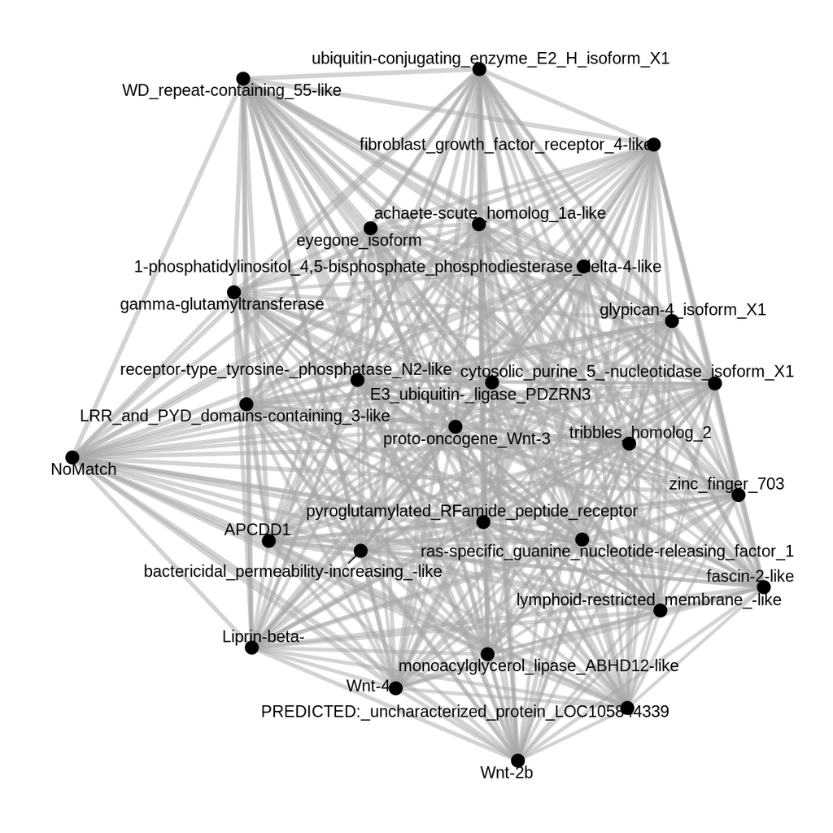

```r
ggraph(lay)+
geom_edge_link(aes(edge_width = weight), edge_colour = "grey66", alpha=0.5)+
theme(legend.position = "none")+
scale_edge_width(range = c(1, 2))+
guides(edge_width="none")+
  geom_node_text(aes(label = Description), size=5, repel=TRUE) +
geom_node_point(size=5)+
#geom_node_point(aes(color=Category), size=6)+
#geom_node_text(aes(label = Gene_name), size=5, repel=TRUE)+
  #geom_node_text(aes(filter = size >= 26, label = name),family="serif")+
  #scale_fill_manual(values = got_palette)+
  #scale_edge_width(range = c(0.2,3))+
  #scale_size(range = c(1,6))+
  theme_graph()
```

```r
#save.image(file="update_021621.RData")
```

```r
#load("update_021621.RData")
```

```r
#save.image(file="update_032322.RData")
```

```r
#load("update_032322.RData")
```